# Testosterone and cortisol positively interact to predict women’s and men’s sexual desire

Kevin A Rosenfield, Heather Self, Talia Shirazi, Rodrigo Cardenes, Justin Carre, Triana Ortiz, Khytam Dawood, & David Puts

9/01/2021

## Dual-Hormone Hypothesis Statistical programming

### 1. Cronbach’s alphas

```
##
## Cronbach's alpha for the 'SOI_R' data-set
##
## Items: 9
## Sample units: 1041
## alpha: 0.88
```

```
##
## Cronbach's alpha for the 'SDI_2' data-set
##
## Items: 14
## Sample units: 1041
## alpha: 0.906
```

### 2. Do values for session 1 hormonal or psychosexual variables differ for subjects who returned for a second session vs those who didn’t?

#### (t-test with null hypothesis of no difference; p-values below)

```
## [1] "Men's Cortisol: 0.004"
## [1] "Men's Testosterone: 0.753"
## [1] "Men's SOI-R: 0.274"
## [1] "Men's SOI Attitudes: 0.36"
## [1] "Men's SOI Behavior: 0.292"
## [1] "Men's SOI Desire: 0.499"
## [1] "Men's SDI-2: 0.618"
## [1] "Men's SDI Dyadic: 0.413"
## [1] "Men's SDI Solitary: 0.858"
```

```
## [1] "Women's Cortisol: 0.004"
## [1] "Women's Testosterone: 0.694"
## [1] "Women's SOI-R: 0.621"
## [1] "Women's SOI Attitudes: 0.538"
## [1] "Women's SOI Behavior: 0.627"
## [1] "Women's SOI Desire: 0.953"
## [1] "Women's SDI-2: 0.14"
## [1] "Women's SDI Dyadic: 0.554"
## [1] "Women's SDI Solitary: 0.05"
```

### 3. Total n of subjects and those who attended 1 or 2 sessions

```
## [1] "Women in study"
```

```
## # A tibble: 1 × 1
##       n
##   <int>
## 1   646
```

```
## [1] "Men in study"
```

```
## # A tibble: 1 × 1
##       n
##   <int>
## 1   185
```

|  | One.Session | Two.Sessions |
| --- | --- | --- |
| NC women | 246 | 102 |
| HC Women | 225 | 73 |
| Men | 142 | 43 |

| Table 1: Age statistics broken out by subgroup | Table 1: Age statistics broken out by subgroup Age (mean) | Table 1: Age statistics broken out by subgroup SD | Table 1: Age statistics broken out by subgroup n |
| --- | --- | --- | --- |
| Women (NC) | 21.07 | 6.43 | 348 |
| Women (HC) | 20.02 | 3.09 | 298 |
| Men | 21.57 | 6 | 185 |

### 4. Stats for hormone values (pg/mL)

| Table 2: Raw hormone descriptive statistics | Table 2: Raw hormone descriptive statistics | Table 2: Raw hormone descriptive statistics | Table 2: Raw hormone descriptive statistics Men n | Table 2: Raw hormone descriptive statistics Men Mean | Table 2: Raw hormone descriptive statistics Men SD | Table 2: Raw hormone descriptive statistics | Table 2: Raw hormone descriptive statistics | Table 2: Raw hormone descriptive statistics | Table 2: Raw hormone descriptive statistics Women (HC) n | Table 2: Raw hormone descriptive statistics Women (HC) Mean | Table 2: Raw hormone descriptive statistics Women (HC) SD | Table 2: Raw hormone descriptive statistics | Table 2: Raw hormone descriptive statistics | Table 2: Raw hormone descriptive statistics | Table 2: Raw hormone descriptive statistics Women (NC) n | Table 2: Raw hormone descriptive statistics Women (NC) Mean | Table 2: Raw hormone descriptive statistics Women (NC) SD |
| --- | --- | --- | --- | --- | --- | --- | --- | --- | --- | --- | --- | --- | --- | --- | --- | --- | --- |
| T |  |  | 184 | 53.31 | 21.95 |  |  |  | 298 | 28.34 | 12.72 |  |  |  | 350 | 28.4 | 6.63 |
| C |  |  | 185 | 4.66 | 1.48 |  |  |  | 292 | 5.88 | 1.77 |  |  |  | 350 | 5.57 | 3.32 |
| P |  |  | N/A | N/A | N/A |  |  |  | 296 | 33.46 | 43.12 |  |  |  | 349 | 45.93 | 54.35 |
| E |  |  | N/A | N/A | N/A |  |  |  | 297 | 3.79 | 2.01 |  |  |  | 349 | 3.62 | 2.36 |

```
## [1] "Samples were analyzed on average 382 days after being collected; range = 193 to 510 days."
```

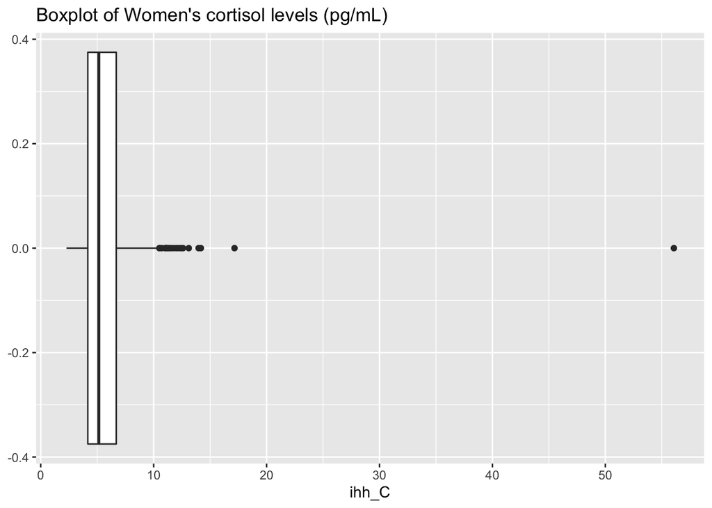

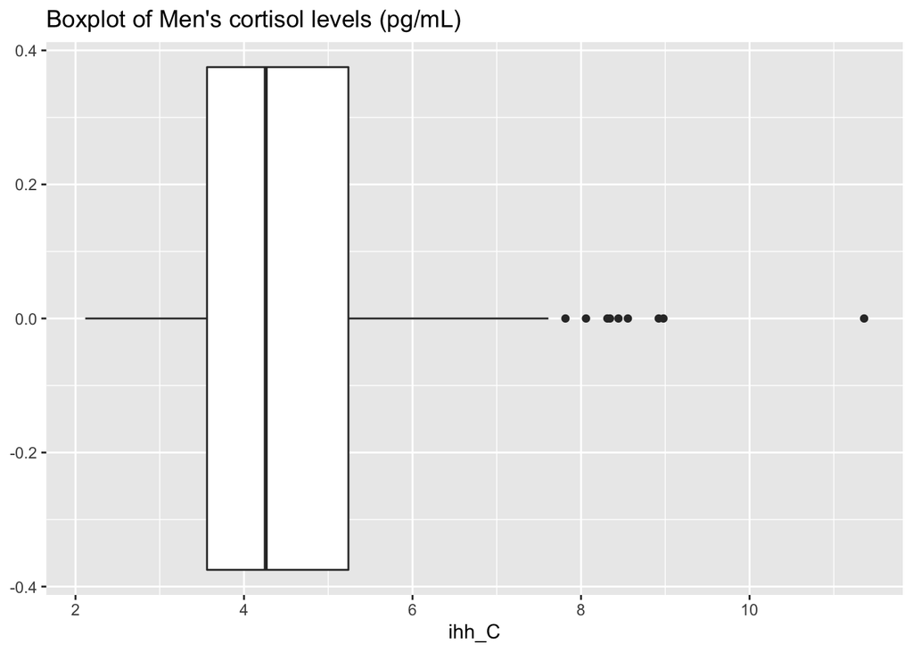

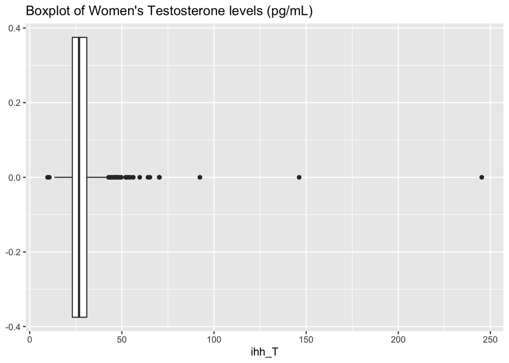

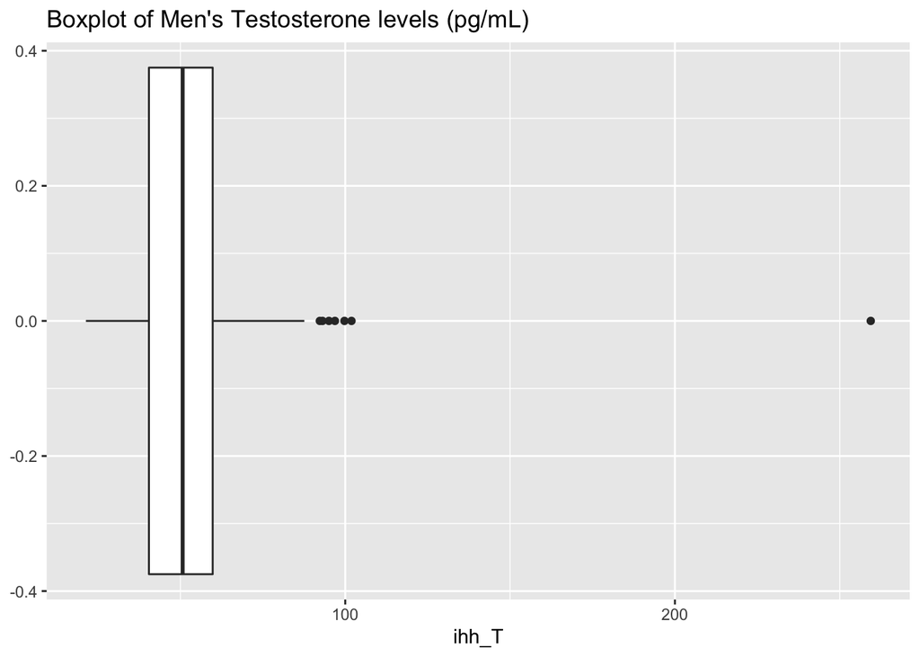

### 5. Stats for psychosexual scales and subscales

| Table 3: Responses to SOI-R, SDI-2, and subscales | Table 3: Responses to SOI-R, SDI-2, and subscales Men n | Table 3: Responses to SOI-R, SDI-2, and subscales Men Mean | Table 3: Responses to SOI-R, SDI-2, and subscales Men SD | Table 3: Responses to SOI-R, SDI-2, and subscales | Table 3: Responses to SOI-R, SDI-2, and subscales | Table 3: Responses to SOI-R, SDI-2, and subscales | Table 3: Responses to SOI-R, SDI-2, and subscales Women (NC) n | Table 3: Responses to SOI-R, SDI-2, and subscales Women (NC) Mean | Table 3: Responses to SOI-R, SDI-2, and subscales Women (NC) SD | Table 3: Responses to SOI-R, SDI-2, and subscales | Table 3: Responses to SOI-R, SDI-2, and subscales | Table 3: Responses to SOI-R, SDI-2, and subscales | Table 3: Responses to SOI-R, SDI-2, and subscales Women (HC) n | Table 3: Responses to SOI-R, SDI-2, and subscales Women (HC) Mean | Table 3: Responses to SOI-R, SDI-2, and subscales Women (HC) SD |
| --- | --- | --- | --- | --- | --- | --- | --- | --- | --- | --- | --- | --- | --- | --- | --- |
| SOI-R | 184 | 4.53 | 1.61 |  |  |  | 349 | 3.13 | 1.59 |  |  |  | 293 | 3.62 | 1.51 |
| SOI: Attitudes | 184 | 5.87 | 2.32 |  |  |  | 349 | 4.04 | 2.4 |  |  |  | 293 | 4.79 | 2.31 |
| SOI: Behavior | 184 | 2.51 | 1.62 |  |  |  | 348 | 2.03 | 1.53 |  |  |  | 293 | 2.5 | 1.49 |
| SOI: Desire | 183 | 5.2 | 2.08 |  |  |  | 348 | 3.33 | 1.82 |  |  |  | 293 | 3.57 | 1.78 |
| SDI-2 | 184 | 5.61 | 1.15 |  |  |  | 348 | 4.41 | 1.49 |  |  |  | 293 | 4.76 | 1.08 |
| SDI: Solitary | 184 | 4.85 | 1.45 |  |  |  | 348 | 3.46 | 1.72 |  |  |  | 293 | 3.51 | 1.42 |
| SDI: Dyadic | 184 | 6.37 | 1.24 |  |  |  | 348 | 5.26 | 1.67 |  |  |  | 293 | 5.85 | 1.17 |

### 6. Numbers of subjects with one or two sets of T or C and SDI or SOI samples

| Table 4: Sample sizes broken out by number of sessions | Table 4: Sample sizes broken out by number of sessions n | Table 4: Sample sizes broken out by number of sessions n (SOI) | Table 4: Sample sizes broken out by number of sessions n (SDI) |
| --- | --- | --- | --- |
| Single session |  |  |  |
| Women (NC) | 246 | 244 | 243 |
| Women (HC) | 225 | 220 | 220 |
| Men | 142 | 141 | 142 |
| 2 Sessions |  |  |  |
| Women (NC) | 102 | 102 | 102 |
| Women (HC) | 73 | 72 | 72 |
| Men | 43 | 43 | 43 |

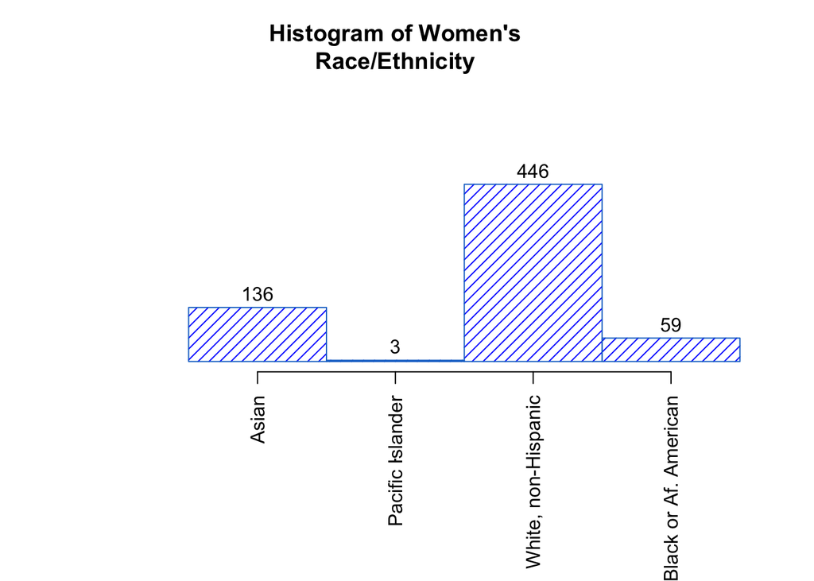

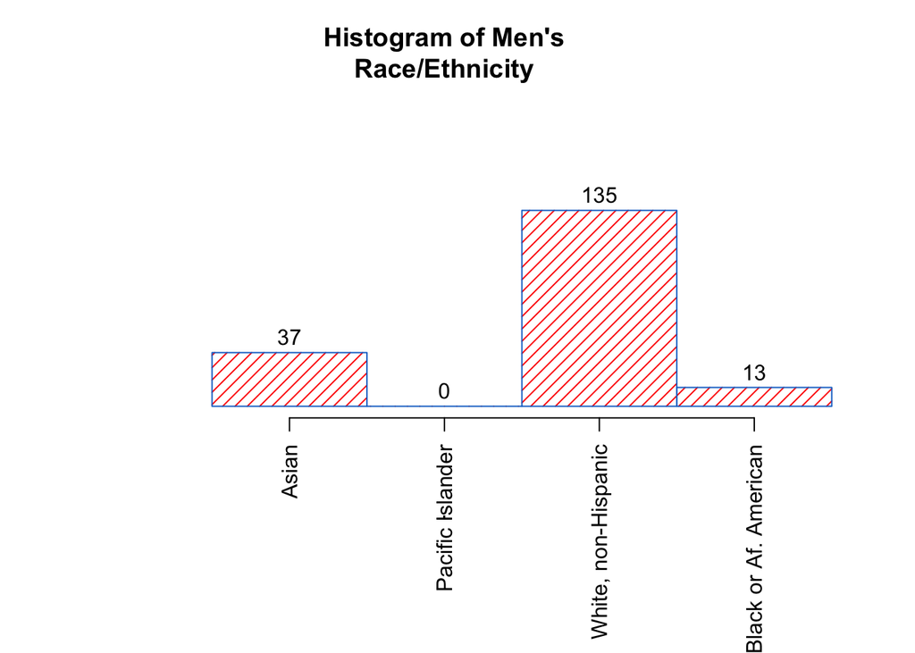

### 7. p-values for women vs. men survey and hormone values

```
## [1] "soi_mean 0"
## [1] "soi_attit 0"
## [1] "soi_behav 0.06704"
## [1] "soi_des 0"
## [1] "sdi_mean 0"
## [1] "sdi_dyad 0"
## [1] "sdi_sol 0"
## [1] "ihh_C 0"
## [1] "ihh_T 0"
```

### p-values for women on vs. women off hormonal contraception survey and hormone values

```
## [1] "soi_mean 1e-05"
## [1] "soi_attit 0"
## [1] "soi_behav 3e-05"
## [1] "soi_des 0.07336"
## [1] "sdi_mean 0.00017"
## [1] "sdi_dyad 0"
## [1] "sdi_sol 0.76727"
## [1] "ihh_C 0.02168"
## [1] "ihh_T 0.94625"
## [1] "ihh_P 6e-05"
## [1] "ihh_E 0.81344"
```

## Plots

### 8. Men - SDI and subscales, SOI and subscales, and combined

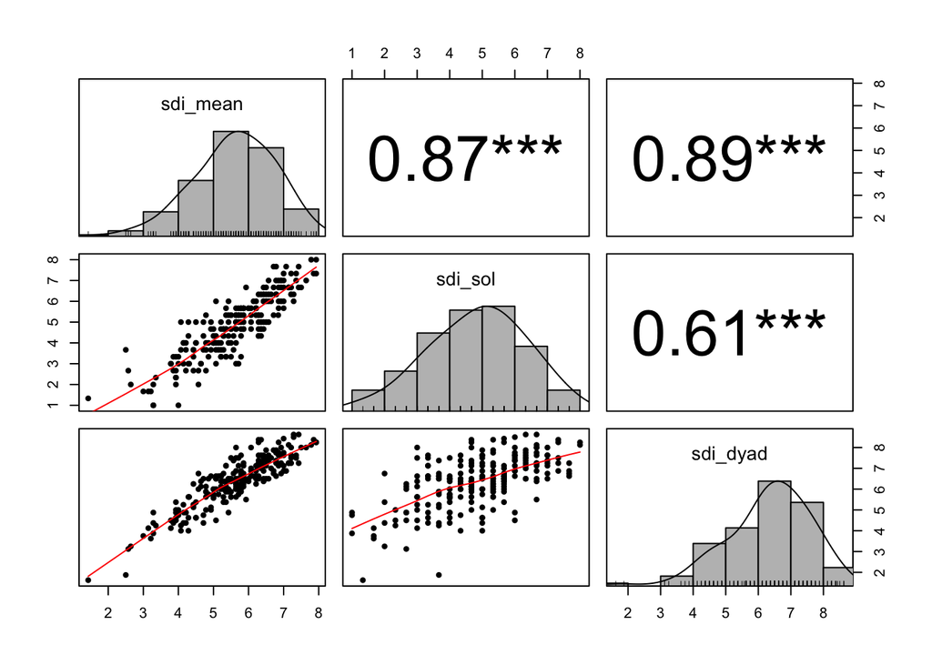

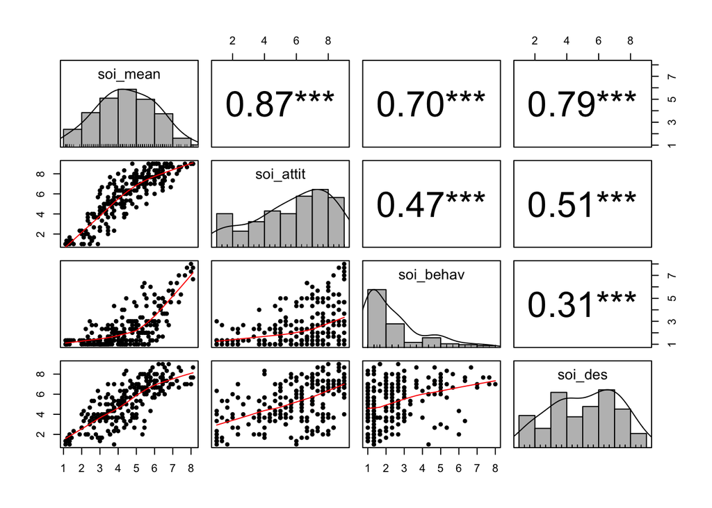

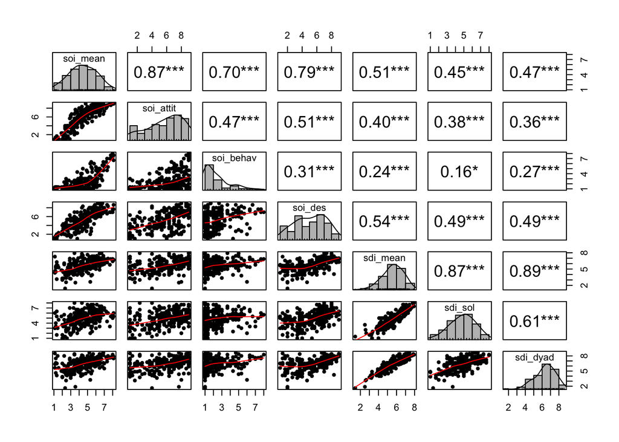

### Women - SDI and subscales, SOI and subscales, and combined

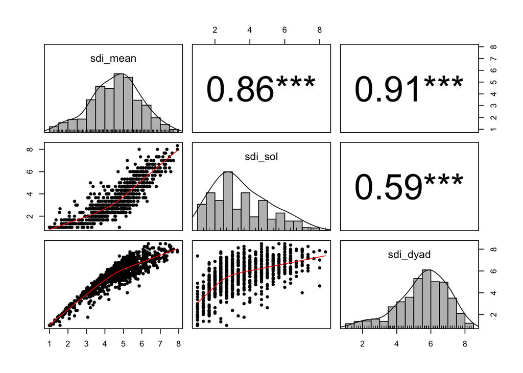

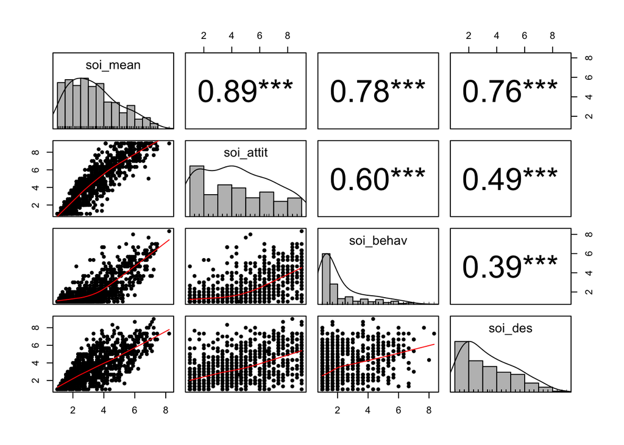

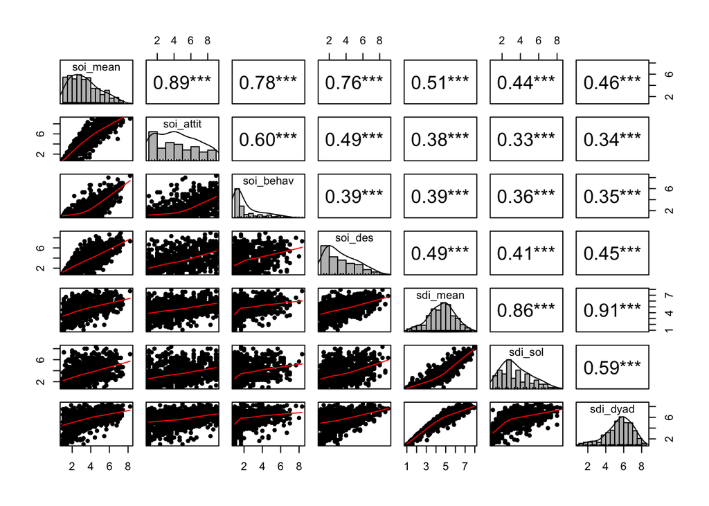

### 9. Main text figures 1 and 2 - sexual desire ~ testosterone grouped by cortisol level

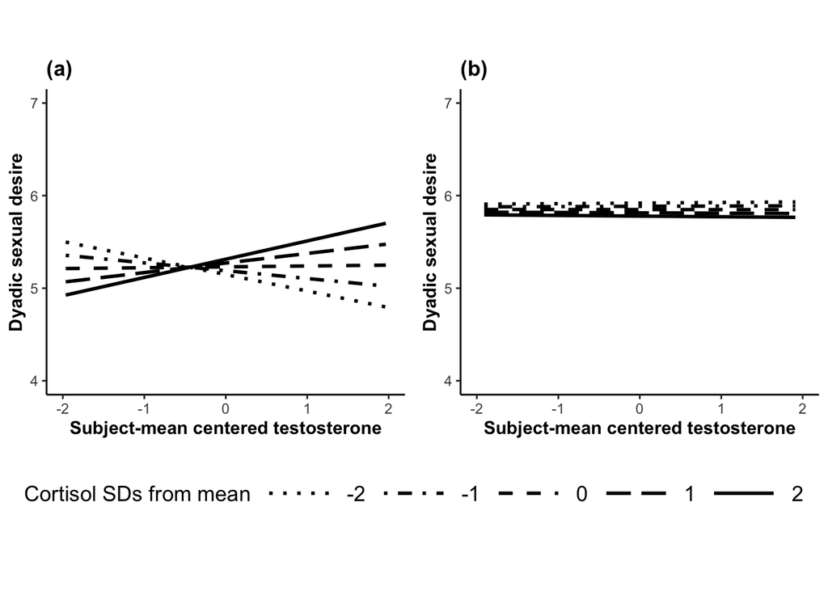

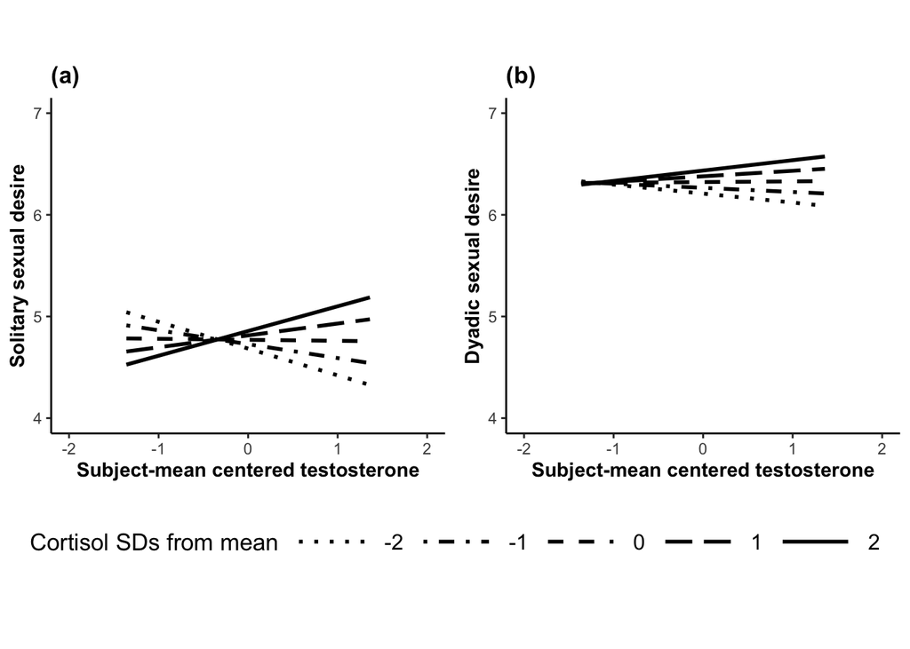

### Simple slopes data for various groups. Lines represnt subfacets of sexual desire as functions of testosterone at 5 cortisol levels

| Table 5: Dydadic Desire - Women NOT ON hormonal contracption | Table 5: Dydadic Desire - Women NOT ON hormonal contracption Cortisol | Table 5: Dydadic Desire - Women NOT ON hormonal contracption Coefficient.SE. | Table 5: Dydadic Desire - Women NOT ON hormonal contracption tValue | Table 5: Dydadic Desire - Women NOT ON hormonal contracption pValue |
| --- | --- | --- | --- | --- |
| 1 | -2 | -0.18 (0) | -3.05 | 0.001 |
| 2 | -1 | -0.08 (0) | -2.37 | 0.009 |
| 3 | 0 | 0.01 (0) | 0.4 | 0.345 |
| 4 | 1 | 0.1 (0) | 2.9 | 0.002 |
| 5 | 2 | 0.2 (0) | 3.37 | 0 |

| Table 6: Dydadic Desire - Women on hormonal contracption | Table 6: Dydadic Desire - Women on hormonal contracption Cortisol | Table 6: Dydadic Desire - Women on hormonal contracption Coefficient.SE. | Table 6: Dydadic Desire - Women on hormonal contracption tValue | Table 6: Dydadic Desire - Women on hormonal contracption pValue |
| --- | --- | --- | --- | --- |
| 1 | -2 | 0.01 (0) | 0.56 | 0.288 |
| 2 | -1 | 0 (0) | 0.33 | 0.371 |
| 3 | 0 | 0 (0) | -0.06 | 0.476 |
| 4 | 1 | 0 (0) | -0.44 | 0.33 |
| 5 | 2 | -0.01 (0) | -0.65 | 0.258 |

| Table 7: Men’s Soliatary desire | Table 7: Men’s Soliatary desire Cortisol | Table 7: Men’s Soliatary desire Coefficient.SE. | Table 7: Men’s Soliatary desire tValue | Table 7: Men’s Soliatary desire pValue |
| --- | --- | --- | --- | --- |
| 1 | -2 | -0.26 (0.01) | -3.08 | 0.001 |
| 2 | -1 | -0.14 (0) | -2.8 | 0.003 |
| 3 | 0 | -0.01 (0) | -0.37 | 0.356 |
| 4 | 1 | 0.12 (0) | 2.38 | 0.009 |
| 5 | 2 | 0.24 (0.01) | 2.84 | 0.002 |

| Table 8: Men’s Dyadic Desire | Table 8: Men’s Dyadic Desire Cortisol | Table 8: Men’s Dyadic Desire Coefficient.SE. | Table 8: Men’s Dyadic Desire tValue | Table 8: Men’s Dyadic Desire pValue |
| --- | --- | --- | --- | --- |
| 1 | -2 | -0.09 (0.01) | -1.22 | 0.112 |
| 2 | -1 | -0.04 (0) | -0.99 | 0.162 |
| 3 | 0 | 0.01 (0) | 0.29 | 0.386 |
| 4 | 1 | 0.05 (0) | 1.31 | 0.096 |
| 5 | 2 | 0.1 (0.01) | 1.4 | 0.081 |

## 10. Main and exploratory (subscale) analyses

| Table 9: SOI-R Model results: Women | Table 9: SOI-R Model results: Women SOI-R General Estimate | Table 9: SOI-R Model results: Women SOI-R General SE | Table 9: SOI-R Model results: Women SOI-R General CI | Table 9: SOI-R Model results: Women SOI-R General Beta | Table 9: SOI-R Model results: Women SOI-R General Beta CI | Table 9: SOI-R Model results: Women SOI-R General df | Table 9: SOI-R Model results: Women SOI-R General t | Table 9: SOI-R Model results: Women SOI-R General p | Table 9: SOI-R Model results: Women SOI-R | Table 9: SOI-R Model results: Women SOI-R Attitudes Estimate | Table 9: SOI-R Model results: Women SOI-R Attitudes SE | Table 9: SOI-R Model results: Women SOI-R Attitudes CI | Table 9: SOI-R Model results: Women SOI-R Attitudes Beta | Table 9: SOI-R Model results: Women SOI-R Attitudes Beta CI | Table 9: SOI-R Model results: Women SOI-R Attitudes df | Table 9: SOI-R Model results: Women SOI-R Attitudes t | Table 9: SOI-R Model results: Women SOI-R Attitudes p | Table 9: SOI-R Model results: Women SOI-R | Table 9: SOI-R Model results: Women SOI-R Behavior Estimate | Table 9: SOI-R Model results: Women SOI-R Behavior SE | Table 9: SOI-R Model results: Women SOI-R Behavior CI | Table 9: SOI-R Model results: Women SOI-R Behavior Beta | Table 9: SOI-R Model results: Women SOI-R Behavior Beta CI | Table 9: SOI-R Model results: Women SOI-R Behavior df | Table 9: SOI-R Model results: Women SOI-R Behavior t | Table 9: SOI-R Model results: Women SOI-R Behavior p | Table 9: SOI-R Model results: Women SOI-R | Table 9: SOI-R Model results: Women SOI-R Desire Estimate | Table 9: SOI-R Model results: Women SOI-R Desire SE | … |
| --- | --- | --- | --- | --- | --- | --- | --- | --- | --- | --- | --- | --- | --- | --- | --- | --- | --- | --- | --- | --- | --- | --- | --- | --- | --- | --- | --- | --- | --- | --- |
| Women |  |  |  |  |  |  |  |  |  |  |  |  |  |  |  |  |  |  |  |  |  |  |  |  |  |  |  |  |  | … |
| Intercept | 4.172 | 1.027 | [2.16; 6.18] | -1.234 | [-2.57; 0.1] | 635.094 | 4.064 | 0 |  | 5.923 | 1.56 | [2.87; 8.98] | -1.144 | [-2.47; 0.18] | 638.254 | 3.796 | 0 |  | 2.203 | 1 | [0.24; 4.16] | -0.636 | [-1.99; 0.72] | 632.809 | 2.204 | 0.028 |  | 4.544 | 1.193 | … |
| C (within) | 0.044 | 0.038 | [-0.03; 0.12] | 0.018 | [-0.01; 0.05] | 160.498 | 1.142 | 0.255 |  | 0.095 | 0.077 | [-0.06; 0.25] | 0.026 | [-0.02; 0.07] | 162.044 | 1.237 | 0.218 |  | 0.022 | 0.039 | [-0.05; 0.1] | 0.009 | [-0.02; 0.04] | 159.005 | 0.547 | 0.585 |  | 0.015 | 0.073 | … |
| T (within) | 0.009 | 0.006 | [0; 0.02] | 0.034 | [-0.01; 0.08] | 160.498 | 1.41 | 0.161 |  | -0.002 | 0.012 | [-0.03; 0.02] | -0.004 | [-0.06; 0.06] | 162.044 | -0.13 | 0.897 |  | 0.006 | 0.006 | [-0.01; 0.02] | 0.023 | [-0.03; 0.07] | 159.005 | 0.892 | 0.374 |  | 0.021 | 0.012 | … |
| C (between) | -0.289 | 0.184 | [-0.65; 0.07] | -0.472 | [-1.06; 0.12] | 637.505 | -1.571 | 0.117 |  | -0.397 | 0.28 | [-0.95; 0.15] | -0.422 | [-1.01; 0.16] | 642.615 | -1.417 | 0.157 |  | -0.128 | 0.179 | [-0.48; 0.22] | -0.218 | [-0.82; 0.38] | 635.604 | -0.715 | 0.475 |  | -0.356 | 0.215 | … |
| T (between) | -0.04 | 0.038 | [-0.11; 0.03] | -0.253 | [-0.72; 0.21] | 634.418 | -1.061 | 0.289 |  | -0.073 | 0.057 | [-0.18; 0.04] | -0.301 | [-0.76; 0.16] | 637.027 | -1.277 | 0.202 |  | -0.007 | 0.037 | [-0.08; 0.07] | -0.048 | [-0.52; 0.43] | 632.015 | -0.198 | 0.843 |  | -0.045 | 0.044 | … |
| HC | -0.283 | 1.376 | [-2.98; 2.41] | -0.179 | [-1.89; 1.53] | 634.429 | -0.206 | 0.837 |  | -1.414 | 2.091 | [-5.51; 2.68] | -0.582 | [-2.27; 1.11] | 637.04 | -0.676 | 0.499 |  | 1.049 | 1.338 | [-1.57; 3.67] | 0.692 | [-1.04; 2.42] | 632.108 | 0.784 | 0.433 |  | -0.506 | 1.599 | … |
| T x C (within) | 0.024 | 0.035 | [-0.04; 0.09] | 0.015 | [-0.03; 0.06] | 596.244 | 0.672 | 0.502 |  | 0.043 | 0.053 | [-0.06; 0.15] | 0.018 | [-0.03; 0.06] | 569.397 | 0.81 | 0.418 |  | 0.015 | 0.034 | [-0.05; 0.08] | 0.01 | [-0.04; 0.06] | 588.851 | 0.424 | 0.672 |  | 0.014 | 0.04 | … |
| T x C (between) | 0.011 | 0.007 | [0; 0.02] | 0.007 | [0; 0.01] | 636.776 | 1.597 | 0.111 |  | 0.015 | 0.01 | [0; 0.03] | 0.006 | [0; 0.01] | 641.29 | 1.475 | 0.141 |  | 0.005 | 0.006 | [-0.01; 0.02] | 0.003 | [0; 0.01] | 634.761 | 0.715 | 0.475 |  | 0.013 | 0.008 | … |
| C (within) x HC | -0.019 | 0.049 | [-0.12; 0.08] | -0.012 | [-0.07; 0.05] | 160.498 | -0.399 | 0.69 |  | -0.127 | 0.098 | [-0.32; 0.07] | -0.052 | [-0.13; 0.03] | 162.044 | -1.291 | 0.198 |  | 0.027 | 0.05 | [-0.07; 0.12] | 0.018 | [-0.05; 0.08] | 159.005 | 0.536 | 0.593 |  | 0.041 | 0.093 | … |
| T (within) x HC | -0.016 | 0.007 | [-0.03; 0] | -0.01 | [-0.02; 0] | 160.498 | -2.448 | 0.015 |  | -0.003 | 0.014 | [-0.03; 0.02] | -0.001 | [-0.01; 0.01] | 162.044 | -0.226 | 0.821 |  | -0.011 | 0.007 | [-0.02; 0] | -0.007 | [-0.02; 0] | 159.005 | -1.603 | 0.111 |  | -0.035 | 0.013 | … |
| C (between) x HC | 0.235 | 0.23 | [-0.22; 0.69] | 0.149 | [-0.14; 0.44] | 635.96 | 1.021 | 0.308 |  | 0.398 | 0.35 | [-0.29; 1.08] | 0.164 | [-0.12; 0.45] | 639.815 | 1.135 | 0.257 |  | 0.011 | 0.224 | [-0.43; 0.45] | 0.007 | [-0.28; 0.3] | 633.873 | 0.048 | 0.962 |  | 0.289 | 0.268 | … |
| T (between) x HC | 0.023 | 0.049 | [-0.07; 0.12] | 0.015 | [-0.05; 0.08] | 633.892 | 0.476 | 0.634 |  | 0.067 | 0.074 | [-0.08; 0.21] | 0.028 | [-0.03; 0.09] | 636.07 | 0.913 | 0.362 |  | -0.02 | 0.047 | [-0.11; 0.07] | -0.013 | [-0.07; 0.05] | 631.476 | -0.421 | 0.674 |  | 0.023 | 0.056 | … |
| T x C (within) x HC | -0.025 | 0.037 | [-0.1; 0.05] | -0.016 | [-0.06; 0.03] | 598.664 | -0.664 | 0.507 |  | -0.044 | 0.056 | [-0.15; 0.07] | -0.018 | [-0.06; 0.03] | 573.744 | -0.792 | 0.429 |  | -0.016 | 0.036 | [-0.09; 0.05] | -0.01 | [-0.06; 0.04] | 591.602 | -0.431 | 0.667 |  | -0.016 | 0.042 | … |
| T x C (between) x HC | -0.007 | 0.008 | [-0.02; 0.01] | -0.005 | [-0.01; 0] | 635.391 | -0.943 | 0.346 |  | -0.012 | 0.012 | [-0.04; 0.01] | -0.005 | [-0.01; 0] | 638.786 | -1.016 | 0.31 |  | 0 | 0.008 | [-0.02; 0.02] | 0 | [-0.01; 0.01] | 633.214 | -0.062 | 0.951 |  | -0.009 | 0.009 | … |

| Table 10: SDI-2 Model results: Women | Table 10: SDI-2 Model results: Women SDI-2 General Estimate | Table 10: SDI-2 Model results: Women SDI-2 General SE | Table 10: SDI-2 Model results: Women SDI-2 General CI | Table 10: SDI-2 Model results: Women SDI-2 General Beta | Table 10: SDI-2 Model results: Women SDI-2 General Beta CI | Table 10: SDI-2 Model results: Women SDI-2 General df | Table 10: SDI-2 Model results: Women SDI-2 General t | Table 10: SDI-2 Model results: Women SDI-2 General p | Table 10: SDI-2 Model results: Women SDI-2 | Table 10: SDI-2 Model results: Women SDI-2 Solitary Estimate | Table 10: SDI-2 Model results: Women SDI-2 Solitary SE | Table 10: SDI-2 Model results: Women SDI-2 Solitary CI | Table 10: SDI-2 Model results: Women SDI-2 Solitary Beta | Table 10: SDI-2 Model results: Women SDI-2 Solitary Beta CI | Table 10: SDI-2 Model results: Women SDI-2 Solitary df | Table 10: SDI-2 Model results: Women SDI-2 Solitary t | Table 10: SDI-2 Model results: Women SDI-2 Solitary p | Table 10: SDI-2 Model results: Women SDI-2 | Table 10: SDI-2 Model results: Women SDI-2 Dyadic Estimate | Table 10: SDI-2 Model results: Women SDI-2 Dyadic SE | Table 10: SDI-2 Model results: Women SDI-2 Dyadic CI | Table 10: SDI-2 Model results: Women SDI-2 Dyadic Beta | Table 10: SDI-2 Model results: Women SDI-2 Dyadic Beta CI | Table 10: SDI-2 Model results: Women SDI-2 Dyadic df | Table 10: SDI-2 Model results: Women SDI-2 Dyadic t | Table 10: SDI-2 Model results: Women SDI-2 Dyadic p |
| --- | --- | --- | --- | --- | --- | --- | --- | --- | --- | --- | --- | --- | --- | --- | --- | --- | --- | --- | --- | --- | --- | --- | --- | --- | --- | --- |
| Women |  |  |  |  |  |  |  |  |  |  |  |  |  |  |  |  |  |  |  |  |  |  |  |  |  |  |
| Intercept | 4.27 | 0.866 | [2.57; 5.97] | -0.236 | [-1.57; 1.09] | 636.396 | 4.933 | 0 |  | 3.314 | 1.051 | [1.25; 5.37] | 0.014 | [-1.32; 1.35] | 640.106 | 3.154 | 0.002 |  | 5.041 | 0.952 | [3.18; 6.91] | -0.357 | [-1.67; 0.96] | 633.399 | 5.297 | 0 |
| C (within) | 0.003 | 0.052 | [-0.1; 0.1] | 0.002 | [-0.05; 0.05] | 159.688 | 0.062 | 0.95 |  | 0.071 | 0.059 | [-0.04; 0.19] | 0.029 | [-0.02; 0.08] | 164.037 | 1.208 | 0.229 |  | 0.041 | 0.07 | [-0.1; 0.18] | 0.018 | [-0.04; 0.08] | 155.174 | 0.592 | 0.555 |
| T (within) | 0.012 | 0.008 | [0; 0.03] | 0.054 | [-0.02; 0.13] | 159.688 | 1.411 | 0.16 |  | 0.008 | 0.009 | [-0.01; 0.03] | 0.03 | [-0.04; 0.1] | 164.037 | 0.843 | 0.401 |  | 0.009 | 0.011 | [-0.01; 0.03] | 0.039 | [-0.05; 0.13] | 155.174 | 0.835 | 0.405 |
| C (between) | -0.06 | 0.156 | [-0.37; 0.25] | -0.115 | [-0.7; 0.47] | 643.083 | -0.383 | 0.702 |  | -0.024 | 0.189 | [-0.39; 0.35] | -0.039 | [-0.63; 0.55] | 645.86 | -0.129 | 0.897 |  | -0.075 | 0.171 | [-0.41; 0.26] | -0.129 | [-0.71; 0.45] | 644.38 | -0.437 | 0.662 |
| T (between) | 0.012 | 0.032 | [-0.05; 0.07] | 0.088 | [-0.37; 0.55] | 634.532 | 0.373 | 0.709 |  | 0.013 | 0.038 | [-0.06; 0.09] | 0.08 | [-0.39; 0.55] | 638.503 | 0.334 | 0.738 |  | 0.013 | 0.035 | [-0.06; 0.08] | 0.088 | [-0.37; 0.54] | 630.316 | 0.379 | 0.705 |
| HC | 1.919 | 1.16 | [-0.35; 4.19] | 1.43 | [-0.26; 3.12] | 634.542 | 1.655 | 0.099 |  | 1.993 | 1.408 | [-0.77; 4.75] | 1.23 | [-0.47; 2.93] | 638.515 | 1.415 | 0.157 |  | 2.35 | 1.274 | [-0.15; 4.85] | 1.571 | [-0.1; 3.24] | 630.301 | 1.844 | 0.066 |
| T x C (within) | 0.074 | 0.029 | [0.02; 0.13] | 0.055 | [0.01; 0.1] | 534.465 | 2.555 | 0.011 |  | 0.057 | 0.035 | [-0.01; 0.13] | 0.035 | [-0.01; 0.08] | 551.095 | 1.612 | 0.107 |  | 0.091 | 0.031 | [0.03; 0.15] | 0.061 | [0.02; 0.1] | 476.465 | 2.902 | 0.004 |
| T x C (between) | 0.001 | 0.006 | [-0.01; 0.01] | 0.001 | [-0.01; 0.01] | 641.054 | 0.132 | 0.895 |  | -0.001 | 0.007 | [-0.01; 0.01] | 0 | [-0.01; 0.01] | 644.117 | -0.082 | 0.935 |  | 0.001 | 0.006 | [-0.01; 0.01] | 0.001 | [-0.01; 0.01] | 641.026 | 0.237 | 0.813 |
| C (within) x HC | -0.034 | 0.066 | [-0.16; 0.1] | -0.025 | [-0.12; 0.07] | 159.689 | -0.509 | 0.612 |  | -0.083 | 0.076 | [-0.23; 0.07] | -0.051 | [-0.14; 0.04] | 164.037 | -1.098 | 0.274 |  | -0.077 | 0.089 | [-0.25; 0.1] | -0.051 | [-0.17; 0.07] | 155.174 | -0.857 | 0.393 |
| T (within) x HC | -0.012 | 0.009 | [-0.03; 0.01] | -0.009 | [-0.02; 0] | 159.689 | -1.371 | 0.172 |  | -0.008 | 0.01 | [-0.03; 0.01] | -0.005 | [-0.02; 0.01] | 164.037 | -0.766 | 0.445 |  | -0.01 | 0.012 | [-0.03; 0.01] | -0.007 | [-0.02; 0.01] | 155.174 | -0.797 | 0.427 |
| C (between) x HC | -0.115 | 0.194 | [-0.5; 0.27] | -0.086 | [-0.37; 0.2] | 638.803 | -0.59 | 0.555 |  | -0.218 | 0.236 | [-0.68; 0.24] | -0.135 | [-0.42; 0.15] | 642.18 | -0.925 | 0.355 |  | -0.108 | 0.214 | [-0.53; 0.31] | -0.072 | [-0.35; 0.21] | 637.332 | -0.506 | 0.613 |
| T (between) x HC | -0.052 | 0.041 | [-0.13; 0.03] | -0.038 | [-0.1; 0.02] | 633.076 | -1.262 | 0.207 |  | -0.067 | 0.05 | [-0.16; 0.03] | -0.042 | [-0.1; 0.02] | 637.251 | -1.359 | 0.175 |  | -0.056 | 0.045 | [-0.14; 0.03] | -0.037 | [-0.1; 0.02] | 627.911 | -1.24 | 0.215 |
| T x C (within) x HC | -0.081 | 0.031 | [-0.14; -0.02] | -0.06 | [-0.11; -0.01] | 540.923 | -2.639 | 0.009 |  | -0.072 | 0.037 | [-0.14; 0] | -0.045 | [-0.09; 0] | 556.75 | -1.933 | 0.054 |  | -0.095 | 0.033 | [-0.16; -0.03] | -0.063 | [-0.11; -0.02] | 486.265 | -2.868 | 0.004 |
| T x C (between) x HC | 0.004 | 0.007 | [-0.01; 0.02] | 0.003 | [-0.01; 0.01] | 637.237 | 0.525 | 0.6 |  | 0.007 | 0.008 | [-0.01; 0.02] | 0.005 | [0; 0.01] | 640.831 | 0.923 | 0.356 |  | 0.003 | 0.007 | [-0.01; 0.02] | 0.002 | [-0.01; 0.01] | 634.765 | 0.386 | 0.699 |

| Table 11: SOI-R Model results: Men | Table 11: SOI-R Model results: Men SOI-R General Estimate | Table 11: SOI-R Model results: Men SOI-R General SE | Table 11: SOI-R Model results: Men SOI-R General CI | Table 11: SOI-R Model results: Men SOI-R General Beta | Table 11: SOI-R Model results: Men SOI-R General Beta CI | Table 11: SOI-R Model results: Men SOI-R General df | Table 11: SOI-R Model results: Men SOI-R General t | Table 11: SOI-R Model results: Men SOI-R General p | Table 11: SOI-R Model results: Men SOI-R | Table 11: SOI-R Model results: Men SOI-R Attitudes Estimate | Table 11: SOI-R Model results: Men SOI-R Attitudes SE | Table 11: SOI-R Model results: Men SOI-R Attitudes CI | Table 11: SOI-R Model results: Men SOI-R Attitudes Beta | Table 11: SOI-R Model results: Men SOI-R Attitudes Beta CI | Table 11: SOI-R Model results: Men SOI-R Attitudes df | Table 11: SOI-R Model results: Men SOI-R Attitudes t | Table 11: SOI-R Model results: Men SOI-R Attitudes p | Table 11: SOI-R Model results: Men SOI-R | Table 11: SOI-R Model results: Men SOI-R Behavior Estimate | Table 11: SOI-R Model results: Men SOI-R Behavior SE | Table 11: SOI-R Model results: Men SOI-R Behavior CI | Table 11: SOI-R Model results: Men SOI-R Behavior Beta | Table 11: SOI-R Model results: Men SOI-R Behavior Beta CI | Table 11: SOI-R Model results: Men SOI-R Behavior df | Table 11: SOI-R Model results: Men SOI-R Behavior t | Table 11: SOI-R Model results: Men SOI-R Behavior p | Table 11: SOI-R Model results: Men SOI-R | Table 11: SOI-R Model results: Men SOI-R Desire Estimate | Table 11: SOI-R Model results: Men SOI-R Desire SE | … |
| --- | --- | --- | --- | --- | --- | --- | --- | --- | --- | --- | --- | --- | --- | --- | --- | --- | --- | --- | --- | --- | --- | --- | --- | --- | --- | --- | --- | --- | --- | --- |
| Men |  |  |  |  |  |  |  |  |  |  |  |  |  |  |  |  |  |  |  |  |  |  |  |  |  |  |  |  |  | … |
| Intercept | 3.254 | 1.248 | [0.81; 5.7] | 0.732 | [-0.75; 2.21] | 179.051 | 2.607 | 0.01 |  | 3.601 | 1.79 | [0.09; 7.11] | 0.95 | [-0.5; 2.4] | 179.55 | 2.012 | 0.046 |  | 2.894 | 1.272 | [0.4; 5.39] | -0.031 | [-1.52; 1.46] | 179.513 | 2.275 | 0.024 |  | 3.169 | 1.606 | … |
| C (within) | 0.011 | 0.1 | [-0.18; 0.21] | 0.003 | [-0.04; 0.05] | 38.706 | 0.115 | 0.909 |  | -0.11 | 0.175 | [-0.45; 0.23] | -0.017 | [-0.07; 0.03] | 39.119 | -0.63 | 0.532 |  | 0.044 | 0.114 | [-0.18; 0.27] | 0.01 | [-0.04; 0.06] | 39.116 | 0.385 | 0.702 |  | 0.09 | 0.178 | … |
| T (within) | 0.002 | 0.009 | [-0.02; 0.02] | 0.005 | [-0.04; 0.05] | 38.705 | 0.231 | 0.819 |  | -0.004 | 0.016 | [-0.04; 0.03] | -0.007 | [-0.06; 0.04] | 39.117 | -0.28 | 0.781 |  | -0.001 | 0.01 | [-0.02; 0.02] | -0.002 | [-0.05; 0.05] | 39.113 | -0.064 | 0.95 |  | 0.02 | 0.016 | … |
| C (between) | 0.197 | 0.257 | [-0.31; 0.7] | 0.173 | [-0.27; 0.62] | 179.382 | 0.766 | 0.445 |  | 0.329 | 0.369 | [-0.39; 1.05] | 0.198 | [-0.24; 0.64] | 180.059 | 0.891 | 0.374 |  | -0.078 | 0.262 | [-0.59; 0.44] | -0.068 | [-0.52; 0.38] | 179.933 | -0.297 | 0.767 |  | 0.358 | 0.332 | … |
| T (between) | 0.028 | 0.024 | [-0.02; 0.08] | 0.365 | [-0.25; 0.98] | 178.95 | 1.165 | 0.246 |  | 0.055 | 0.035 | [-0.01; 0.12] | 0.491 | [-0.11; 1.09] | 179.392 | 1.596 | 0.112 |  | -0.002 | 0.025 | [-0.05; 0.05] | -0.03 | [-0.65; 0.59] | 179.383 | -0.095 | 0.924 |  | 0.034 | 0.031 | … |
| T x C (within) | 0.061 | 0.062 | [-0.06; 0.18] | 0.038 | [-0.04; 0.11] | 166.181 | 0.996 | 0.321 |  | 0.111 | 0.088 | [-0.06; 0.28] | 0.047 | [-0.03; 0.12] | 160.084 | 1.266 | 0.207 |  | -0.021 | 0.063 | [-0.14; 0.1] | -0.013 | [-0.09; 0.06] | 163.259 | -0.339 | 0.735 |  | 0.099 | 0.078 | … |
| T x C (between) | -0.005 | 0.005 | [-0.01; 0] | -0.003 | [-0.01; 0] | 178.991 | -0.949 | 0.344 |  | -0.009 | 0.007 | [-0.02; 0] | -0.004 | [-0.01; 0] | 179.456 | -1.273 | 0.205 |  | 0 | 0.005 | [-0.01; 0.01] | 0 | [-0.01; 0.01] | 179.435 | 0.089 | 0.929 |  | -0.006 | 0.006 | … |

| Table 12: SDI-2 Model results: Men | Table 12: SDI-2 Model results: Men SDI-2 General Estimate | Table 12: SDI-2 Model results: Men SDI-2 General SE | Table 12: SDI-2 Model results: Men SDI-2 General CI | Table 12: SDI-2 Model results: Men SDI-2 General Beta | Table 12: SDI-2 Model results: Men SDI-2 General Beta CI | Table 12: SDI-2 Model results: Men SDI-2 General df | Table 12: SDI-2 Model results: Men SDI-2 General t | Table 12: SDI-2 Model results: Men SDI-2 General p | Table 12: SDI-2 Model results: Men SDI-2 | Table 12: SDI-2 Model results: Men SDI-2 Solitary Estimate | Table 12: SDI-2 Model results: Men SDI-2 Solitary SE | Table 12: SDI-2 Model results: Men SDI-2 Solitary CI | Table 12: SDI-2 Model results: Men SDI-2 Solitary Beta | Table 12: SDI-2 Model results: Men SDI-2 Solitary Beta CI | Table 12: SDI-2 Model results: Men SDI-2 Solitary df | Table 12: SDI-2 Model results: Men SDI-2 Solitary t | Table 12: SDI-2 Model results: Men SDI-2 Solitary p | Table 12: SDI-2 Model results: Men SDI-2 | Table 12: SDI-2 Model results: Men SDI-2 Dyadic Estimate | Table 12: SDI-2 Model results: Men SDI-2 Dyadic SE | Table 12: SDI-2 Model results: Men SDI-2 Dyadic CI | Table 12: SDI-2 Model results: Men SDI-2 Dyadic Beta | Table 12: SDI-2 Model results: Men SDI-2 Dyadic Beta CI | Table 12: SDI-2 Model results: Men SDI-2 Dyadic df | Table 12: SDI-2 Model results: Men SDI-2 Dyadic t | Table 12: SDI-2 Model results: Men SDI-2 Dyadic p |
| --- | --- | --- | --- | --- | --- | --- | --- | --- | --- | --- | --- | --- | --- | --- | --- | --- | --- | --- | --- | --- | --- | --- | --- | --- | --- | --- |
| Men |  |  |  |  |  |  |  |  |  |  |  |  |  |  |  |  |  |  |  |  |  |  |  |  |  |  |
| Intercept | 6.894 | 0.873 | [5.18; 8.61] | -0.883 | [-2.33; 0.57] | 180.624 | 7.896 | 0 |  | 5.63 | 1.111 | [3.45; 7.81] | -0.476 | [-1.9; 0.95] | 182.05 | 5.066 | 0 |  | 7.649 | 0.952 | [5.78; 9.51] | -0.896 | [-2.37; 0.58] | 179.738 | 8.037 | 0 |
| C (within) | 0.014 | 0.115 | [-0.21; 0.24] | 0.004 | [-0.06; 0.07] | 38.533 | 0.122 | 0.903 |  | 0.046 | 0.147 | [-0.24; 0.33] | 0.011 | [-0.06; 0.08] | 40.055 | 0.31 | 0.758 |  | 0.061 | 0.124 | [-0.18; 0.3] | 0.017 | [-0.05; 0.09] | 37.627 | 0.493 | 0.625 |
| T (within) | 0 | 0.01 | [-0.02; 0.02] | 0 | [-0.07; 0.07] | 38.753 | 0.011 | 0.991 |  | -0.009 | 0.013 | [-0.03; 0.02] | -0.024 | [-0.09; 0.04] | 40.285 | -0.675 | 0.504 |  | 0.006 | 0.011 | [-0.02; 0.03] | 0.02 | [-0.05; 0.09] | 37.84 | 0.552 | 0.584 |
| C (between) | -0.333 | 0.18 | [-0.69; 0.02] | -0.411 | [-0.85; 0.02] | 181.609 | -1.849 | 0.066 |  | -0.253 | 0.229 | [-0.7; 0.2] | -0.241 | [-0.67; 0.19] | 183.024 | -1.102 | 0.272 |  | -0.342 | 0.196 | [-0.73; 0.04] | -0.393 | [-0.83; 0.05] | 180.723 | -1.743 | 0.083 |
| T (between) | -0.015 | 0.017 | [-0.05; 0.02] | -0.269 | [-0.87; 0.33] | 180.475 | -0.878 | 0.381 |  | -0.006 | 0.022 | [-0.05; 0.04] | -0.088 | [-0.68; 0.5] | 181.902 | -0.292 | 0.771 |  | -0.016 | 0.018 | [-0.05; 0.02] | -0.267 | [-0.88; 0.34] | 179.589 | -0.859 | 0.391 |
| T x C (within) | 0.062 | 0.042 | [-0.02; 0.14] | 0.053 | [-0.02; 0.12] | 145.158 | 1.469 | 0.144 |  | 0.112 | 0.053 | [0.01; 0.22] | 0.075 | [0; 0.15] | 146.798 | 2.106 | 0.037 |  | 0.033 | 0.046 | [-0.06; 0.12] | 0.027 | [-0.05; 0.1] | 144.342 | 0.724 | 0.47 |
| T x C (between) | 0.004 | 0.003 | [0; 0.01] | 0.004 | [0; 0.01] | 180.579 | 1.198 | 0.233 |  | 0.003 | 0.004 | [0; 0.01] | 0.002 | [0; 0.01] | 182.005 | 0.632 | 0.528 |  | 0.005 | 0.004 | [0; 0.01] | 0.004 | [0; 0.01] | 179.693 | 1.213 | 0.227 |

## 11. Robustness analyses and false discovery rate corrections

#### seperate models for hormonal contraception and no HC

| Table 13: SOI-R Model results | Table 13: SOI-R Model results SOI-R General Estimate | Table 13: SOI-R Model results SOI-R General SE | Table 13: SOI-R Model results SOI-R General CI | Table 13: SOI-R Model results SOI-R General Beta | Table 13: SOI-R Model results SOI-R General Beta CI | Table 13: SOI-R Model results SOI-R General df | Table 13: SOI-R Model results SOI-R General t | Table 13: SOI-R Model results SOI-R General p | Table 13: SOI-R Model results SOI-R | Table 13: SOI-R Model results SOI-R Attitudes Estimate | Table 13: SOI-R Model results SOI-R Attitudes SE | Table 13: SOI-R Model results SOI-R Attitudes CI | Table 13: SOI-R Model results SOI-R Attitudes Beta | Table 13: SOI-R Model results SOI-R Attitudes Beta CI | Table 13: SOI-R Model results SOI-R Attitudes df | Table 13: SOI-R Model results SOI-R Attitudes t | Table 13: SOI-R Model results SOI-R Attitudes p | Table 13: SOI-R Model results SOI-R | Table 13: SOI-R Model results SOI-R Behavior Estimate | Table 13: SOI-R Model results SOI-R Behavior SE | Table 13: SOI-R Model results SOI-R Behavior CI | Table 13: SOI-R Model results SOI-R Behavior Beta | Table 13: SOI-R Model results SOI-R Behavior Beta CI | Table 13: SOI-R Model results SOI-R Behavior df | Table 13: SOI-R Model results SOI-R Behavior t | Table 13: SOI-R Model results SOI-R Behavior p | Table 13: SOI-R Model results SOI-R | Table 13: SOI-R Model results SOI-R Desire Estimate | Table 13: SOI-R Model results SOI-R Desire SE | … |
| --- | --- | --- | --- | --- | --- | --- | --- | --- | --- | --- | --- | --- | --- | --- | --- | --- | --- | --- | --- | --- | --- | --- | --- | --- | --- | --- | --- | --- | --- | --- |
| Men |  |  |  |  |  |  |  |  |  |  |  |  |  |  |  |  |  |  |  |  |  |  |  |  |  |  |  |  |  | … |
| Intercept | 3.254 | 1.248 | [0.81; 5.7] | 0.732 | [-0.75; 2.21] | 179.051 | 2.607 | 0.01 |  | 3.601 | 1.79 | [0.09; 7.11] | 0.95 | [-0.5; 2.4] | 179.55 | 2.012 | 0.046 |  | 2.894 | 1.272 | [0.4; 5.39] | -0.031 | [-1.52; 1.46] | 179.513 | 2.275 | 0.024 |  | 3.169 | 1.606 | … |
| C (within) | 0.011 | 0.1 | [-0.18; 0.21] | 0.003 | [-0.04; 0.05] | 38.706 | 0.115 | 0.909 |  | -0.11 | 0.175 | [-0.45; 0.23] | -0.017 | [-0.07; 0.03] | 39.119 | -0.63 | 0.532 |  | 0.044 | 0.114 | [-0.18; 0.27] | 0.01 | [-0.04; 0.06] | 39.116 | 0.385 | 0.702 |  | 0.09 | 0.178 | … |
| T (within) | 0.002 | 0.009 | [-0.02; 0.02] | 0.005 | [-0.04; 0.05] | 38.705 | 0.231 | 0.819 |  | -0.004 | 0.016 | [-0.04; 0.03] | -0.007 | [-0.06; 0.04] | 39.117 | -0.28 | 0.781 |  | -0.001 | 0.01 | [-0.02; 0.02] | -0.002 | [-0.05; 0.05] | 39.113 | -0.064 | 0.95 |  | 0.02 | 0.016 | … |
| C (between) | 0.197 | 0.257 | [-0.31; 0.7] | 0.173 | [-0.27; 0.62] | 179.382 | 0.766 | 0.445 |  | 0.329 | 0.369 | [-0.39; 1.05] | 0.198 | [-0.24; 0.64] | 180.059 | 0.891 | 0.374 |  | -0.078 | 0.262 | [-0.59; 0.44] | -0.068 | [-0.52; 0.38] | 179.933 | -0.297 | 0.767 |  | 0.358 | 0.332 | … |
| T (between) | 0.028 | 0.024 | [-0.02; 0.08] | 0.365 | [-0.25; 0.98] | 178.95 | 1.165 | 0.246 |  | 0.055 | 0.035 | [-0.01; 0.12] | 0.491 | [-0.11; 1.09] | 179.392 | 1.596 | 0.112 |  | -0.002 | 0.025 | [-0.05; 0.05] | -0.03 | [-0.65; 0.59] | 179.383 | -0.095 | 0.924 |  | 0.034 | 0.031 | … |
| T x C (within) | 0.061 | 0.062 | [-0.06; 0.18] | 0.038 | [-0.04; 0.11] | 166.181 | 0.996 | 0.321 |  | 0.111 | 0.088 | [-0.06; 0.28] | 0.047 | [-0.03; 0.12] | 160.084 | 1.266 | 0.207 |  | -0.021 | 0.063 | [-0.14; 0.1] | -0.013 | [-0.09; 0.06] | 163.259 | -0.339 | 0.735 |  | 0.099 | 0.078 | … |
| T x C (between) | -0.005 | 0.005 | [-0.01; 0] | -0.003 | [-0.01; 0] | 178.991 | -0.949 | 0.344 |  | -0.009 | 0.007 | [-0.02; 0] | -0.004 | [-0.01; 0] | 179.456 | -1.273 | 0.205 |  | 0 | 0.005 | [-0.01; 0.01] | 0 | [-0.01; 0.01] | 179.435 | 0.089 | 0.929 |  | -0.006 | 0.006 | … |
| Women not usng hormonal contraception |  |  |  |  |  |  |  |  |  |  |  |  |  |  |  |  |  |  |  |  |  |  |  |  |  |  |  |  |  | … |
| Intercept | 4.171 | 1.05 | [2.11; 6.23] | -1.046 | [-2.36; 0.26] | 346.034 | 3.972 | 0 |  | 5.92 | 1.588 | [2.81; 9.03] | -0.958 | [-2.25; 0.34] | 348.276 | 3.728 | 0 |  | 2.206 | 1.01 | [0.23; 4.19] | -0.492 | [-1.83; 0.84] | 344.327 | 2.185 | 0.03 |  | 4.544 | 1.202 | … |
| C (within) | 0.044 | 0.038 | [-0.03; 0.12] | 0.015 | [-0.01; 0.04] | 93.257 | 1.149 | 0.253 |  | 0.095 | 0.075 | [-0.05; 0.24] | 0.021 | [-0.01; 0.05] | 94.426 | 1.275 | 0.205 |  | 0.022 | 0.042 | [-0.06; 0.1] | 0.008 | [-0.02; 0.04] | 92.036 | 0.512 | 0.61 |  | 0.015 | 0.071 | … |
| T (within) | 0.009 | 0.006 | [0; 0.02] | 0.018 | [-0.01; 0.04] | 93.257 | 1.419 | 0.159 |  | -0.002 | 0.012 | [-0.03; 0.02] | -0.002 | [-0.04; 0.03] | 94.426 | -0.134 | 0.894 |  | 0.006 | 0.007 | [-0.01; 0.02] | 0.013 | [-0.02; 0.04] | 92.036 | 0.834 | 0.406 |  | 0.021 | 0.011 | … |
| C (between) | -0.289 | 0.188 | [-0.66; 0.08] | -0.55 | [-1.25; 0.15] | 347.268 | -1.535 | 0.126 |  | -0.397 | 0.285 | [-0.96; 0.16] | -0.494 | [-1.19; 0.2] | 350.412 | -1.392 | 0.165 |  | -0.128 | 0.181 | [-0.48; 0.23] | -0.259 | [-0.97; 0.46] | 346.043 | -0.71 | 0.478 |  | -0.356 | 0.216 | … |
| T (between) | -0.04 | 0.038 | [-0.11; 0.03] | -0.162 | [-0.47; 0.14] | 345.688 | -1.037 | 0.301 |  | -0.073 | 0.058 | [-0.19; 0.04] | -0.193 | [-0.49; 0.11] | 347.675 | -1.252 | 0.211 |  | -0.007 | 0.037 | [-0.08; 0.07] | -0.032 | [-0.34; 0.28] | 343.84 | -0.199 | 0.842 |  | -0.045 | 0.044 | … |
| T x C (within) | 0.024 | 0.036 | [-0.05; 0.09] | 0.015 | [-0.03; 0.06] | 326.173 | 0.657 | 0.512 |  | 0.043 | 0.054 | [-0.06; 0.15] | 0.018 | [-0.03; 0.06] | 314.532 | 0.794 | 0.428 |  | 0.015 | 0.035 | [-0.05; 0.08] | 0.01 | [-0.04; 0.06] | 317.56 | 0.42 | 0.674 |  | 0.014 | 0.04 | … |
| T x C (between) | 0.011 | 0.007 | [0; 0.02] | 0.007 | [0; 0.01] | 346.895 | 1.56 | 0.12 |  | 0.015 | 0.01 | [0; 0.03] | 0.006 | [0; 0.01] | 349.763 | 1.448 | 0.148 |  | 0.005 | 0.006 | [-0.01; 0.02] | 0.003 | [0; 0.01] | 345.525 | 0.71 | 0.478 |  | 0.013 | 0.008 | … |
| Women using hormonal contraception |  |  |  |  |  |  |  |  |  |  |  |  |  |  |  |  |  |  |  |  |  |  |  |  |  |  |  |  |  | … |
| Intercept | 3.889 | 0.891 | [2.14; 5.64] | -0.35 | [-1.3; 0.6] | 288.212 | 4.367 | 0 |  | 4.516 | 1.362 | [1.85; 7.19] | -0.206 | [-1.15; 0.73] | 288.15 | 3.316 | 0.001 |  | 3.25 | 0.879 | [1.53; 4.97] | -0.458 | [-1.41; 0.49] | 287.918 | 3.697 | 0 |  | 4.038 | 1.055 | … |
| C (within) | 0.024 | 0.031 | [-0.04; 0.08] | 0.012 | [-0.02; 0.04] | 67.186 | 0.784 | 0.436 |  | -0.032 | 0.064 | [-0.16; 0.09] | -0.01 | [-0.05; 0.03] | 67.399 | -0.499 | 0.619 |  | 0.048 | 0.028 | [-0.01; 0.1] | 0.025 | [0; 0.05] | 66.875 | 1.725 | 0.089 |  | 0.057 | 0.061 | … |
| T (within) | -0.008 | 0.003 | [-0.01; 0] | -0.043 | [-0.07; -0.01] | 67.186 | -2.81 | 0.006 |  | -0.005 | 0.006 | [-0.02; 0.01] | -0.017 | [-0.06; 0.02] | 67.399 | -0.807 | 0.422 |  | -0.005 | 0.003 | [-0.01; 0] | -0.031 | [-0.06; 0] | 66.875 | -2.148 | 0.035 |  | -0.013 | 0.005 | … |
| C (between) | -0.054 | 0.135 | [-0.32; 0.21] | -0.066 | [-0.39; 0.25] | 288.027 | -0.403 | 0.687 |  | -0.001 | 0.206 | [-0.4; 0.4] | -0.001 | [-0.32; 0.31] | 287.789 | -0.004 | 0.997 |  | -0.117 | 0.133 | [-0.38; 0.14] | -0.143 | [-0.46; 0.18] | 287.76 | -0.879 | 0.38 |  | -0.067 | 0.159 | … |
| T (between) | -0.017 | 0.03 | [-0.08; 0.04] | -0.145 | [-0.65; 0.36] | 287.97 | -0.563 | 0.574 |  | -0.006 | 0.046 | [-0.1; 0.08] | -0.033 | [-0.53; 0.47] | 287.692 | -0.128 | 0.898 |  | -0.027 | 0.029 | [-0.08; 0.03] | -0.237 | [-0.74; 0.27] | 287.71 | -0.916 | 0.36 |  | -0.023 | 0.035 | … |
| T x C (within) | -0.001 | 0.011 | [-0.02; 0.02] | -0.001 | [-0.02; 0.01] | 281.617 | -0.088 | 0.93 |  | -0.001 | 0.017 | [-0.03; 0.03] | -0.001 | [-0.01; 0.01] | 275.943 | -0.086 | 0.932 |  | -0.001 | 0.011 | [-0.02; 0.02] | -0.001 | [-0.02; 0.01] | 282.227 | -0.087 | 0.931 |  | -0.003 | 0.013 | … |
| T x C (between) | 0.003 | 0.004 | [0; 0.01] | 0.002 | [0; 0.01] | 287.564 | 0.714 | 0.476 |  | 0.003 | 0.007 | [-0.01; 0.02] | 0.001 | [0; 0.01] | 286.904 | 0.396 | 0.692 |  | 0.004 | 0.004 | [0; 0.01] | 0.003 | [0; 0.01] | 287.363 | 0.967 | 0.334 |  | 0.003 | 0.005 | … |

| Table 14: SDI-2 Model results | Table 14: SDI-2 Model results SDI-2 General Estimate | Table 14: SDI-2 Model results SDI-2 General SE | Table 14: SDI-2 Model results SDI-2 General CI | Table 14: SDI-2 Model results SDI-2 General Beta | Table 14: SDI-2 Model results SDI-2 General Beta CI | Table 14: SDI-2 Model results SDI-2 General df | Table 14: SDI-2 Model results SDI-2 General t | Table 14: SDI-2 Model results SDI-2 General p | Table 14: SDI-2 Model results SDI-2 | Table 14: SDI-2 Model results SDI-2 Solitary Estimate | Table 14: SDI-2 Model results SDI-2 Solitary SE | Table 14: SDI-2 Model results SDI-2 Solitary CI | Table 14: SDI-2 Model results SDI-2 Solitary Beta | Table 14: SDI-2 Model results SDI-2 Solitary Beta CI | Table 14: SDI-2 Model results SDI-2 Solitary df | Table 14: SDI-2 Model results SDI-2 Solitary t | Table 14: SDI-2 Model results SDI-2 Solitary p | Table 14: SDI-2 Model results SDI-2 | Table 14: SDI-2 Model results SDI-2 Dyadic Estimate | Table 14: SDI-2 Model results SDI-2 Dyadic SE | Table 14: SDI-2 Model results SDI-2 Dyadic CI | Table 14: SDI-2 Model results SDI-2 Dyadic Beta | Table 14: SDI-2 Model results SDI-2 Dyadic Beta CI | Table 14: SDI-2 Model results SDI-2 Dyadic df | Table 14: SDI-2 Model results SDI-2 Dyadic t | Table 14: SDI-2 Model results SDI-2 Dyadic p |
| --- | --- | --- | --- | --- | --- | --- | --- | --- | --- | --- | --- | --- | --- | --- | --- | --- | --- | --- | --- | --- | --- | --- | --- | --- | --- | --- |
| Men |  |  |  |  |  |  |  |  |  |  |  |  |  |  |  |  |  |  |  |  |  |  |  |  |  |  |
| Intercept | 6.894 | 0.873 | [5.18; 8.61] | -0.883 | [-2.33; 0.57] | 180.624 | 7.896 | 0 |  | 5.63 | 1.111 | [3.45; 7.81] | -0.476 | [-1.9; 0.95] | 182.05 | 5.066 | 0 |  | 7.649 | 0.952 | [5.78; 9.51] | -0.896 | [-2.37; 0.58] | 179.738 | 8.037 | 0 |
| C (within) | 0.014 | 0.115 | [-0.21; 0.24] | 0.004 | [-0.06; 0.07] | 38.533 | 0.122 | 0.903 |  | 0.046 | 0.147 | [-0.24; 0.33] | 0.011 | [-0.06; 0.08] | 40.055 | 0.31 | 0.758 |  | 0.061 | 0.124 | [-0.18; 0.3] | 0.017 | [-0.05; 0.09] | 37.627 | 0.493 | 0.625 |
| T (within) | 0 | 0.01 | [-0.02; 0.02] | 0 | [-0.07; 0.07] | 38.753 | 0.011 | 0.991 |  | -0.009 | 0.013 | [-0.03; 0.02] | -0.024 | [-0.09; 0.04] | 40.285 | -0.675 | 0.504 |  | 0.006 | 0.011 | [-0.02; 0.03] | 0.02 | [-0.05; 0.09] | 37.84 | 0.552 | 0.584 |
| C (between) | -0.333 | 0.18 | [-0.69; 0.02] | -0.411 | [-0.85; 0.02] | 181.609 | -1.849 | 0.066 |  | -0.253 | 0.229 | [-0.7; 0.2] | -0.241 | [-0.67; 0.19] | 183.024 | -1.102 | 0.272 |  | -0.342 | 0.196 | [-0.73; 0.04] | -0.393 | [-0.83; 0.05] | 180.723 | -1.743 | 0.083 |
| T (between) | -0.015 | 0.017 | [-0.05; 0.02] | -0.269 | [-0.87; 0.33] | 180.475 | -0.878 | 0.381 |  | -0.006 | 0.022 | [-0.05; 0.04] | -0.088 | [-0.68; 0.5] | 181.902 | -0.292 | 0.771 |  | -0.016 | 0.018 | [-0.05; 0.02] | -0.267 | [-0.88; 0.34] | 179.589 | -0.859 | 0.391 |
| T x C (within) | 0.062 | 0.042 | [-0.02; 0.14] | 0.053 | [-0.02; 0.12] | 145.158 | 1.469 | 0.144 |  | 0.112 | 0.053 | [0.01; 0.22] | 0.075 | [0; 0.15] | 146.798 | 2.106 | 0.037 |  | 0.033 | 0.046 | [-0.06; 0.12] | 0.027 | [-0.05; 0.1] | 144.342 | 0.724 | 0.47 |
| T x C (between) | 0.004 | 0.003 | [0; 0.01] | 0.004 | [0; 0.01] | 180.579 | 1.198 | 0.233 |  | 0.003 | 0.004 | [0; 0.01] | 0.002 | [0; 0.01] | 182.005 | 0.632 | 0.528 |  | 0.005 | 0.004 | [0; 0.01] | 0.004 | [0; 0.01] | 179.693 | 1.213 | 0.227 |
| Women not usng hormonal contraception |  |  |  |  |  |  |  |  |  |  |  |  |  |  |  |  |  |  |  |  |  |  |  |  |  |  |
| Intercept | 4.255 | 0.978 | [2.34; 6.17] | -0.094 | [-1.4; 1.21] | 345.327 | 4.35 | 0 |  | 3.301 | 1.138 | [1.07; 5.53] | 0.029 | [-1.26; 1.32] | 348.606 | 2.9 | 0.004 |  | 5.033 | 1.089 | [2.9; 7.17] | -0.149 | [-1.46; 1.16] | 344.314 | 4.623 | 0 |
| C (within) | 0.003 | 0.047 | [-0.09; 0.1] | 0.001 | [-0.03; 0.03] | 92.269 | 0.068 | 0.946 |  | 0.071 | 0.059 | [-0.04; 0.19] | 0.022 | [-0.01; 0.06] | 95.304 | 1.219 | 0.226 |  | 0.041 | 0.066 | [-0.09; 0.17] | 0.014 | [-0.03; 0.06] | 89.781 | 0.624 | 0.534 |
| T (within) | 0.012 | 0.008 | [0; 0.03] | 0.027 | [-0.01; 0.06] | 92.269 | 1.543 | 0.126 |  | 0.008 | 0.009 | [-0.01; 0.03] | 0.015 | [-0.02; 0.05] | 95.304 | 0.851 | 0.397 |  | 0.009 | 0.011 | [-0.01; 0.03] | 0.019 | [-0.02; 0.06] | 89.781 | 0.88 | 0.381 |
| C (between) | -0.058 | 0.176 | [-0.4; 0.29] | -0.117 | [-0.82; 0.58] | 347.626 | -0.328 | 0.743 |  | -0.023 | 0.204 | [-0.42; 0.38] | -0.04 | [-0.73; 0.65] | 351.178 | -0.112 | 0.911 |  | -0.073 | 0.196 | [-0.46; 0.31] | -0.134 | [-0.84; 0.57] | 348.213 | -0.375 | 0.708 |
| T (between) | 0.012 | 0.036 | [-0.06; 0.08] | 0.054 | [-0.25; 0.36] | 344.69 | 0.345 | 0.731 |  | 0.013 | 0.042 | [-0.07; 0.1] | 0.049 | [-0.25; 0.35] | 347.891 | 0.319 | 0.75 |  | 0.013 | 0.04 | [-0.07; 0.09] | 0.053 | [-0.25; 0.36] | 343.227 | 0.339 | 0.735 |
| T x C (within) | 0.074 | 0.033 | [0.01; 0.14] | 0.05 | [0.01; 0.09] | 309.4 | 2.23 | 0.026 |  | 0.057 | 0.039 | [-0.02; 0.13] | 0.033 | [-0.01; 0.08] | 308.546 | 1.48 | 0.14 |  | 0.091 | 0.037 | [0.02; 0.16] | 0.055 | [0.01; 0.1] | 285.837 | 2.488 | 0.013 |
| T x C (between) | 0.001 | 0.006 | [-0.01; 0.01] | 0 | [-0.01; 0.01] | 346.931 | 0.105 | 0.916 |  | -0.001 | 0.007 | [-0.01; 0.01] | 0 | [-0.01; 0.01] | 350.4 | -0.083 | 0.934 |  | 0.001 | 0.007 | [-0.01; 0.01] | 0.001 | [-0.01; 0.01] | 347.029 | 0.198 | 0.843 |
| Women using hormonal contraception |  |  |  |  |  |  |  |  |  |  |  |  |  |  |  |  |  |  |  |  |  |  |  |  |  |  |
| Intercept | 6.254 | 0.629 | [5.02; 7.49] | -0.706 | [-1.63; 0.21] | 285.935 | 9.938 | 0 |  | 5.335 | 0.832 | [3.7; 6.97] | -0.849 | [-1.78; 0.08] | 287.547 | 6.411 | 0 |  | 7.487 | 0.67 | [6.17; 8.8] | -0.679 | [-1.58; 0.23] | 279.958 | 11.169 | 0 |
| C (within) | -0.03 | 0.046 | [-0.12; 0.06] | -0.021 | [-0.08; 0.04] | 67.971 | -0.665 | 0.509 |  | -0.012 | 0.048 | [-0.11; 0.08] | -0.006 | [-0.06; 0.04] | 67.448 | -0.242 | 0.81 |  | -0.035 | 0.06 | [-0.15; 0.08] | -0.023 | [-0.1; 0.05] | 67.364 | -0.592 | 0.556 |
| T (within) | -0.001 | 0.004 | [-0.01; 0.01] | -0.006 | [-0.07; 0.05] | 67.971 | -0.186 | 0.853 |  | 0 | 0.004 | [-0.01; 0.01] | 0 | [-0.05; 0.05] | 67.448 | 0.006 | 0.995 |  | 0 | 0.005 | [-0.01; 0.01] | -0.003 | [-0.08; 0.07] | 67.364 | -0.083 | 0.934 |
| C (between) | -0.184 | 0.095 | [-0.37; 0] | -0.304 | [-0.61; 0.01] | 284.926 | -1.932 | 0.054 |  | -0.247 | 0.126 | [-0.49; 0] | -0.314 | [-0.63; 0] | 286.97 | -1.963 | 0.051 |  | -0.196 | 0.101 | [-0.39; 0] | -0.301 | [-0.6; 0] | 278.197 | -1.939 | 0.054 |
| T (between) | -0.042 | 0.021 | [-0.08; 0] | -0.497 | [-0.99; -0.01] | 284.78 | -1.985 | 0.048 |  | -0.055 | 0.028 | [-0.11; 0] | -0.504 | [-1; -0.01] | 286.841 | -1.987 | 0.048 |  | -0.046 | 0.022 | [-0.09; 0] | -0.504 | [-0.99; -0.02] | 278.136 | -2.042 | 0.042 |
| T x C (within) | -0.007 | 0.008 | [-0.02; 0.01] | -0.007 | [-0.02; 0.01] | 257.261 | -0.908 | 0.365 |  | -0.015 | 0.011 | [-0.04; 0.01] | -0.011 | [-0.02; 0] | 269.205 | -1.453 | 0.147 |  | -0.005 | 0.008 | [-0.02; 0.01] | -0.004 | [-0.02; 0.01] | 237.791 | -0.57 | 0.569 |
| T x C (between) | 0.005 | 0.003 | [0; 0.01] | 0.004 | [0; 0.01] | 282.607 | 1.5 | 0.135 |  | 0.007 | 0.004 | [0; 0.01] | 0.005 | [0; 0.01] | 285.589 | 1.766 | 0.078 |  | 0.005 | 0.003 | [0; 0.01] | 0.004 | [0; 0.01] | 274.399 | 1.471 | 0.143 |

### False discovery rate data

### adjusted alphas and ordered p-values for each model separately, and for all main analyses together

### women

| Table 15: Women’s adjusted alphas and p-values | Table 15: Women’s adjusted alphas and p-values adj.alpha | Table 15: Women’s adjusted alphas and p-values Women’s SDI | Table 15: Women’s adjusted alphas and p-values Women’s SDI Sol | Table 15: Women’s adjusted alphas and p-values Women’s SDI Dyad | Table 15: Women’s adjusted alphas and p-values Women’s SOI | Table 15: Women’s adjusted alphas and p-values Women’s SOI Attit | Table 15: Women’s adjusted alphas and p-values Women’s SOI Behav | Table 15: Women’s adjusted alphas and p-values Women’s SOI Des |
| --- | --- | --- | --- | --- | --- | --- | --- | --- |
| 1 | 0.05 | 0.95 | 0.935 | 0.813 | 0.837 | 0.897 | 0.962 | 0.834 |
| 2 | 0.046 | 0.895 | 0.897 | 0.705 | 0.69 | 0.821 | 0.951 | 0.752 |
| 3 | 0.042 | 0.709 | 0.738 | 0.699 | 0.634 | 0.499 | 0.843 | 0.732 |
| 4 | 0.038 | 0.702 | 0.445 | 0.662 | 0.507 | 0.429 | 0.674 | 0.7 |
| 5 | 0.035 | 0.612 | 0.401 | 0.613 | 0.502 | 0.418 | 0.672 | 0.687 |
| 6 | 0.031 | 0.6 | 0.356 | 0.555 | 0.346 | 0.362 | 0.667 | 0.659 |
| 7 | 0.027 | 0.555 | 0.355 | 0.427 | 0.308 | 0.31 | 0.593 | 0.308 |
| 8 | 0.023 | 0.207 | 0.274 | 0.405 | 0.289 | 0.257 | 0.585 | 0.298 |
| 9 | 0.019 | 0.172 | 0.229 | 0.393 | 0.255 | 0.218 | 0.475 | 0.281 |
| 10 | 0.015 | 0.16 | 0.175 | 0.215 | 0.161 | 0.202 | 0.475 | 0.097 |
| 11 | 0.012 | 0.099 | 0.157 | 0.066 | 0.117 | 0.198 | 0.433 | 0.097 |
| 12 | 0.008 | 0.011 | 0.107 | 0.004 | 0.111 | 0.157 | 0.374 | 0.069 |
| 13 | 0.004 | 0.009 | 0.054 | 0.004 | 0.015 | 0.141 | 0.111 | 0.008 |

| Table 16: HC women’s adjusted alphas and p-values | Table 16: HC women’s adjusted alphas and p-values adj.alpha | Table 16: HC women’s adjusted alphas and p-values HC Women’s SDI | Table 16: HC women’s adjusted alphas and p-values HC Women’s SDI Sol | Table 16: HC women’s adjusted alphas and p-values HC Women’s SDI Dyad | Table 16: HC women’s adjusted alphas and p-values HC Women’s SOI | Table 16: HC women’s adjusted alphas and p-values HC Women’s SOI Attit | Table 16: HC women’s adjusted alphas and p-values HC Women’s SOI Behav | Table 16: HC women’s adjusted alphas and p-values HC Women’s SOI Des |
| --- | --- | --- | --- | --- | --- | --- | --- | --- |
| 1 | 0.05 | 0.853 | 0.995 | 0.934 | 0.93 | 0.997 | 0.931 | 0.845 |
| 2 | 0.042 | 0.509 | 0.81 | 0.569 | 0.687 | 0.932 | 0.38 | 0.674 |
| 3 | 0.033 | 0.365 | 0.147 | 0.556 | 0.574 | 0.898 | 0.36 | 0.52 |
| 4 | 0.025 | 0.135 | 0.078 | 0.143 | 0.476 | 0.692 | 0.334 | 0.51 |
| 5 | 0.017 | 0.054 | 0.051 | 0.054 | 0.436 | 0.619 | 0.089 | 0.354 |
| 6 | 0.008 | 0.048 | 0.048 | 0.042 | 0.006 | 0.422 | 0.035 | 0.019 |

| Table 17: NC women’s adjusted alphas and p-values | Table 17: NC women’s adjusted alphas and p-values adj.alpha | Table 17: NC women’s adjusted alphas and p-values NC Women’s SDI | Table 17: NC women’s adjusted alphas and p-values NC Women’s SDI Sol | Table 17: NC women’s adjusted alphas and p-values NC Women’s SDI Dyad | Table 17: NC women’s adjusted alphas and p-values NC Women’s SOI | Table 17: NC women’s adjusted alphas and p-values NC Women’s SOI Attit | Table 17: NC women’s adjusted alphas and p-values NC Women’s SOI Behav | Table 17: NC women’s adjusted alphas and p-values NC Women’s SOI Des |
| --- | --- | --- | --- | --- | --- | --- | --- | --- |
| 1 | 0.05 | 0.946 | 0.934 | 0.843 | 0.512 | 0.894 | 0.842 | 0.828 |
| 2 | 0.042 | 0.916 | 0.911 | 0.735 | 0.301 | 0.428 | 0.674 | 0.735 |
| 3 | 0.033 | 0.743 | 0.75 | 0.708 | 0.253 | 0.211 | 0.61 | 0.301 |
| 4 | 0.025 | 0.731 | 0.397 | 0.534 | 0.159 | 0.205 | 0.478 | 0.1 |
| 5 | 0.017 | 0.126 | 0.226 | 0.381 | 0.126 | 0.165 | 0.478 | 0.1 |
| 6 | 0.008 | 0.026 | 0.14 | 0.013 | 0.12 | 0.148 | 0.406 | 0.061 |

| Table 18: Men’s adjusted alphas and p-values | Table 18: Men’s adjusted alphas and p-values adj.alpha | Table 18: Men’s adjusted alphas and p-values Men’s SDI | Table 18: Men’s adjusted alphas and p-values Men’s SDI Sol | Table 18: Men’s adjusted alphas and p-values Men’s SDI Dyad | Table 18: Men’s adjusted alphas and p-values Men’s SOI | Table 18: Men’s adjusted alphas and p-values Men’s SOI Attit | Table 18: Men’s adjusted alphas and p-values Men’s SOI Behav | Table 18: Men’s adjusted alphas and p-values Men’s SOI Des |
| --- | --- | --- | --- | --- | --- | --- | --- | --- |
| 1 | 0.05 | 0.991 | 0.771 | 0.625 | 0.909 | 0.781 | 0.95 | 0.615 |
| 2 | 0.042 | 0.903 | 0.758 | 0.584 | 0.819 | 0.532 | 0.929 | 0.356 |
| 3 | 0.033 | 0.381 | 0.528 | 0.47 | 0.445 | 0.374 | 0.924 | 0.282 |
| 4 | 0.025 | 0.233 | 0.504 | 0.391 | 0.344 | 0.207 | 0.767 | 0.281 |
| 5 | 0.017 | 0.144 | 0.272 | 0.227 | 0.321 | 0.205 | 0.735 | 0.224 |
| 6 | 0.008 | 0.066 | 0.037 | 0.083 | 0.246 | 0.112 | 0.702 | 0.205 |

| Table 19: Women’s (combined) adjusted alphas and p-values | Table 19: Women’s (combined) adjusted alphas and p-values adj.alpha | Table 19: Women’s (combined) adjusted alphas and p-values pVals |
| --- | --- | --- |
| 1 | 0.05 | 0.962 |
| 2 | 0.049 | 0.951 |
| 3 | 0.049 | 0.95 |
| 4 | 0.048 | 0.935 |
| 5 | 0.048 | 0.897 |
| 6 | 0.047 | 0.897 |
| 7 | 0.047 | 0.895 |
| 8 | 0.046 | 0.843 |
| 9 | 0.046 | 0.837 |
| 10 | 0.045 | 0.834 |
| 11 | 0.045 | 0.821 |
| 12 | 0.044 | 0.813 |
| 13 | 0.043 | 0.752 |
| 14 | 0.043 | 0.738 |
| 15 | 0.042 | 0.732 |
| 16 | 0.042 | 0.709 |
| 17 | 0.041 | 0.705 |
| 18 | 0.041 | 0.702 |
| 19 | 0.04 | 0.7 |
| 20 | 0.04 | 0.699 |
| 21 | 0.039 | 0.69 |
| 22 | 0.038 | 0.687 |
| 23 | 0.038 | 0.674 |
| 24 | 0.037 | 0.672 |
| 25 | 0.037 | 0.667 |
| 26 | 0.036 | 0.662 |
| 27 | 0.036 | 0.659 |
| 28 | 0.035 | 0.634 |
| 29 | 0.035 | 0.613 |
| 30 | 0.034 | 0.612 |

[output cut: 61 more lines]

| Table 20: HC women’s (combined) adjusted alphas and p-values | Table 20: HC women’s (combined) adjusted alphas and p-values adj.alpha | Table 20: HC women’s (combined) adjusted alphas and p-values pVals |
| --- | --- | --- |
| 1 | 0.05 | 0.997 |
| 2 | 0.049 | 0.995 |
| 3 | 0.048 | 0.934 |
| 4 | 0.046 | 0.932 |
| 5 | 0.045 | 0.931 |
| 6 | 0.044 | 0.93 |
| 7 | 0.043 | 0.898 |
| 8 | 0.042 | 0.853 |
| 9 | 0.04 | 0.845 |
| 10 | 0.039 | 0.81 |
| 11 | 0.038 | 0.692 |
| 12 | 0.037 | 0.687 |
| 13 | 0.036 | 0.674 |
| 14 | 0.035 | 0.619 |
| 15 | 0.033 | 0.574 |
| 16 | 0.032 | 0.569 |
| 17 | 0.031 | 0.556 |
| 18 | 0.03 | 0.52 |
| 19 | 0.029 | 0.51 |
| 20 | 0.027 | 0.509 |
| 21 | 0.026 | 0.476 |
| 22 | 0.025 | 0.436 |
| 23 | 0.024 | 0.422 |
| 24 | 0.023 | 0.38 |
| 25 | 0.021 | 0.365 |
| 26 | 0.02 | 0.36 |
| 27 | 0.019 | 0.354 |
| 28 | 0.018 | 0.334 |
| 29 | 0.017 | 0.147 |
| 30 | 0.015 | 0.143 |
| 31 | 0.014 | 0.135 |
| 32 | 0.013 | 0.089 |
| 33 | 0.012 | 0.078 |
| 34 | 0.011 | 0.054 |
| 35 | 0.01 | 0.054 |
| 36 | 0.008 | 0.051 |
| 37 | 0.007 | 0.048 |
| 38 | 0.006 | 0.048 |
| 39 | 0.005 | 0.042 |
| 40 | 0.004 | 0.035 |
| 41 | 0.002 | 0.019 |
| 42 | 0.001 | 0.006 |

| Table 21: NC women’s (combined) adjusted alphas and p-values | Table 21: NC women’s (combined) adjusted alphas and p-values adj.alpha | Table 21: NC women’s (combined) adjusted alphas and p-values pVals |
| --- | --- | --- |
| 1 | 0.05 | 0.946 |
| 2 | 0.049 | 0.934 |
| 3 | 0.048 | 0.916 |
| 4 | 0.046 | 0.911 |
| 5 | 0.045 | 0.894 |
| 6 | 0.044 | 0.843 |
| 7 | 0.043 | 0.842 |
| 8 | 0.042 | 0.828 |
| 9 | 0.04 | 0.75 |
| 10 | 0.039 | 0.743 |
| 11 | 0.038 | 0.735 |
| 12 | 0.037 | 0.735 |
| 13 | 0.036 | 0.731 |
| 14 | 0.035 | 0.708 |
| 15 | 0.033 | 0.674 |
| 16 | 0.032 | 0.61 |
| 17 | 0.031 | 0.534 |
| 18 | 0.03 | 0.512 |
| 19 | 0.029 | 0.478 |
| 20 | 0.027 | 0.478 |
| 21 | 0.026 | 0.428 |
| 22 | 0.025 | 0.406 |
| 23 | 0.024 | 0.397 |
| 24 | 0.023 | 0.381 |
| 25 | 0.021 | 0.301 |
| 26 | 0.02 | 0.301 |
| 27 | 0.019 | 0.253 |
| 28 | 0.018 | 0.226 |
| 29 | 0.017 | 0.211 |
| 30 | 0.015 | 0.205 |
| 31 | 0.014 | 0.165 |
| 32 | 0.013 | 0.159 |
| 33 | 0.012 | 0.148 |
| 34 | 0.011 | 0.14 |
| 35 | 0.01 | 0.126 |
| 36 | 0.008 | 0.126 |
| 37 | 0.007 | 0.12 |
| 38 | 0.006 | 0.1 |
| 39 | 0.005 | 0.1 |
| 40 | 0.004 | 0.061 |
| 41 | 0.002 | 0.026 |
| 42 | 0.001 | 0.013 |

| Table 22: Men’s (combined) adjusted alphas and p-values | Table 22: Men’s (combined) adjusted alphas and p-values adj.alpha | Table 22: Men’s (combined) adjusted alphas and p-values pVals |
| --- | --- | --- |
| 1 | 0.05 | 0.991 |
| 2 | 0.049 | 0.95 |
| 3 | 0.048 | 0.929 |
| 4 | 0.046 | 0.924 |
| 5 | 0.045 | 0.909 |
| 6 | 0.044 | 0.903 |
| 7 | 0.043 | 0.819 |
| 8 | 0.042 | 0.781 |
| 9 | 0.04 | 0.771 |
| 10 | 0.039 | 0.767 |
| 11 | 0.038 | 0.758 |
| 12 | 0.037 | 0.735 |
| 13 | 0.036 | 0.702 |
| 14 | 0.035 | 0.625 |
| 15 | 0.033 | 0.615 |
| 16 | 0.032 | 0.584 |
| 17 | 0.031 | 0.532 |
| 18 | 0.03 | 0.528 |
| 19 | 0.029 | 0.504 |
| 20 | 0.027 | 0.47 |
| 21 | 0.026 | 0.445 |
| 22 | 0.025 | 0.391 |
| 23 | 0.024 | 0.381 |
| 24 | 0.023 | 0.374 |
| 25 | 0.021 | 0.356 |
| 26 | 0.02 | 0.344 |
| 27 | 0.019 | 0.321 |
| 28 | 0.018 | 0.282 |
| 29 | 0.017 | 0.281 |
| 30 | 0.015 | 0.272 |
| 31 | 0.014 | 0.246 |
| 32 | 0.013 | 0.233 |
| 33 | 0.012 | 0.227 |
| 34 | 0.011 | 0.224 |
| 35 | 0.01 | 0.207 |
| 36 | 0.008 | 0.205 |
| 37 | 0.007 | 0.205 |
| 38 | 0.006 | 0.144 |
| 39 | 0.005 | 0.112 |
| 40 | 0.004 | 0.083 |
| 41 | 0.002 | 0.066 |
| 42 | 0.001 | 0.037 |

## for each parameter, we had 80% power to detect the following effect sizes

### Tables for Men, Women not on HC, women on HC, resptively

|  | Model | Parameter | SE | Powered For |
| --- | --- | --- | --- | --- |
| 1 | SDI | within | 0.042 | +/- 0.118 |
| 2 | SDI | between | 0.003 | +/- 0.008 |
| 3 | SDI Solitary | within | 0.053 | +/- 0.148 |
| 4 | SDI Solitary | between | 0.004 | +/- 0.011 |
| 5 | SDI Dyadic | within | 0.046 | +/- 0.129 |
| 6 | SDI Dyadic | between | 0.004 | +/- 0.011 |
| 7 | SOI | within | 0.062 | +/- 0.174 |
| 8 | SOI | between | 0.005 | +/- 0.014 |
| 9 | SOI Attitudes | within | 0.088 | +/- 0.246 |
| 10 | SOI Attitudes | between | 0.007 | +/- 0.02 |
| 11 | SOI Behavior | within | 0.063 | +/- 0.176 |
| 12 | SOI Behavior | between | 0.005 | +/- 0.014 |
| 13 | SOI Desire | within | 0.078 | +/- 0.218 |
| 14 | SOI Desire | between | 0.006 | +/- 0.017 |

|  | Model | Parameter | SE | Powered For |
| --- | --- | --- | --- | --- |
| 1 | SDI | within | 0.033 | +/- 0.092 |
| 2 | SDI | between | 0.006 | +/- 0.017 |
| 3 | SDI Solitary | within | 0.039 | +/- 0.109 |
| 4 | SDI Solitary | between | 0.007 | +/- 0.02 |
| 5 | SDI Dyadic | within | 0.037 | +/- 0.104 |
| 6 | SDI Dyadic | between | 0.007 | +/- 0.02 |
| 7 | SOI | within | 0.036 | +/- 0.101 |
| 8 | SOI | between | 0.007 | +/- 0.02 |
| 9 | SOI Attitudes | within | 0.054 | +/- 0.151 |
| 10 | SOI Attitudes | between | 0.01 | +/- 0.028 |
| 11 | SOI Behavior | within | 0.035 | +/- 0.098 |
| 12 | SOI Behavior | between | 0.006 | +/- 0.017 |
| 13 | SOI Desire | within | 0.04 | +/- 0.112 |
| 14 | SOI Desire | between | 0.008 | +/- 0.022 |

|  | Model | Parameter | SE | Powered For |
| --- | --- | --- | --- | --- |
| 1 | SDI | within | 0.008 | +/- 0.022 |
| 2 | SDI | between | 0.003 | +/- 0.008 |
| 3 | SDI Solitry | within | 0.011 | +/- 0.031 |
| 4 | SDI Solitry | between | 0.004 | +/- 0.011 |
| 5 | SDI Desire | within | 0.008 | +/- 0.022 |
| 6 | SDI Desire | between | 0.003 | +/- 0.008 |
| 7 | SOI | within | 0.011 | +/- 0.031 |
| 8 | SOI | between | 0.004 | +/- 0.011 |
| 9 | SOI Attitudes | within | 0.017 | +/- 0.048 |
| 10 | SOI Attitudes | between | 0.007 | +/- 0.02 |
| 11 | SOI Behavior | within | 0.011 | +/- 0.031 |
| 12 | SOI Behavior | between | 0.004 | +/- 0.011 |
| 13 | SOI Desire | within | 0.013 | +/- 0.036 |
| 14 | SOI Desire | between | 0.005 | +/- 0.014 |

### 12. Other robustness

#### subsection 1 - ovarian hormones as covariates

#### Women not on hormonal contraception

##### within-section model order: SDI general, SDI solitary, SDI dyadic, SOI general, SOI attitudes, SOI behavior, SOI desire

```
##                 Effect Estimate    SE          CI      df   tVal     p
## 1          (Intercept)    4.278 1.000  2.32; 6.24 340.638  4.276 0.000
## 2            ihh_P.cwc    0.001 0.001        0; 0  90.582  1.412 0.161
## 3            ihh_E.cwc   -0.037 0.053 -0.14; 0.07  90.582 -0.708 0.481
## 4             ihh_P.cm    0.000 0.003 -0.01; 0.01 333.872  0.103 0.918
## 5             ihh_E.cm   -0.060 0.060 -0.18; 0.06 328.462 -1.007 0.315
## 6            ihh_C.cwc   -0.005 0.048  -0.1; 0.09  90.582 -0.110 0.913
## 7            ihh_T.cwc    0.011 0.008     0; 0.03  90.582  1.284 0.202
## 8             ihh_C.cm   -0.069 0.183 -0.43; 0.29 342.185 -0.378 0.706
## 9             ihh_T.cm    0.018 0.037 -0.05; 0.09 339.129  0.486 0.628
## 10 ihh_P.cwc:ihh_E.cwc   -0.002 0.004 -0.01; 0.01 311.287 -0.448 0.655
## 11   ihh_P.cm:ihh_E.cm    0.000 0.000        0; 0 318.867  0.247 0.805
## 12 ihh_C.cwc:ihh_T.cwc    0.075 0.034  0.01; 0.14 306.213  2.205 0.028
## 13   ihh_C.cm:ihh_T.cm    0.001 0.007 -0.01; 0.01 341.625  0.167 0.868
```

```
##                 Effect Estimate    SE          CI      df   tVal     p
## 1          (Intercept)    3.399 1.166  1.11; 5.68 343.607  2.914 0.004
## 2            ihh_P.cwc    0.002 0.001        0; 0  93.382  1.827 0.071
## 3            ihh_E.cwc   -0.081 0.064 -0.21; 0.04  93.382 -1.253 0.213
## 4             ihh_P.cm    0.000 0.003 -0.01; 0.01 336.269 -0.097 0.923
## 5             ihh_E.cm   -0.025 0.070 -0.16; 0.11 330.375 -0.365 0.716
## 6            ihh_C.cwc    0.061 0.059 -0.05; 0.18  93.382  1.021 0.310
## 7            ihh_T.cwc    0.007 0.010 -0.01; 0.03  93.382  0.713 0.478
## 8             ihh_C.cm   -0.048 0.214 -0.47; 0.37 345.299 -0.226 0.821
## 9             ihh_T.cm    0.013 0.043  -0.07; 0.1 341.969  0.302 0.763
## 10 ihh_P.cwc:ihh_E.cwc   -0.001 0.005 -0.01; 0.01 311.731 -0.289 0.772
## 11   ihh_P.cm:ihh_E.cm    0.000 0.000        0; 0 319.946  0.084 0.933
## 12 ihh_C.cwc:ihh_T.cwc    0.057 0.040 -0.02; 0.14 306.211  1.431 0.153
## 13   ihh_C.cm:ihh_T.cm    0.000 0.008 -0.02; 0.02 344.688  0.049 0.961
```

```
##                 Effect Estimate    SE          CI      df   tVal     p
## 1          (Intercept)    5.020 1.111   2.84; 7.2 339.996  4.520 0.000
## 2            ihh_P.cwc    0.002 0.001        0; 0  88.358  1.256 0.212
## 3            ihh_E.cwc   -0.025 0.074 -0.17; 0.12  88.358 -0.338 0.736
## 4             ihh_P.cm    0.001 0.003     0; 0.01 328.700  0.316 0.752
## 5             ihh_E.cm   -0.087 0.066 -0.22; 0.04 319.524 -1.323 0.187
## 6            ihh_C.cwc    0.028 0.068 -0.11; 0.16  88.358  0.410 0.683
## 7            ihh_T.cwc    0.007 0.012 -0.02; 0.03  88.358  0.596 0.553
## 8             ihh_C.cm   -0.077 0.204 -0.48; 0.32 342.718 -0.379 0.705
## 9             ihh_T.cm    0.022 0.041  -0.06; 0.1 337.458  0.546 0.586
## 10 ihh_P.cwc:ihh_E.cwc   -0.002 0.004 -0.01; 0.01 291.472 -0.450 0.653
## 11   ihh_P.cm:ihh_E.cm    0.000 0.000        0; 0 303.639  0.373 0.709
## 12 ihh_C.cwc:ihh_T.cwc    0.093 0.037  0.02; 0.17 283.248  2.473 0.014
## 13   ihh_C.cm:ihh_T.cm    0.002 0.007 -0.01; 0.02 341.755  0.211 0.833
```

```
##                 Effect Estimate    SE          CI      df   tVal     p
## 1          (Intercept)    4.606 1.066   2.52; 6.7 340.381  4.319 0.000
## 2            ihh_P.cwc    0.000 0.001        0; 0  91.588 -0.004 0.997
## 3            ihh_E.cwc    0.066 0.042 -0.02; 0.15  91.588  1.567 0.120
## 4             ihh_P.cm    0.000 0.003 -0.01; 0.01 336.613 -0.039 0.969
## 5             ihh_E.cm   -0.038 0.064 -0.16; 0.09 333.640 -0.589 0.556
## 6            ihh_C.cwc    0.035 0.039 -0.04; 0.11  91.588  0.910 0.365
## 7            ihh_T.cwc    0.006 0.007 -0.01; 0.02  91.588  0.841 0.402
## 8             ihh_C.cm   -0.414 0.195 -0.8; -0.03 341.211 -2.116 0.035
## 9             ihh_T.cm   -0.048 0.039 -0.12; 0.03 339.544 -1.238 0.216
## 10 ihh_P.cwc:ihh_E.cwc    0.005 0.004     0; 0.01 324.000  1.112 0.267
## 11   ihh_P.cm:ihh_E.cm    0.000 0.000        0; 0 328.294 -1.057 0.291
## 12 ihh_C.cwc:ihh_T.cwc    0.037 0.037 -0.04; 0.11 321.155  1.002 0.317
## 13   ihh_C.cm:ihh_T.cm    0.015 0.007     0; 0.03 340.905  2.145 0.033
```

```
##                 Effect Estimate    SE          CI      df   tVal     p
## 1          (Intercept)    6.340 1.612   3.18; 9.5 343.009  3.934 0.000
## 2            ihh_P.cwc   -0.001 0.001        0; 0  93.081 -0.394 0.694
## 3            ihh_E.cwc    0.030 0.084 -0.13; 0.19  93.081  0.351 0.726
## 4             ihh_P.cm    0.001 0.004 -0.01; 0.01 336.463  0.211 0.833
## 5             ihh_E.cm   -0.051 0.096 -0.24; 0.14 331.226 -0.530 0.597
## 6            ihh_C.cwc    0.097 0.077 -0.05; 0.25  93.081  1.259 0.211
## 7            ihh_T.cwc   -0.002 0.013 -0.03; 0.02  93.081 -0.129 0.898
## 8             ihh_C.cm   -0.546 0.296 -1.13; 0.03 344.503 -1.848 0.065
## 9             ihh_T.cm   -0.079 0.059 -0.19; 0.04 341.549 -1.334 0.183
## 10 ihh_P.cwc:ihh_E.cwc    0.005 0.006 -0.01; 0.02 314.561  0.797 0.426
## 11   ihh_P.cm:ihh_E.cm   -0.001 0.001        0; 0 321.923 -1.121 0.263
## 12 ihh_C.cwc:ihh_T.cwc    0.059 0.055 -0.05; 0.17 309.628  1.064 0.288
## 13   ihh_C.cm:ihh_T.cm    0.020 0.011     0; 0.04 343.961  1.899 0.058
```

```
##                 Effect Estimate    SE          CI      df   tVal     p
## 1          (Intercept)    2.554 1.032  0.53; 4.58 338.705  2.474 0.014
## 2            ihh_P.cwc    0.000 0.001        0; 0  90.370  0.404 0.687
## 3            ihh_E.cwc   -0.047 0.047 -0.14; 0.05  90.370 -0.999 0.321
## 4             ihh_P.cm    0.001 0.003     0; 0.01 333.667  0.268 0.789
## 5             ihh_E.cm   -0.034 0.062 -0.16; 0.09 329.607 -0.543 0.587
## 6            ihh_C.cwc    0.024 0.043 -0.06; 0.11  90.370  0.553 0.581
## 7            ihh_T.cwc    0.007 0.007 -0.01; 0.02  90.370  0.965 0.337
## 8             ihh_C.cm   -0.224 0.189 -0.59; 0.15 339.874 -1.184 0.237
## 9             ihh_T.cm   -0.016 0.038 -0.09; 0.06 337.545 -0.412 0.681
## 10 ihh_P.cwc:ihh_E.cwc    0.005 0.004     0; 0.01 316.606  1.092 0.276
## 11   ihh_P.cm:ihh_E.cm    0.000 0.000        0; 0 322.376 -0.761 0.447
## 12 ihh_C.cwc:ihh_T.cwc    0.024 0.035 -0.04; 0.09 312.763  0.684 0.494
## 13   ihh_C.cm:ihh_T.cm    0.008 0.007 -0.01; 0.02 339.449  1.198 0.232
```

```
##                 Effect Estimate    SE           CI      df   tVal     p
## 1          (Intercept)    5.054 1.223   2.66; 7.45 341.706  4.134 0.000
## 2            ihh_P.cwc    0.000 0.001         0; 0  91.597  0.223 0.824
## 3            ihh_E.cwc    0.220 0.076   0.07; 0.37  91.597  2.884 0.005
## 4             ihh_P.cm   -0.002 0.003     -0.01; 0 332.126 -0.581 0.562
## 5             ihh_E.cm   -0.019 0.073  -0.16; 0.12 324.467 -0.262 0.793
## 6            ihh_C.cwc   -0.015 0.070  -0.15; 0.12  91.597 -0.214 0.831
## 7            ihh_T.cwc    0.010 0.012  -0.01; 0.03  91.597  0.884 0.379
## 8             ihh_C.cm   -0.480 0.224 -0.92; -0.04 343.964 -2.140 0.033
## 9             ihh_T.cm   -0.057 0.045  -0.15; 0.03 339.583 -1.274 0.203
## 10 ihh_P.cwc:ihh_E.cwc    0.005 0.005      0; 0.01 300.557  0.950 0.343
## 11   ihh_P.cm:ihh_E.cm    0.000 0.000         0; 0 310.980 -0.692 0.490
## 12 ihh_C.cwc:ihh_T.cwc    0.027 0.041  -0.05; 0.11 293.505  0.645 0.519
## 13   ihh_C.cm:ihh_T.cm    0.017 0.008      0; 0.03 343.161  2.147 0.032
```

#### Women on hormonal contraception

##### within-section model order: SDI general, SDI solitary, SDI dyadic, SOI general, SOI attitudes, SOI behavior, SOI desire

```
##                 Effect Estimate    SE          CI      df   tVal     p
## 1          (Intercept)    6.364 0.647   5.1; 7.63 281.023  9.838 0.000
## 2            ihh_P.cwc   -0.003 0.006 -0.01; 0.01  66.651 -0.587 0.559
## 3            ihh_E.cwc   -0.050 0.057 -0.16; 0.06  66.692 -0.875 0.385
## 4             ihh_P.cm   -0.002 0.003    -0.01; 0 300.707 -0.596 0.552
## 5             ihh_E.cm   -0.006 0.049  -0.1; 0.09 295.371 -0.122 0.903
## 6            ihh_C.cwc   -0.018 0.047 -0.11; 0.07  66.645 -0.382 0.703
## 7            ihh_T.cwc    0.001 0.005 -0.01; 0.01  66.648  0.110 0.913
## 8             ihh_C.cm   -0.190 0.100 -0.39; 0.01 279.345 -1.895 0.059
## 9             ihh_T.cm   -0.043 0.022    -0.09; 0 281.606 -1.984 0.048
## 10 ihh_P.cwc:ihh_E.cwc   -0.001 0.004 -0.01; 0.01 203.445 -0.147 0.883
## 11   ihh_P.cm:ihh_E.cm    0.000 0.000        0; 0 302.167  0.444 0.657
## 12 ihh_C.cwc:ihh_T.cwc   -0.008 0.009 -0.03; 0.01 249.471 -0.892 0.373
## 13   ihh_C.cm:ihh_T.cm    0.005 0.003     0; 0.01 275.846  1.485 0.139
```

```
##                 Effect Estimate    SE          CI      df   tVal     p
## 1          (Intercept)    5.349 0.861  3.66; 7.04 281.884  6.214 0.000
## 2            ihh_P.cwc   -0.003 0.006 -0.01; 0.01  65.515 -0.447 0.656
## 3            ihh_E.cwc   -0.078 0.060  -0.2; 0.04  65.541 -1.308 0.195
## 4             ihh_P.cm   -0.005 0.004    -0.01; 0 293.253 -1.223 0.222
## 5             ihh_E.cm    0.007 0.064 -0.12; 0.13 290.148  0.105 0.917
## 6            ihh_C.cwc    0.002 0.049  -0.09; 0.1  65.511  0.047 0.962
## 7            ihh_T.cwc    0.001 0.006 -0.01; 0.01  65.513  0.129 0.898
## 8             ihh_C.cm   -0.241 0.133  -0.5; 0.02 280.921 -1.808 0.072
## 9             ihh_T.cm   -0.052 0.029    -0.11; 0 282.187 -1.816 0.070
## 10 ihh_P.cwc:ihh_E.cwc    0.001 0.005 -0.01; 0.01 233.118  0.196 0.845
## 11   ihh_P.cm:ihh_E.cm    0.000 0.001        0; 0 294.120  0.696 0.487
## 12 ihh_C.cwc:ihh_T.cwc   -0.015 0.012 -0.04; 0.01 262.334 -1.310 0.191
## 13   ihh_C.cm:ihh_T.cm    0.007 0.004     0; 0.01 278.863  1.626 0.105
```

```
##                 Effect Estimate    SE          CI      df   tVal     p
## 1          (Intercept)    7.693 0.685  6.35; 9.04 276.543 11.223 0.000
## 2            ihh_P.cwc   -0.006 0.007 -0.02; 0.01  67.266 -0.875 0.384
## 3            ihh_E.cwc   -0.029 0.075 -0.18; 0.12  67.325 -0.390 0.698
## 4             ihh_P.cm    0.000 0.004 -0.01; 0.01 309.406 -0.120 0.905
## 5             ihh_E.cm   -0.030 0.052 -0.13; 0.07 300.639 -0.579 0.563
## 6            ihh_C.cwc   -0.018 0.061  -0.14; 0.1  67.257 -0.301 0.765
## 7            ihh_T.cwc    0.003 0.007 -0.01; 0.02  67.262  0.411 0.682
## 8             ihh_C.cm   -0.206 0.106    -0.41; 0 273.714 -1.947 0.053
## 9             ihh_T.cm   -0.049 0.023    -0.09; 0 277.651 -2.125 0.034
## 10 ihh_P.cwc:ihh_E.cwc   -0.001 0.004 -0.01; 0.01 165.439 -0.335 0.738
## 11   ihh_P.cm:ihh_E.cm    0.000 0.000        0; 0 311.713  0.295 0.768
## 12 ihh_C.cwc:ihh_T.cwc   -0.005 0.009 -0.02; 0.01 229.264 -0.581 0.562
## 13   ihh_C.cm:ihh_T.cm    0.005 0.003     0; 0.01 268.041  1.515 0.131
```

```
##                 Effect Estimate    SE          CI      df   tVal     p
## 1          (Intercept)    3.827 0.920  2.02; 5.63 282.026  4.161 0.000
## 2            ihh_P.cwc    0.000 0.004 -0.01; 0.01  64.937  0.013 0.990
## 3            ihh_E.cwc   -0.003 0.039 -0.08; 0.07  64.947 -0.085 0.933
## 4             ihh_P.cm   -0.007 0.005    -0.02; 0 285.989 -1.467 0.143
## 5             ihh_E.cm   -0.075 0.068 -0.21; 0.06 284.904 -1.100 0.272
## 6            ihh_C.cwc    0.024 0.032 -0.04; 0.09  64.935  0.757 0.452
## 7            ihh_T.cwc   -0.008 0.004    -0.02; 0  64.936 -2.144 0.036
## 8             ihh_C.cm   -0.032 0.143 -0.31; 0.25 281.692 -0.226 0.821
## 9             ihh_T.cm   -0.002 0.031 -0.06; 0.06 282.121 -0.055 0.956
## 10 ihh_P.cwc:ihh_E.cwc   -0.007 0.006    -0.02; 0 263.951 -1.332 0.184
## 11   ihh_P.cm:ihh_E.cm    0.001 0.001        0; 0 286.298  1.110 0.268
## 12 ihh_C.cwc:ihh_T.cwc   -0.008 0.013 -0.03; 0.02 274.740 -0.637 0.525
## 13   ihh_C.cm:ihh_T.cm    0.003 0.005 -0.01; 0.01 280.960  0.592 0.554
```

```
##                 Effect Estimate    SE          CI      df   tVal     p
## 1          (Intercept)    4.579 1.403  1.83; 7.33 281.721  3.264 0.001
## 2            ihh_P.cwc    0.001 0.008 -0.01; 0.02  64.861  0.141 0.888
## 3            ihh_E.cwc    0.009 0.082 -0.15; 0.17  64.879  0.105 0.917
## 4             ihh_P.cm   -0.008 0.007 -0.02; 0.01 289.443 -1.100 0.272
## 5             ihh_E.cm   -0.157 0.105 -0.36; 0.05 287.330 -1.505 0.133
## 6            ihh_C.cwc   -0.035 0.067  -0.17; 0.1  64.858 -0.526 0.600
## 7            ihh_T.cwc   -0.005 0.008 -0.02; 0.01  64.860 -0.682 0.497
## 8             ihh_C.cm    0.027 0.217  -0.4; 0.45 281.069  0.123 0.902
## 9             ihh_T.cm    0.014 0.047 -0.08; 0.11 281.917  0.291 0.771
## 10 ihh_P.cwc:ihh_E.cwc   -0.014 0.008    -0.03; 0 247.522 -1.637 0.103
## 11   ihh_P.cm:ihh_E.cm    0.001 0.001        0; 0 290.038  1.370 0.172
## 12 ihh_C.cwc:ihh_T.cwc   -0.013 0.019 -0.05; 0.02 268.010 -0.653 0.514
## 13   ihh_C.cm:ihh_T.cm    0.002 0.007 -0.01; 0.02 279.659  0.304 0.761
```

```
##                 Effect Estimate    SE          CI      df   tVal     p
## 1          (Intercept)    3.135 0.904  1.36; 4.91 281.779  3.469 0.001
## 2            ihh_P.cwc    0.004 0.003     0; 0.01  64.681  1.206 0.232
## 3            ihh_E.cwc   -0.035 0.035  -0.1; 0.03  64.690 -1.002 0.320
## 4             ihh_P.cm   -0.010 0.005    -0.02; 0 285.106 -2.291 0.023
## 5             ihh_E.cm   -0.060 0.067 -0.19; 0.07 284.195 -0.886 0.377
## 6            ihh_C.cwc    0.043 0.029  -0.01; 0.1  64.680  1.492 0.141
## 7            ihh_T.cwc   -0.008 0.003    -0.01; 0  64.681 -2.468 0.016
## 8             ihh_C.cm   -0.093 0.140 -0.37; 0.18 281.499 -0.667 0.506
## 9             ihh_T.cm   -0.009 0.030 -0.07; 0.05 281.858 -0.297 0.767
## 10 ihh_P.cwc:ihh_E.cwc   -0.005 0.005    -0.01; 0 266.545 -0.903 0.367
## 11   ihh_P.cm:ihh_E.cm    0.001 0.001        0; 0 285.366  1.492 0.137
## 12 ihh_C.cwc:ihh_T.cwc   -0.008 0.013 -0.03; 0.02 275.627 -0.641 0.522
## 13   ihh_C.cm:ihh_T.cm    0.004 0.004     0; 0.01 280.884  0.821 0.412
```

```
##                 Effect Estimate    SE          CI      df   tVal     p
## 1          (Intercept)    3.963 1.099  1.81; 6.12 281.996  3.605 0.000
## 2            ihh_P.cwc   -0.005 0.008 -0.02; 0.01  65.668 -0.689 0.493
## 3            ihh_E.cwc    0.018 0.077 -0.13; 0.17  65.694  0.239 0.812
## 4             ihh_P.cm   -0.004 0.006 -0.02; 0.01 293.578 -0.708 0.479
## 5             ihh_E.cm   -0.039 0.082  -0.2; 0.12 290.416 -0.473 0.637
## 6            ihh_C.cwc    0.066 0.063 -0.06; 0.19  65.664  1.041 0.302
## 7            ihh_T.cwc   -0.010 0.007    -0.02; 0  65.666 -1.397 0.167
## 8             ihh_C.cm   -0.043 0.170 -0.38; 0.29 281.016 -0.251 0.802
## 9             ihh_T.cm   -0.013 0.037 -0.09; 0.06 282.307 -0.364 0.716
## 10 ihh_P.cwc:ihh_E.cwc   -0.003 0.006 -0.01; 0.01 232.404 -0.500 0.617
## 11   ihh_P.cm:ihh_E.cm    0.000 0.001        0; 0 294.462  0.409 0.683
## 12 ihh_C.cwc:ihh_T.cwc   -0.005 0.015 -0.03; 0.02 262.116 -0.309 0.758
## 13   ihh_C.cm:ihh_T.cm    0.003 0.005 -0.01; 0.01 278.920  0.518 0.605
```

#### subsection 2 - men - predictor hormones log-transformed

##### within-section model order: SDI general, SDI solitary, SDI dyadic, SOI general, SOI attitudes, SOI behavior, SOI desire

```
##                        Effect Estimate    SE          CI      df   tVal     p
## 1                 (Intercept)    5.572 0.086   5.4; 5.74 180.199 64.545 0.000
## 2               ihh_T.log.cwc    0.006 0.040 -0.07; 0.08  38.260  0.144 0.886
## 3               ihh_C.log.cwc    0.000 0.039 -0.08; 0.08  38.122 -0.009 0.993
## 4                ihh_T.log.cm    0.088 0.085 -0.08; 0.25 181.400  1.044 0.298
## 5                ihh_C.log.cm   -0.135 0.085  -0.3; 0.03 183.003 -1.594 0.113
## 6 ihh_T.log.cwc:ihh_C.log.cwc    0.119 0.070 -0.02; 0.26 144.423  1.711 0.089
## 7   ihh_T.log.cm:ihh_C.log.cm    0.086 0.079 -0.07; 0.24 179.739  1.087 0.278
```

```
##                        Effect Estimate    SE          CI      df   tVal     p
## 1                 (Intercept)    4.806 0.110  4.59; 5.02 181.762 43.809 0.000
## 2               ihh_T.log.cwc   -0.036 0.051 -0.14; 0.06  39.911 -0.705 0.485
## 3               ihh_C.log.cwc    0.004 0.050  -0.09; 0.1  39.765  0.076 0.940
## 4                ihh_T.log.cm    0.129 0.108 -0.08; 0.34 182.948  1.200 0.232
## 5                ihh_C.log.cm   -0.126 0.108 -0.34; 0.09 184.526 -1.172 0.243
## 6 ihh_T.log.cwc:ihh_C.log.cwc    0.198 0.088  0.03; 0.37 146.264  2.237 0.027
## 7   ihh_T.log.cm:ihh_C.log.cm    0.055 0.101 -0.14; 0.25 181.308  0.547 0.585
```

```
##                        Effect Estimate    SE          CI      df   tVal     p
## 1                 (Intercept)    6.335 0.094  6.15; 6.52 179.445 67.326 0.000
## 2               ihh_T.log.cwc    0.038 0.043 -0.05; 0.12  37.484  0.894 0.377
## 3               ihh_C.log.cwc    0.016 0.042  -0.07; 0.1  37.352  0.375 0.710
## 4                ihh_T.log.cm    0.113 0.092 -0.07; 0.29 180.627  1.230 0.220
## 5                ihh_C.log.cm   -0.113 0.092 -0.29; 0.07 182.207 -1.226 0.222
## 6 ihh_T.log.cwc:ihh_C.log.cwc    0.069 0.076 -0.08; 0.22 144.222  0.909 0.365
## 7   ihh_T.log.cm:ihh_C.log.cm    0.101 0.086 -0.07; 0.27 178.991  1.175 0.241
```

```
##                        Effect Estimate    SE          CI      df   tVal     p
## 1                 (Intercept)    4.516 0.124  4.27; 4.76 178.994 36.540 0.000
## 2               ihh_T.log.cwc    0.012 0.034 -0.05; 0.08  38.744  0.354 0.725
## 3               ihh_C.log.cwc   -0.001 0.034 -0.07; 0.07  38.746 -0.025 0.980
## 4                ihh_T.log.cm    0.119 0.121 -0.12; 0.36 179.457  0.984 0.326
## 5                ihh_C.log.cm   -0.062 0.121  -0.3; 0.18 179.849 -0.517 0.606
## 6 ihh_T.log.cwc:ihh_C.log.cwc    0.090 0.102 -0.11; 0.29 166.224  0.874 0.384
## 7   ihh_T.log.cm:ihh_C.log.cm   -0.046 0.113 -0.27; 0.18 178.855 -0.407 0.685
```

```
##                        Effect Estimate    SE          CI      df   tVal     p
## 1                 (Intercept)    5.878 0.177  5.53; 6.22 179.502 33.151 0.000
## 2               ihh_T.log.cwc   -0.009 0.060 -0.13; 0.11  39.215 -0.144 0.886
## 3               ihh_C.log.cwc   -0.048 0.060 -0.17; 0.07  39.219 -0.806 0.425
## 4                ihh_T.log.cm    0.267 0.173 -0.07; 0.61 180.213  1.538 0.126
## 5                ihh_C.log.cm   -0.228 0.173 -0.57; 0.11 180.807 -1.319 0.189
## 6 ihh_T.log.cwc:ihh_C.log.cwc    0.146 0.146 -0.14; 0.43 160.278  0.999 0.319
## 7   ihh_T.log.cm:ihh_C.log.cm   -0.144 0.162 -0.46; 0.17 179.289 -0.885 0.377
```

```
##                        Effect Estimate    SE          CI      df   tVal     p
## 1                 (Intercept)    2.508 0.125  2.26; 2.75 179.387 19.987 0.000
## 2               ihh_T.log.cwc   -0.001 0.039 -0.08; 0.08  39.109 -0.035 0.972
## 3               ihh_C.log.cwc    0.024 0.039  -0.05; 0.1  39.112  0.610 0.546
## 4                ihh_T.log.cm   -0.014 0.123 -0.26; 0.23 179.979 -0.115 0.909
## 5                ihh_C.log.cm   -0.057 0.122  -0.3; 0.18 180.478 -0.465 0.642
## 6 ihh_T.log.cwc:ihh_C.log.cwc   -0.045 0.104 -0.25; 0.16 163.200 -0.433 0.666
## 7   ihh_T.log.cm:ihh_C.log.cm    0.071 0.115  -0.15; 0.3 179.209  0.620 0.536
```

```
##                        Effect Estimate    SE          CI      df   tVal     p
## 1                 (Intercept)    5.163 0.159  4.85; 5.47 177.381 32.535 0.000
## 2               ihh_T.log.cwc    0.076 0.062  -0.05; 0.2  36.280  1.234 0.225
## 3               ihh_C.log.cwc    0.026 0.061 -0.09; 0.15  36.183  0.416 0.680
## 4                ihh_T.log.cm    0.112 0.155 -0.19; 0.42 178.258  0.723 0.470
## 5                ihh_C.log.cm    0.095 0.155  -0.21; 0.4 179.419  0.613 0.541
## 6 ihh_T.log.cwc:ihh_C.log.cwc    0.179 0.129 -0.07; 0.43 151.092  1.383 0.169
## 7   ihh_T.log.cm:ihh_C.log.cm   -0.074 0.145 -0.36; 0.21 177.074 -0.509 0.612
```

#### subsection 3 - women - predictor hormones log-transformed

##### within-section model order: SDI general, SDI solitary, SDI dyadic, SOI general, SOI attitudes, SOI behavior, SOI desire

```
##                             Effect Estimate    SE           CI      df   tVal
## 1                      (Intercept)    4.372 0.075   4.22; 4.52 628.719 58.028
## 2                    ihh_T.log.cwc    0.043 0.029   -0.01; 0.1 159.643  1.517
## 3                    ihh_C.log.cwc    0.005 0.031  -0.06; 0.07 159.643  0.162
## 4                              HC1    0.397 0.110   0.18; 0.61 628.622  3.600
## 5                     ihh_T.log.cm    0.136 0.087  -0.03; 0.31 639.512  1.568
## 6                     ihh_C.log.cm   -0.071 0.068   -0.2; 0.06 636.030 -1.048
## 7      ihh_T.log.cwc:ihh_C.log.cwc    0.139 0.057   0.03; 0.25 534.898  2.444
## 8                ihh_T.log.cwc:HC1   -0.066 0.042  -0.15; 0.02 159.646 -1.579
## 9                ihh_C.log.cwc:HC1   -0.026 0.042  -0.11; 0.06 159.644 -0.631
## 10       ihh_T.log.cm:ihh_C.log.cm    0.025 0.079  -0.13; 0.18 634.032  0.320
## 11                HC1:ihh_T.log.cm   -0.250 0.113 -0.47; -0.03 639.679 -2.215
## 12                HC1:ihh_C.log.cm   -0.040 0.113  -0.26; 0.18 628.499 -0.351
## 13 ihh_T.log.cwc:ihh_C.log.cwc:HC1   -0.184 0.076 -0.33; -0.04 539.166 -2.438
## 14   HC1:ihh_T.log.cm:ihh_C.log.cm    0.034 0.104  -0.17; 0.24 634.458  0.325
##        p
## 1  0.000
## 2  0.131
## 3  0.872
## 4  0.000
## 5  0.117
## 6  0.295
## 7  0.015
## 8  0.116
## 9  0.529
## 10 0.749
## 11 0.027
## 12 0.726
## 13 0.015
## 14 0.745
```

```
##                             Effect Estimate    SE           CI      df   tVal
## 1                      (Intercept)    3.439 0.091   3.26; 3.62 633.594 37.674
## 2                    ihh_T.log.cwc    0.030 0.033  -0.03; 0.09 164.144  0.914
## 3                    ihh_C.log.cwc    0.040 0.035  -0.03; 0.11 164.144  1.142
## 4                              HC1    0.082 0.133  -0.18; 0.34 633.514  0.612
## 5                     ihh_T.log.cm    0.113 0.105  -0.09; 0.32 643.004  1.072
## 6                     ihh_C.log.cm   -0.109 0.082  -0.27; 0.05 639.966 -1.323
## 7      ihh_T.log.cwc:ihh_C.log.cwc    0.104 0.069  -0.03; 0.24 550.740  1.503
## 8                ihh_T.log.cwc:HC1   -0.034 0.048  -0.13; 0.06 164.147 -0.707
## 9                ihh_C.log.cwc:HC1   -0.048 0.048  -0.14; 0.05 164.144 -1.009
## 10       ihh_T.log.cm:ihh_C.log.cm    0.005 0.095  -0.18; 0.19 638.231  0.052
## 11                HC1:ihh_T.log.cm   -0.219 0.137  -0.49; 0.05 643.151 -1.600
## 12                HC1:ihh_C.log.cm    0.002 0.137  -0.27; 0.27 633.402  0.017
## 13 ihh_T.log.cwc:ihh_C.log.cwc:HC1   -0.186 0.092 -0.37; -0.01 554.515 -2.029
## 14   HC1:ihh_T.log.cm:ihh_C.log.cm    0.078 0.125  -0.17; 0.32 638.603  0.621
##        p
## 1  0.000
## 2  0.362
## 3  0.255
## 4  0.541
## 5  0.284
## 6  0.186
## 7  0.134
## 8  0.480
## 9  0.314
## 10 0.958
## 11 0.110
## 12 0.986
## 13 0.043
## 14 0.535
```

```
##                             Effect Estimate    SE           CI      df   tVal
## 1                      (Intercept)    5.211 0.083   5.05; 5.37 620.895 62.983
## 2                    ihh_T.log.cwc    0.036 0.039  -0.04; 0.11 155.105  0.924
## 3                    ihh_C.log.cwc    0.028 0.041  -0.05; 0.11 155.105  0.675
## 4                              HC1    0.635 0.121    0.4; 0.87 620.685  5.246
## 5                     ihh_T.log.cm    0.157 0.096  -0.03; 0.35 638.441  1.641
## 6                     ihh_C.log.cm   -0.024 0.075  -0.17; 0.12 632.811 -0.323
## 7      ihh_T.log.cwc:ihh_C.log.cwc    0.175 0.061   0.06; 0.29 477.258  2.846
## 8                ihh_T.log.cwc:HC1   -0.065 0.056  -0.17; 0.04 155.110 -1.151
## 9                ihh_C.log.cwc:HC1   -0.053 0.057  -0.16; 0.06 155.105 -0.945
## 10       ihh_T.log.cm:ihh_C.log.cm    0.035 0.087  -0.14; 0.21 629.489  0.405
## 11                HC1:ihh_T.log.cm   -0.291 0.124 -0.53; -0.05 638.698 -2.335
## 12                HC1:ihh_C.log.cm   -0.090 0.124  -0.33; 0.15 620.528 -0.721
## 13 ihh_T.log.cwc:ihh_C.log.cwc:HC1   -0.198 0.081 -0.36; -0.04 483.742 -2.426
## 14   HC1:ihh_T.log.cm:ihh_C.log.cm    0.031 0.114  -0.19; 0.25 630.179  0.268
##        p
## 1  0.000
## 2  0.357
## 3  0.501
## 4  0.000
## 5  0.101
## 6  0.747
## 7  0.005
## 8  0.251
## 9  0.346
## 10 0.685
## 11 0.020
## 12 0.471
## 13 0.016
## 14 0.789
```

```
##                             Effect Estimate    SE           CI      df   tVal
## 1                      (Intercept)    3.085 0.089   2.91; 3.26 632.483 34.584
## 2                    ihh_T.log.cwc    0.027 0.021  -0.01; 0.07 160.656  1.253
## 3                    ihh_C.log.cwc    0.032 0.023  -0.01; 0.08 160.656  1.428
## 4                              HC1    0.516 0.131   0.26; 0.77 632.440  3.952
## 5                     ihh_T.log.cm    0.175 0.103  -0.03; 0.38 636.468  1.699
## 6                     ihh_C.log.cm    0.023 0.080  -0.13; 0.18 635.155  0.283
## 7      ihh_T.log.cwc:ihh_C.log.cwc    0.052 0.069  -0.08; 0.19 596.034  0.745
## 8                ihh_T.log.cwc:HC1   -0.082 0.031 -0.14; -0.02 160.657 -2.654
## 9                ihh_C.log.cwc:HC1   -0.005 0.031  -0.07; 0.06 160.656 -0.151
## 10       ihh_T.log.cm:ihh_C.log.cm    0.119 0.093   -0.06; 0.3 634.428  1.278
## 11                HC1:ihh_T.log.cm   -0.112 0.134  -0.37; 0.15 636.528 -0.839
## 12                HC1:ihh_C.log.cm    0.048 0.134  -0.21; 0.31 632.367  0.355
## 13 ihh_T.log.cwc:ihh_C.log.cwc:HC1   -0.072 0.091  -0.25; 0.11 597.654 -0.790
## 14   HC1:ihh_T.log.cm:ihh_C.log.cm   -0.059 0.123   -0.3; 0.18 634.587 -0.478
##        p
## 1  0.000
## 2  0.212
## 3  0.155
## 4  0.000
## 5  0.090
## 6  0.777
## 7  0.456
## 8  0.009
## 9  0.881
## 10 0.202
## 11 0.402
## 12 0.722
## 13 0.430
## 14 0.633
```

```
##                             Effect Estimate    SE          CI      df   tVal
## 1                      (Intercept)    3.990 0.135  3.73; 4.25 633.536 29.458
## 2                    ihh_T.log.cwc   -0.006 0.043 -0.09; 0.08 162.346 -0.138
## 3                    ihh_C.log.cwc    0.052 0.046 -0.04; 0.14 162.346  1.135
## 4                              HC1    0.786 0.198   0.4; 1.17 633.447  3.965
## 5                     ihh_T.log.cm    0.121 0.156 -0.18; 0.43 640.738  0.775
## 6                     ihh_C.log.cm    0.072 0.122 -0.17; 0.31 638.373  0.592
## 7      ihh_T.log.cwc:ihh_C.log.cwc    0.088 0.104 -0.12; 0.29 568.830  0.848
## 8                ihh_T.log.cwc:HC1   -0.013 0.063 -0.14; 0.11 162.348 -0.209
## 9                ihh_C.log.cwc:HC1   -0.050 0.063 -0.17; 0.07 162.346 -0.803
## 10       ihh_T.log.cm:ihh_C.log.cm    0.136 0.142 -0.14; 0.41 637.042  0.959
## 11                HC1:ihh_T.log.cm    0.060 0.203 -0.34; 0.46 640.843  0.296
## 12                HC1:ihh_C.log.cm    0.063 0.204 -0.34; 0.46 633.325  0.308
## 13 ihh_T.log.cwc:ihh_C.log.cwc:HC1   -0.133 0.137  -0.4; 0.14 571.753 -0.967
## 14   HC1:ihh_T.log.cm:ihh_C.log.cm   -0.094 0.186 -0.46; 0.27 637.329 -0.503
##        p
## 1  0.000
## 2  0.890
## 3  0.258
## 4  0.000
## 5  0.438
## 6  0.554
## 7  0.397
## 8  0.835
## 9  0.423
## 10 0.338
## 11 0.768
## 12 0.758
## 13 0.334
## 14 0.615
```

```
##                             Effect Estimate    SE          CI      df   tVal
## 1                      (Intercept)    2.011 0.087  1.84; 2.18 629.834 23.174
## 2                    ihh_T.log.cwc    0.013 0.022 -0.03; 0.06 159.141  0.601
## 3                    ihh_C.log.cwc    0.025 0.023 -0.02; 0.07 159.141  1.057
## 4                              HC1    0.480 0.127  0.23; 0.73 629.828  3.783
## 5                     ihh_T.log.cm    0.146 0.100 -0.05; 0.34 634.361  1.458
## 6                     ihh_C.log.cm    0.028 0.078 -0.12; 0.18 632.912  0.357
## 7      ihh_T.log.cwc:ihh_C.log.cwc    0.030 0.067  -0.1; 0.16 588.602  0.451
## 8                ihh_T.log.cwc:HC1   -0.053 0.032 -0.12; 0.01 159.143 -1.650
## 9                ihh_C.log.cwc:HC1    0.003 0.032 -0.06; 0.07 159.142  0.088
## 10       ihh_T.log.cm:ihh_C.log.cm    0.028 0.091 -0.15; 0.21 632.084  0.306
## 11                HC1:ihh_T.log.cm   -0.127 0.130 -0.38; 0.13 634.465 -0.975
## 12                HC1:ihh_C.log.cm   -0.025 0.130 -0.28; 0.23 629.770 -0.195
## 13 ihh_T.log.cwc:ihh_C.log.cwc:HC1   -0.056 0.089 -0.23; 0.12 590.441 -0.631
## 14   HC1:ihh_T.log.cm:ihh_C.log.cm    0.046 0.119 -0.19; 0.28 632.283  0.384
##        p
## 1  0.000
## 2  0.549
## 3  0.292
## 4  0.000
## 5  0.145
## 6  0.721
## 7  0.652
## 8  0.101
## 9  0.930
## 10 0.760
## 11 0.330
## 12 0.846
## 13 0.528
## 14 0.701
```

```
##                             Effect Estimate    SE           CI      df   tVal
## 1                      (Intercept)    3.257 0.104   3.05; 3.46 630.101 31.430
## 2                    ihh_T.log.cwc    0.071 0.040  -0.01; 0.15 161.294  1.756
## 3                    ihh_C.log.cwc    0.021 0.043  -0.06; 0.11 161.294  0.498
## 4                              HC1    0.277 0.151  -0.02; 0.57 629.996  1.827
## 5                     ihh_T.log.cm    0.232 0.120      0; 0.47 641.475  1.934
## 6                     ihh_C.log.cm   -0.021 0.093   -0.2; 0.16 637.864 -0.225
## 7      ihh_T.log.cwc:ihh_C.log.cwc    0.036 0.078  -0.12; 0.19 531.246  0.459
## 8                ihh_T.log.cwc:HC1   -0.177 0.059 -0.29; -0.06 161.298 -3.006
## 9                ihh_C.log.cwc:HC1    0.033 0.059  -0.08; 0.15 161.295  0.561
## 10       ihh_T.log.cm:ihh_C.log.cm    0.191 0.108   -0.02; 0.4 635.713  1.764
## 11                HC1:ihh_T.log.cm   -0.259 0.156  -0.56; 0.05 641.667 -1.667
## 12                HC1:ihh_C.log.cm    0.107 0.156   -0.2; 0.41 629.881  0.688
## 13 ihh_T.log.cwc:ihh_C.log.cwc:HC1   -0.033 0.104  -0.24; 0.17 535.753 -0.321
## 14   HC1:ihh_T.log.cm:ihh_C.log.cm   -0.099 0.142  -0.38; 0.18 636.166 -0.693
##        p
## 1  0.000
## 2  0.081
## 3  0.619
## 4  0.068
## 5  0.054
## 6  0.822
## 7  0.647
## 8  0.003
## 9  0.576
## 10 0.078
## 11 0.096
## 12 0.492
## 13 0.748
## 14 0.489
```

#### subsection 4 - men - with age as covariate

##### within-section model order: SDI general, SDI solitary, SDI dyadic, SOI general, SOI attitudes, SOI behavior, SOI desire

```
##                Effect Estimate    SE          CI      df   tVal     p
## 1         (Intercept)    6.014 0.969  4.11; 7.91 177.169  6.208 0.000
## 2           ihh_T.cwc    0.000 0.010 -0.02; 0.02  38.051  0.006 0.995
## 3           ihh_C.cwc    0.014 0.115 -0.21; 0.24  37.829  0.121 0.904
## 4            ihh_T.cm   -0.012 0.017 -0.05; 0.02 178.593 -0.687 0.493
## 5            ihh_C.cm   -0.267 0.182 -0.62; 0.09 179.526 -1.470 0.143
## 6                 age    0.028 0.014     0; 0.06 165.869  2.009 0.046
## 7 ihh_T.cwc:ihh_C.cwc    0.068 0.042 -0.01; 0.15 142.349  1.634 0.104
## 8   ihh_T.cm:ihh_C.cm    0.003 0.003     0; 0.01 178.517  0.954 0.342
```

```
##                Effect Estimate    SE          CI      df   tVal     p
## 1         (Intercept)    4.277 1.226  1.87; 6.68 178.533  3.487 0.001
## 2           ihh_T.cwc   -0.009 0.013 -0.03; 0.02  39.497 -0.679 0.501
## 3           ihh_C.cwc    0.045 0.148 -0.25; 0.34  39.262  0.307 0.760
## 4            ihh_T.cm   -0.001 0.021 -0.04; 0.04 179.960 -0.061 0.952
## 5            ihh_C.cm   -0.151 0.230   -0.6; 0.3 180.898 -0.657 0.512
## 6                 age    0.043 0.018  0.01; 0.08 167.156  2.444 0.016
## 7 ihh_T.cwc:ihh_C.cwc    0.122 0.053  0.02; 0.23 143.433  2.322 0.022
## 8   ihh_T.cm:ihh_C.cm    0.001 0.004 -0.01; 0.01 179.884  0.339 0.735
```

```
##                Effect Estimate    SE          CI      df   tVal     p
## 1         (Intercept)    7.113 1.065   5.03; 9.2 176.672  6.681 0.000
## 2           ihh_T.cwc    0.006 0.011 -0.02; 0.03  37.471  0.548 0.587
## 3           ihh_C.cwc    0.061 0.124  -0.18; 0.3  37.259  0.491 0.626
## 4            ihh_T.cm   -0.014 0.019 -0.05; 0.02 178.057 -0.749 0.455
## 5            ihh_C.cm   -0.302 0.200 -0.69; 0.09 178.960 -1.514 0.132
## 6                 age    0.017 0.015 -0.01; 0.05 165.711  1.115 0.266
## 7 ihh_T.cwc:ihh_C.cwc    0.037 0.046 -0.05; 0.13 142.814  0.808 0.420
## 8   ihh_T.cm:ihh_C.cm    0.004 0.004     0; 0.01 177.983  1.069 0.286
```

```
##                Effect Estimate    SE          CI      df   tVal     p
## 1         (Intercept)    3.875 1.400  1.13; 6.62 177.577  2.768 0.006
## 2           ihh_T.cwc    0.002 0.009 -0.02; 0.02  38.796  0.231 0.819
## 3           ihh_C.cwc    0.011 0.100 -0.18; 0.21  38.798  0.115 0.909
## 4            ihh_T.cm    0.026 0.024 -0.02; 0.07 178.003  1.065 0.288
## 5            ihh_C.cm    0.150 0.262 -0.36; 0.66 178.345  0.575 0.566
## 6                 age   -0.020 0.020 -0.06; 0.02 173.833 -0.980 0.328
## 7 ihh_T.cwc:ihh_C.cwc    0.057 0.062 -0.06; 0.18 165.428  0.919 0.359
## 8   ihh_T.cm:ihh_C.cm   -0.004 0.005 -0.01; 0.01 177.984 -0.821 0.413
```

```
##                Effect Estimate    SE          CI      df   tVal     p
## 1         (Intercept)    4.198 2.010  0.26; 8.14 177.806  2.089 0.038
## 2           ihh_T.cwc   -0.004 0.016 -0.04; 0.03  39.231 -0.280 0.781
## 3           ihh_C.cwc   -0.110 0.175 -0.45; 0.23  39.234 -0.630 0.532
## 4            ihh_T.cm    0.053 0.035 -0.02; 0.12 178.446  1.523 0.130
## 5            ihh_C.cm    0.284 0.376 -0.45; 1.02 178.975  0.756 0.451
## 6                 age   -0.019 0.029 -0.08; 0.04 172.094 -0.656 0.513
## 7 ihh_T.cwc:ihh_C.cwc    0.107 0.088 -0.07; 0.28 159.506  1.210 0.228
## 8   ihh_T.cm:ihh_C.cm   -0.008 0.007 -0.02; 0.01 178.419 -1.180 0.239
```

```
##                Effect Estimate    SE          CI      df   tVal     p
## 1         (Intercept)    2.880 1.430  0.08; 5.68 177.823  2.013 0.046
## 2           ihh_T.cwc   -0.001 0.010 -0.02; 0.02  39.139 -0.064 0.950
## 3           ihh_C.cwc    0.044 0.114 -0.18; 0.27  39.141  0.385 0.702
## 4            ihh_T.cm   -0.002 0.025 -0.05; 0.05 178.358 -0.093 0.926
## 5            ihh_C.cm   -0.077 0.268  -0.6; 0.45 178.794 -0.287 0.774
## 6                 age    0.000 0.021 -0.04; 0.04 173.083  0.022 0.982
## 7 ihh_T.cwc:ihh_C.cwc   -0.021 0.063  -0.14; 0.1 162.533 -0.335 0.738
## 8   ihh_T.cm:ihh_C.cm    0.000 0.005 -0.01; 0.01 178.335  0.085 0.932
```

```
##                Effect Estimate    SE          CI      df   tVal     p
## 1         (Intercept)    4.450 1.793  0.94; 7.96 175.432  2.482 0.014
## 2           ihh_T.cwc    0.020 0.016 -0.01; 0.05  36.531  1.242 0.222
## 3           ihh_C.cwc    0.090 0.178 -0.26; 0.44  36.379  0.508 0.615
## 4            ihh_T.cm    0.029 0.031 -0.03; 0.09 176.429  0.928 0.355
## 5            ihh_C.cm    0.262 0.336  -0.4; 0.92 177.056  0.781 0.436
## 6                 age   -0.041 0.026 -0.09; 0.01 167.689 -1.583 0.115
## 7 ihh_T.cwc:ihh_C.cwc    0.090 0.078 -0.06; 0.24 150.854  1.154 0.251
## 8   ihh_T.cm:ihh_C.cm   -0.005 0.006 -0.02; 0.01 176.374 -0.729 0.467
```

#### subsection 5 - women - with age as covariate

##### within-section model order: SDI general, SDI solitary, SDI dyadic, SOI general, SOI attitudes, SOI behavior, SOI desire

```
##                     Effect Estimate    SE           CI      df   tVal     p
## 1              (Intercept)    3.656 0.896    1.9; 5.41 635.591  4.079 0.000
## 2                ihh_T.cwc    0.012 0.008      0; 0.03 159.117  1.409 0.161
## 3                ihh_C.cwc    0.003 0.052    -0.1; 0.1 159.117  0.062 0.950
## 4                      HC1    1.934 1.155   -0.33; 4.2 632.967  1.675 0.094
## 5                 ihh_T.cm    0.014 0.032  -0.05; 0.08 633.185  0.436 0.663
## 6                 ihh_C.cm   -0.046 0.155  -0.35; 0.26 641.953 -0.296 0.767
## 7                      age    0.025 0.010   0.01; 0.04 588.122  2.494 0.013
## 8      ihh_T.cwc:ihh_C.cwc    0.065 0.029   0.01; 0.12 532.440  2.228 0.026
## 9            ihh_T.cwc:HC1   -0.012 0.009  -0.03; 0.01 159.117 -1.370 0.173
## 10           ihh_C.cwc:HC1   -0.034 0.066   -0.16; 0.1 159.117 -0.508 0.612
## 11       ihh_T.cm:ihh_C.cm    0.000 0.006  -0.01; 0.01 639.695  0.086 0.931
## 12            HC1:ihh_T.cm   -0.052 0.041  -0.13; 0.03 631.451 -1.271 0.204
## 13            HC1:ihh_C.cm   -0.114 0.194  -0.49; 0.27 637.228 -0.587 0.557
## 14 ihh_T.cwc:ihh_C.cwc:HC1   -0.072 0.031 -0.13; -0.01 538.825 -2.350 0.019
## 15   HC1:ihh_T.cm:ihh_C.cm    0.004 0.007  -0.01; 0.02 635.667  0.532 0.595
```

```
##                     Effect Estimate    SE          CI      df   tVal     p
## 1              (Intercept)    2.366 1.085  0.24; 4.49 639.699  2.181 0.030
## 2                ihh_T.cwc    0.008 0.009 -0.01; 0.03 163.963  0.842 0.401
## 3                ihh_C.cwc    0.071 0.059 -0.04; 0.19 163.963  1.207 0.229
## 4                      HC1    2.015 1.398 -0.73; 4.76 637.448  1.441 0.150
## 5                 ihh_T.cm    0.016 0.038 -0.06; 0.09 637.631  0.414 0.679
## 6                 ihh_C.cm   -0.004 0.187 -0.37; 0.36 645.192 -0.019 0.985
## 7                      age    0.039 0.012  0.02; 0.06 598.525  3.186 0.002
## 8      ihh_T.cwc:ihh_C.cwc    0.043 0.035 -0.03; 0.11 549.411  1.205 0.229
## 9            ihh_T.cwc:HC1   -0.008 0.010 -0.03; 0.01 163.963 -0.766 0.445
## 10           ihh_C.cwc:HC1   -0.083 0.076 -0.23; 0.07 163.963 -1.097 0.274
## 11       ihh_T.cm:ihh_C.cm   -0.001 0.007 -0.01; 0.01 643.247 -0.140 0.888
## 12            HC1:ihh_T.cm   -0.068 0.049 -0.16; 0.03 636.138 -1.372 0.170
## 13            HC1:ihh_C.cm   -0.216 0.234 -0.67; 0.24 641.120 -0.924 0.356
## 14 ihh_T.cwc:ihh_C.cwc:HC1   -0.059 0.037 -0.13; 0.01 555.019 -1.573 0.116
## 15   HC1:ihh_T.cm:ihh_C.cm    0.008 0.008 -0.01; 0.02 639.774  0.934 0.351
```

```
##                     Effect Estimate    SE           CI      df   tVal     p
## 1              (Intercept)    4.652 0.989   2.71; 6.59 632.936  4.705 0.000
## 2                ihh_T.cwc    0.009 0.011  -0.01; 0.03 154.462  0.834 0.405
## 3                ihh_C.cwc    0.041 0.070   -0.1; 0.18 154.462  0.592 0.555
## 4                      HC1    2.363 1.273  -0.13; 4.86 628.539  1.856 0.064
## 5                 ihh_T.cm    0.015 0.035  -0.05; 0.08 628.941  0.418 0.676
## 6                 ihh_C.cm   -0.066 0.171   -0.4; 0.27 643.274 -0.384 0.701
## 7                      age    0.016 0.011  -0.01; 0.04 557.160  1.427 0.154
## 8      ihh_T.cwc:ihh_C.cwc    0.085 0.032   0.02; 0.15 474.901  2.698 0.007
## 9            ihh_T.cwc:HC1   -0.010 0.012  -0.03; 0.01 154.462 -0.796 0.427
## 10           ihh_C.cwc:HC1   -0.077 0.089   -0.25; 0.1 154.462 -0.857 0.393
## 11       ihh_T.cm:ihh_C.cm    0.001 0.006  -0.01; 0.01 639.557  0.207 0.836
## 12            HC1:ihh_T.cm   -0.056 0.045  -0.14; 0.03 626.078 -1.246 0.213
## 13            HC1:ihh_C.cm   -0.108 0.214  -0.53; 0.31 635.521 -0.506 0.613
## 14 ihh_T.cwc:ihh_C.cwc:HC1   -0.089 0.033 -0.15; -0.02 484.541 -2.689 0.007
## 15   HC1:ihh_T.cm:ihh_C.cm    0.003 0.007  -0.01; 0.02 632.978  0.391 0.696
```

```
##                     Effect Estimate    SE          CI      df   tVal     p
## 1              (Intercept)    3.540 1.065  1.45; 5.63 634.502  3.325 0.001
## 2                ihh_T.cwc    0.009 0.006     0; 0.02 160.677  1.410 0.160
## 3                ihh_C.cwc    0.044 0.038 -0.03; 0.12 160.677  1.142 0.255
## 4                      HC1   -0.271 1.372 -2.96; 2.42 633.599 -0.198 0.843
## 5                 ihh_T.cm   -0.038 0.037 -0.11; 0.03 633.665 -1.014 0.311
## 6                 ihh_C.cm   -0.276 0.184 -0.64; 0.08 636.799 -1.503 0.133
## 7                      age    0.026 0.012     0; 0.05 617.225  2.159 0.031
## 8      ihh_T.cwc:ihh_C.cwc    0.014 0.036 -0.06; 0.08 595.573  0.396 0.692
## 9            ihh_T.cwc:HC1   -0.016 0.007    -0.03; 0 160.677 -2.449 0.015
## 10           ihh_C.cwc:HC1   -0.019 0.049 -0.12; 0.08 160.677 -0.399 0.690
## 11       ihh_T.cm:ihh_C.cm    0.010 0.007     0; 0.02 635.995  1.565 0.118
## 12            HC1:ihh_T.cm    0.023 0.048 -0.07; 0.12 633.049  0.477 0.633
## 13            HC1:ihh_C.cm    0.237 0.230 -0.21; 0.69 635.114  1.032 0.302
## 14 ihh_T.cwc:ihh_C.cwc:HC1   -0.016 0.037 -0.09; 0.06 597.943 -0.418 0.676
## 15   HC1:ihh_T.cm:ihh_C.cm   -0.007 0.008 -0.02; 0.01 634.552 -0.945 0.345
```

```
##                     Effect Estimate    SE          CI      df   tVal     p
## 1              (Intercept)    5.124 1.620   1.95; 8.3 638.120  3.162 0.002
## 2                ihh_T.cwc   -0.002 0.012 -0.03; 0.02 162.504 -0.130 0.897
## 3                ihh_C.cwc    0.095 0.077 -0.06; 0.25 162.504  1.238 0.217
## 4                      HC1   -1.395 2.088  -5.49; 2.7 636.467 -0.668 0.504
## 5                 ihh_T.cm   -0.070 0.057 -0.18; 0.04 636.598 -1.235 0.217
## 6                 ihh_C.cm   -0.380 0.280 -0.93; 0.17 642.243 -1.357 0.175
## 7                      age    0.033 0.018     0; 0.07 607.229  1.793 0.073
## 8      ihh_T.cwc:ihh_C.cwc    0.031 0.053 -0.07; 0.13 569.399  0.577 0.564
## 9            ihh_T.cwc:HC1   -0.003 0.014 -0.03; 0.02 162.504 -0.226 0.821
## 10           ihh_C.cwc:HC1   -0.127 0.098 -0.32; 0.07 162.504 -1.292 0.198
## 11       ihh_T.cm:ihh_C.cm    0.014 0.010 -0.01; 0.03 640.791  1.446 0.149
## 12            HC1:ihh_T.cm    0.067 0.074 -0.08; 0.21 635.479  0.912 0.362
## 13            HC1:ihh_C.cm    0.399 0.350 -0.29; 1.08 639.199  1.142 0.254
## 14 ihh_T.cwc:ihh_C.cwc:HC1   -0.033 0.056 -0.14; 0.08 573.641 -0.585 0.559
## 15   HC1:ihh_T.cm:ihh_C.cm   -0.012 0.012 -0.04; 0.01 638.190 -1.015 0.310
```

```
##                     Effect Estimate    SE          CI      df   tVal     p
## 1              (Intercept)    0.850 1.021 -1.15; 2.85 632.073  0.833 0.405
## 2                ihh_T.cwc    0.006 0.006 -0.01; 0.02 158.895  0.892 0.374
## 3                ihh_C.cwc    0.022 0.039  -0.05; 0.1 158.895  0.547 0.585
## 4                      HC1    1.071 1.315 -1.51; 3.65 631.042  0.815 0.416
## 5                 ihh_T.cm   -0.003 0.036 -0.07; 0.07 631.036 -0.096 0.924
## 6                 ihh_C.cm   -0.100 0.176 -0.44; 0.24 634.804 -0.569 0.569
## 7                      age    0.056 0.011  0.03; 0.08 611.864  4.851 0.000
## 8      ihh_T.cwc:ihh_C.cwc   -0.006 0.034 -0.07; 0.06 586.556 -0.185 0.854
## 9            ihh_T.cwc:HC1   -0.011 0.007    -0.02; 0 158.895 -1.603 0.111
## 10           ihh_C.cwc:HC1    0.027 0.050 -0.07; 0.12 158.895  0.536 0.593
## 11       ihh_T.cm:ihh_C.cm    0.004 0.006 -0.01; 0.02 633.846  0.650 0.516
## 12            HC1:ihh_T.cm   -0.020 0.046 -0.11; 0.07 630.374 -0.425 0.671
## 13            HC1:ihh_C.cm    0.015 0.220 -0.42; 0.45 632.849  0.069 0.945
## 14 ihh_T.cwc:ihh_C.cwc:HC1    0.004 0.036 -0.07; 0.07 589.341  0.111 0.912
## 15   HC1:ihh_T.cm:ihh_C.cm    0.000 0.008 -0.02; 0.02 632.177 -0.064 0.949
```

```
##                     Effect Estimate    SE           CI      df   tVal     p
## 1              (Intercept)    4.825 1.242   2.39; 7.26 637.670  3.886 0.000
## 2                ihh_T.cwc    0.021 0.012      0; 0.04 161.098  1.833 0.069
## 3                ihh_C.cwc    0.015 0.073  -0.13; 0.16 161.098  0.211 0.834
## 4                      HC1   -0.515 1.599  -3.65; 2.62 634.993 -0.322 0.748
## 5                 ihh_T.cm   -0.046 0.044  -0.13; 0.04 635.223 -1.063 0.288
## 6                 ihh_C.cm   -0.363 0.215  -0.78; 0.06 644.274 -1.688 0.092
## 7                      age   -0.011 0.014  -0.04; 0.02 588.796 -0.822 0.411
## 8      ihh_T.cwc:ihh_C.cwc    0.018 0.040   -0.06; 0.1 531.264  0.444 0.657
## 9            ihh_T.cwc:HC1   -0.035 0.013 -0.06; -0.01 161.098 -2.702 0.008
## 10           ihh_C.cwc:HC1    0.041 0.093  -0.14; 0.22 161.098  0.442 0.659
## 11       ihh_T.cm:ihh_C.cm    0.013 0.008      0; 0.03 641.937  1.677 0.094
## 12            HC1:ihh_T.cm    0.023 0.056  -0.09; 0.13 633.422  0.405 0.686
## 13            HC1:ihh_C.cm    0.289 0.268  -0.24; 0.81 639.388  1.076 0.282
## 14 ihh_T.cwc:ihh_C.cwc:HC1   -0.020 0.043   -0.1; 0.06 537.865 -0.477 0.633
## 15   HC1:ihh_T.cm:ihh_C.cm   -0.009 0.009  -0.03; 0.01 637.774 -1.022 0.307
```

#### subsection 6 - men - with time of day as covariate

##### within-section model order: SDI general, SDI solitary, SDI dyadic, SOI general, SOI attitudes, SOI behavior, SOI desire

```
##                Effect Estimate    SE          CI      df   tVal     p
## 1         (Intercept)    8.120 1.370 5.43; 10.81 177.691  5.928 0.000
## 2           ihh_T.cwc    0.000 0.010 -0.02; 0.02  38.720  0.006 0.995
## 3           ihh_C.cwc    0.014 0.115 -0.21; 0.24  38.501  0.123 0.903
## 4            ihh_T.cm   -0.014 0.017 -0.05; 0.02 179.451 -0.831 0.407
## 5            ihh_C.cm   -0.343 0.180  -0.7; 0.01 180.533 -1.902 0.059
## 6                time   -0.118 0.102 -0.32; 0.08 177.693 -1.161 0.247
## 7 ihh_T.cwc:ihh_C.cwc    0.063 0.042 -0.02; 0.15 144.261  1.511 0.133
## 8   ihh_T.cm:ihh_C.cm    0.004 0.003     0; 0.01 179.532  1.175 0.242
```

```
##                Effect Estimate    SE          CI      df   tVal     p
## 1         (Intercept)    7.304 1.743 3.89; 10.72 179.233  4.191 0.000
## 2           ihh_T.cwc   -0.009 0.013 -0.03; 0.02  40.350 -0.681 0.500
## 3           ihh_C.cwc    0.046 0.147 -0.24; 0.33  40.120  0.310 0.758
## 4            ihh_T.cm   -0.005 0.022 -0.05; 0.04 180.969 -0.242 0.809
## 5            ihh_C.cm   -0.266 0.229 -0.71; 0.18 182.036 -1.159 0.248
## 6                time   -0.161 0.129 -0.41; 0.09 179.235 -1.246 0.214
## 7 ihh_T.cwc:ihh_C.cwc    0.115 0.053  0.01; 0.22 146.054  2.152 0.033
## 8   ihh_T.cm:ihh_C.cm    0.003 0.004     0; 0.01 181.049  0.607 0.545
```

```
##                Effect Estimate    SE          CI      df   tVal     p
## 1         (Intercept)    8.483 1.496 5.55; 11.42 176.703  5.669 0.000
## 2           ihh_T.cwc    0.006 0.011 -0.02; 0.03  37.703  0.548 0.587
## 3           ihh_C.cwc    0.061 0.124  -0.18; 0.3  37.492  0.493 0.625
## 4            ihh_T.cm   -0.015 0.019 -0.05; 0.02 178.461 -0.828 0.409
## 5            ihh_C.cm   -0.349 0.197 -0.74; 0.04 179.541 -1.772 0.078
## 6                time   -0.080 0.111  -0.3; 0.14 176.705 -0.723 0.471
## 7 ihh_T.cwc:ihh_C.cwc    0.034 0.046 -0.06; 0.12 143.396  0.748 0.455
## 8   ihh_T.cm:ihh_C.cm    0.004 0.004     0; 0.01 178.542  1.196 0.233
```

```
##                Effect Estimate    SE          CI      df   tVal     p
## 1         (Intercept)    2.579 1.972 -1.29; 6.44 177.291  1.308 0.193
## 2           ihh_T.cwc    0.002 0.009 -0.02; 0.02  38.715  0.231 0.819
## 3           ihh_C.cwc    0.011 0.100 -0.18; 0.21  38.716  0.115 0.909
## 4            ihh_T.cm    0.028 0.024 -0.02; 0.08 177.970  1.144 0.254
## 5            ihh_C.cm    0.203 0.258  -0.3; 0.71 178.367  0.784 0.434
## 6                time    0.065 0.147 -0.22; 0.35 177.283  0.443 0.659
## 7 ihh_T.cwc:ihh_C.cwc    0.060 0.062 -0.06; 0.18 165.343  0.976 0.330
## 8   ihh_T.cm:ihh_C.cm   -0.005 0.005    -0.01; 0 177.999 -0.938 0.350
```

```
##                Effect Estimate    SE          CI      df   tVal     p
## 1         (Intercept)    1.925 2.823 -3.61; 7.46 177.373  0.682 0.496
## 2           ihh_T.cwc   -0.004 0.016 -0.04; 0.03  39.123 -0.280 0.781
## 3           ihh_C.cwc   -0.111 0.175 -0.45; 0.23  39.125 -0.630 0.532
## 4            ihh_T.cm    0.054 0.035 -0.01; 0.12 178.414  1.562 0.120
## 5            ihh_C.cm    0.342 0.370 -0.38; 1.07 179.029  0.925 0.356
## 6                time    0.161 0.210 -0.25; 0.57 177.359  0.768 0.443
## 7 ihh_T.cwc:ihh_C.cwc    0.109 0.088 -0.06; 0.28 159.276  1.235 0.219
## 8   ihh_T.cm:ihh_C.cm   -0.009 0.007    -0.02; 0 178.459 -1.255 0.211
```

```
##                Effect Estimate    SE          CI      df   tVal     p
## 1         (Intercept)    3.086 2.010 -0.85; 7.03 177.522  1.535 0.127
## 2           ihh_T.cwc   -0.001 0.010 -0.02; 0.02  39.101 -0.064 0.950
## 3           ihh_C.cwc    0.044 0.114 -0.18; 0.27  39.103  0.385 0.702
## 4            ihh_T.cm   -0.002 0.025 -0.05; 0.05 178.383 -0.090 0.928
## 5            ihh_C.cm   -0.080 0.263  -0.6; 0.44 178.890 -0.302 0.763
## 6                time   -0.018 0.149 -0.31; 0.27 177.511 -0.124 0.902
## 7 ihh_T.cwc:ihh_C.cwc   -0.021 0.063  -0.14; 0.1 162.445 -0.333 0.739
## 8   ihh_T.cm:ihh_C.cm    0.000 0.005 -0.01; 0.01 178.421  0.086 0.932
```

```
##                Effect Estimate    SE          CI      df   tVal     p
## 1         (Intercept)    2.424 2.537  -2.55; 7.4 175.077  0.956 0.341
## 2           ihh_T.cwc    0.020 0.016 -0.01; 0.05  36.351  1.238 0.224
## 3           ihh_C.cwc    0.090 0.178 -0.26; 0.44  36.201  0.507 0.615
## 4            ihh_T.cm    0.033 0.031 -0.03; 0.09 176.354  1.060 0.290
## 5            ihh_C.cm    0.364 0.333 -0.29; 1.02 177.111  1.095 0.275
## 6                time    0.072 0.188  -0.3; 0.44 175.056  0.380 0.704
## 7 ihh_T.cwc:ihh_C.cwc    0.098 0.078 -0.05; 0.25 150.822  1.254 0.212
## 8   ihh_T.cm:ihh_C.cm   -0.006 0.006 -0.02; 0.01 176.411 -0.915 0.362
```

#### subsection 7 - women - with time of day as covariate

##### within-section model order: SDI general, SDI solitary, SDI dyadic, SOI general, SOI attitudes, SOI behavior, SOI desire

```
##                     Effect Estimate    SE           CI      df   tVal     p
## 1              (Intercept)    2.837 0.999    0.88; 4.8 759.107  2.839 0.005
## 2                ihh_T.cwc    0.013 0.008      0; 0.03 158.303  1.569 0.119
## 3                ihh_C.cwc    0.002 0.052    -0.1; 0.1 157.696  0.029 0.977
## 4                      HC1    1.793 1.152  -0.46; 4.05 633.552  1.557 0.120
## 5                 ihh_T.cm    0.012 0.031  -0.05; 0.07 632.486  0.388 0.698
## 6                 ihh_C.cm   -0.052 0.154  -0.35; 0.25 641.487 -0.337 0.736
## 7                     time    0.138 0.049   0.04; 0.23 555.916  2.816 0.005
## 8      ihh_T.cwc:ihh_C.cwc    0.076 0.029   0.02; 0.13 529.191  2.623 0.009
## 9            ihh_T.cwc:HC1   -0.015 0.009     -0.03; 0 158.760 -1.582 0.116
## 10           ihh_C.cwc:HC1   -0.009 0.067  -0.14; 0.12 160.702 -0.128 0.898
## 11       ihh_T.cm:ihh_C.cm    0.001 0.006  -0.01; 0.01 639.264  0.122 0.903
## 12            HC1:ihh_T.cm   -0.050 0.041  -0.13; 0.03 631.200 -1.228 0.220
## 13            HC1:ihh_C.cm   -0.097 0.193  -0.48; 0.28 637.677 -0.502 0.616
## 14 ihh_T.cwc:ihh_C.cwc:HC1   -0.083 0.030 -0.14; -0.02 535.940 -2.718 0.007
## 15   HC1:ihh_T.cm:ihh_C.cm    0.003 0.007  -0.01; 0.02 635.456  0.494 0.621
```

```
##                     Effect Estimate    SE          CI      df   tVal     p
## 1              (Intercept)    1.505 1.203 -0.85; 3.86 761.842  1.251 0.211
## 2                ihh_T.cwc    0.010 0.010 -0.01; 0.03 162.583  1.024 0.307
## 3                ihh_C.cwc    0.069 0.059 -0.05; 0.18 161.960  1.163 0.246
## 4                      HC1    1.835 1.398 -0.91; 4.58 637.517  1.313 0.190
## 5                 ihh_T.cm    0.013 0.038 -0.06; 0.09 636.506  0.350 0.726
## 6                 ihh_C.cm   -0.015 0.187 -0.38; 0.35 644.286 -0.079 0.937
## 7                     time    0.174 0.058  0.06; 0.29 525.849  3.012 0.003
## 8      ihh_T.cwc:ihh_C.cwc    0.059 0.035 -0.01; 0.13 546.124  1.675 0.094
## 9            ihh_T.cwc:HC1   -0.011 0.011 -0.03; 0.01 163.052 -1.006 0.316
## 10           ihh_C.cwc:HC1   -0.051 0.077   -0.2; 0.1 165.042 -0.669 0.504
## 11       ihh_T.cm:ihh_C.cm   -0.001 0.007 -0.01; 0.01 642.347 -0.094 0.925
## 12            HC1:ihh_T.cm   -0.065 0.049 -0.16; 0.03 635.405 -1.325 0.186
## 13            HC1:ihh_C.cm   -0.196 0.234 -0.65; 0.26 641.042 -0.837 0.403
## 14 ihh_T.cwc:ihh_C.cwc:HC1   -0.075 0.037    -0.15; 0 552.058 -2.010 0.045
## 15   HC1:ihh_T.cm:ihh_C.cm    0.007 0.008 -0.01; 0.02 639.067  0.894 0.372
```

```
##                     Effect Estimate    SE           CI      df   tVal     p
## 1              (Intercept)    3.678 1.126   1.47; 5.88 746.258  3.266 0.001
## 2                ihh_T.cwc    0.011 0.011  -0.01; 0.03 154.138  0.948 0.345
## 3                ihh_C.cwc    0.040 0.070   -0.1; 0.18 153.587  0.565 0.573
## 4                      HC1    2.230 1.269  -0.26; 4.72 629.543  1.757 0.079
## 5                 ihh_T.cm    0.013 0.035  -0.06; 0.08 628.326  0.389 0.697
## 6                 ihh_C.cm   -0.068 0.170   -0.4; 0.27 642.933 -0.399 0.690
## 7                     time    0.131 0.059   0.02; 0.25 677.486  2.236 0.026
## 8      ihh_T.cwc:ihh_C.cwc    0.092 0.031   0.03; 0.15 470.436  2.962 0.003
## 9            ihh_T.cwc:HC1   -0.012 0.012  -0.04; 0.01 154.554 -0.947 0.345
## 10           ihh_C.cwc:HC1   -0.053 0.091  -0.23; 0.13 156.324 -0.583 0.561
## 11       ihh_T.cm:ihh_C.cm    0.001 0.006  -0.01; 0.01 639.418  0.230 0.818
## 12            HC1:ihh_T.cm   -0.054 0.045  -0.14; 0.03 626.174 -1.208 0.228
## 13            HC1:ihh_C.cm   -0.091 0.213  -0.51; 0.33 636.472 -0.428 0.669
## 14 ihh_T.cwc:ihh_C.cwc:HC1   -0.097 0.033 -0.16; -0.03 480.545 -2.937 0.003
## 15   HC1:ihh_T.cm:ihh_C.cm    0.003 0.007  -0.01; 0.02 633.179  0.356 0.722
```

```
##                     Effect Estimate    SE          CI      df   tVal     p
## 1              (Intercept)    3.600 1.123    1.4; 5.8 756.998  3.205 0.001
## 2                ihh_T.cwc    0.009 0.006     0; 0.02 153.937  1.479 0.141
## 3                ihh_C.cwc    0.043 0.039 -0.03; 0.12 153.420  1.109 0.269
## 4                      HC1   -0.332 1.372 -3.02; 2.36 628.407 -0.242 0.809
## 5                 ihh_T.cm   -0.040 0.037 -0.11; 0.03 627.650 -1.060 0.290
## 6                 ihh_C.cm   -0.286 0.184 -0.65; 0.07 631.097 -1.559 0.120
## 7                     time    0.055 0.044 -0.03; 0.14 313.490  1.232 0.219
## 8      ihh_T.cwc:ihh_C.cwc    0.024 0.035 -0.04; 0.09 587.202  0.690 0.490
## 9            ihh_T.cwc:HC1   -0.017 0.007    -0.03; 0 154.324 -2.525 0.013
## 10           ihh_C.cwc:HC1   -0.010 0.050 -0.11; 0.09 155.959 -0.191 0.849
## 11       ihh_T.cm:ihh_C.cm    0.011 0.007     0; 0.02 630.161  1.598 0.111
## 12            HC1:ihh_T.cm    0.024 0.048 -0.07; 0.12 627.190  0.491 0.624
## 13            HC1:ihh_C.cm    0.242 0.230 -0.21; 0.69 629.827  1.054 0.292
## 14 ihh_T.cwc:ihh_C.cwc:HC1   -0.025 0.037  -0.1; 0.05 589.841 -0.686 0.493
## 15   HC1:ihh_T.cm:ihh_C.cm   -0.008 0.008 -0.02; 0.01 628.752 -0.957 0.339
```

```
##                     Effect Estimate    SE          CI      df   tVal     p
## 1              (Intercept)    4.788 1.767  1.32; 8.25 764.204  2.709 0.007
## 2                ihh_T.cwc    0.000 0.013 -0.03; 0.03 158.995 -0.038 0.970
## 3                ihh_C.cwc    0.094 0.078 -0.06; 0.25 158.389  1.208 0.229
## 4                      HC1   -1.511 2.086  -5.6; 2.58 634.498 -0.724 0.469
## 5                 ihh_T.cm   -0.073 0.057 -0.18; 0.04 633.570 -1.274 0.203
## 6                 ihh_C.cm   -0.391 0.279 -0.94; 0.16 639.542 -1.399 0.162
## 7                     time    0.109 0.080 -0.05; 0.27 444.050  1.354 0.176
## 8      ihh_T.cwc:ihh_C.cwc    0.044 0.053 -0.06; 0.15 563.529  0.833 0.405
## 9            ihh_T.cwc:HC1   -0.005 0.014 -0.03; 0.02 159.451 -0.342 0.733
## 10           ihh_C.cwc:HC1   -0.107 0.100  -0.3; 0.09 161.382 -1.069 0.287
## 11       ihh_T.cm:ihh_C.cm    0.015 0.010     0; 0.03 638.011  1.474 0.141
## 12            HC1:ihh_T.cm    0.069 0.074 -0.08; 0.21 632.731  0.933 0.351
## 13            HC1:ihh_C.cm    0.411 0.350  -0.27; 1.1 637.132  1.177 0.240
## 14 ihh_T.cwc:ihh_C.cwc:HC1   -0.046 0.056 -0.16; 0.06 568.115 -0.820 0.413
## 15   HC1:ihh_T.cm:ihh_C.cm   -0.012 0.012 -0.04; 0.01 635.511 -1.033 0.302
```

```
##                     Effect Estimate    SE          CI      df   tVal     p
## 1              (Intercept)    0.549 1.096   -1.6; 2.7 759.084  0.501 0.616
## 2                ihh_T.cwc    0.007 0.006     0; 0.02 157.399  1.154 0.250
## 3                ihh_C.cwc    0.020 0.039  -0.06; 0.1 156.856  0.500 0.618
## 4                      HC1    0.919 1.329 -1.69; 3.52 630.954  0.692 0.489
## 5                 ihh_T.cm   -0.006 0.036 -0.08; 0.06 630.212 -0.172 0.863
## 6                 ihh_C.cm   -0.118 0.178 -0.47; 0.23 634.012 -0.662 0.509
## 7                     time    0.157 0.044  0.07; 0.24 334.223  3.553 0.000
## 8      ihh_T.cwc:ihh_C.cwc    0.016 0.034 -0.05; 0.08 586.690  0.472 0.637
## 9            ihh_T.cwc:HC1   -0.013 0.007    -0.03; 0 157.806 -1.945 0.054
## 10           ihh_C.cwc:HC1    0.056 0.051 -0.04; 0.16 159.522  1.096 0.275
## 11       ihh_T.cm:ihh_C.cm    0.004 0.006 -0.01; 0.02 632.975  0.699 0.485
## 12            HC1:ihh_T.cm   -0.018 0.047 -0.11; 0.07 629.710 -0.392 0.695
## 13            HC1:ihh_C.cm    0.029 0.222 -0.41; 0.46 632.554  0.133 0.895
## 14 ihh_T.cwc:ihh_C.cwc:HC1   -0.018 0.036 -0.09; 0.05 589.541 -0.490 0.625
## 15   HC1:ihh_T.cm:ihh_C.cm   -0.001 0.008 -0.02; 0.01 631.444 -0.089 0.929
```

```
##                     Effect Estimate    SE           CI      df   tVal     p
## 1              (Intercept)    3.633 1.387   0.91; 6.35 757.136  2.620 0.009
## 2                ihh_T.cwc    0.022 0.012      0; 0.05 154.364  1.880 0.062
## 3                ihh_C.cwc    0.014 0.074  -0.13; 0.16 153.771  0.193 0.847
## 4                      HC1   -0.585 1.594  -3.71; 2.54 629.646 -0.367 0.714
## 5                 ihh_T.cm   -0.045 0.043  -0.13; 0.04 628.569 -1.039 0.299
## 6                 ihh_C.cm   -0.351 0.214  -0.77; 0.07 638.336 -1.643 0.101
## 7                     time    0.087 0.068  -0.05; 0.22 569.153  1.274 0.203
## 8      ihh_T.cwc:ihh_C.cwc    0.015 0.040  -0.06; 0.09 517.539  0.366 0.715
## 9            ihh_T.cwc:HC1   -0.036 0.013 -0.06; -0.01 154.809 -2.755 0.007
## 10           ihh_C.cwc:HC1    0.057 0.095  -0.13; 0.24 156.705  0.598 0.550
## 11       ihh_T.cm:ihh_C.cm    0.013 0.008      0; 0.03 635.929  1.662 0.097
## 12            HC1:ihh_T.cm    0.024 0.056  -0.09; 0.13 627.153  0.424 0.672
## 13            HC1:ihh_C.cm    0.300 0.267  -0.22; 0.82 634.164  1.124 0.261
## 14 ihh_T.cwc:ihh_C.cwc:HC1   -0.017 0.042   -0.1; 0.07 524.757 -0.414 0.679
## 15   HC1:ihh_T.cm:ihh_C.cm   -0.010 0.009  -0.03; 0.01 631.787 -1.041 0.298
```

### subsection 8 - men - main analyses repeated with random slopes

```
## boundary (singular) fit: see ?isSingular
## boundary (singular) fit: see ?isSingular
```

```
##                Effect Estimate    SE          CI      df   tVal     p
## 1         (Intercept)    5.633 1.111  3.46; 7.81 181.867  5.070 0.000
## 2           ihh_T.cwc   -0.008 0.014 -0.04; 0.02  14.489 -0.597 0.560
## 3           ihh_C.cwc    0.033 0.146 -0.25; 0.32  35.971  0.227 0.822
## 4            ihh_T.cm   -0.006 0.022 -0.05; 0.04 181.747 -0.294 0.769
## 5            ihh_C.cm   -0.254 0.229  -0.7; 0.19 182.755 -1.105 0.270
## 6 ihh_T.cwc:ihh_C.cwc    0.112 0.053  0.01; 0.22 145.020  2.101 0.037
## 7   ihh_T.cm:ihh_C.cm    0.003 0.004     0; 0.01 181.840  0.634 0.527
```

```
## boundary (singular) fit: see ?isSingular
```

```
##                Effect Estimate    SE          CI      df   tVal     p
## 1         (Intercept)    7.649 0.952  5.78; 9.51 179.739  8.037 0.000
## 2           ihh_T.cwc    0.006 0.011 -0.02; 0.03  37.840  0.552 0.584
## 3           ihh_C.cwc    0.061 0.124  -0.18; 0.3  37.627  0.493 0.625
## 4            ihh_T.cm   -0.016 0.018 -0.05; 0.02 179.589 -0.859 0.391
## 5            ihh_C.cm   -0.342 0.196 -0.73; 0.04 180.724 -1.743 0.083
## 6 ihh_T.cwc:ihh_C.cwc    0.033 0.046 -0.06; 0.12 144.342  0.724 0.470
## 7   ihh_T.cm:ihh_C.cm    0.005 0.004     0; 0.01 179.694  1.213 0.227
```

```
## boundary (singular) fit: see ?isSingular
```

```
##                Effect Estimate    SE          CI      df   tVal     p
## 1         (Intercept)    3.256 1.248   0.81; 5.7 179.043  2.609 0.010
## 2           ihh_T.cwc    0.003 0.009 -0.01; 0.02  19.714  0.357 0.725
## 3           ihh_C.cwc    0.004 0.098  -0.19; 0.2  33.795  0.045 0.964
## 4            ihh_T.cm    0.028 0.024 -0.02; 0.08 178.951  1.164 0.246
## 5            ihh_C.cm    0.197 0.257  -0.31; 0.7 179.341  0.764 0.446
## 6 ihh_T.cwc:ihh_C.cwc    0.061 0.062 -0.06; 0.18 166.805  0.994 0.322
## 7   ihh_T.cm:ihh_C.cm   -0.005 0.005    -0.01; 0 178.989 -0.948 0.344
```

```
## boundary (singular) fit: see ?isSingular
```

```
##                Effect Estimate    SE          CI      df   tVal     p
## 1         (Intercept)    3.601 1.790  0.09; 7.11 179.542  2.012 0.046
## 2           ihh_T.cwc   -0.004 0.016 -0.04; 0.03  19.043 -0.274 0.787
## 3           ihh_C.cwc   -0.112 0.175 -0.45; 0.23  36.947 -0.637 0.528
## 4            ihh_T.cm    0.055 0.035 -0.01; 0.12 179.385  1.596 0.112
## 5            ihh_C.cm    0.329 0.369 -0.39; 1.05 180.045  0.891 0.374
## 6 ihh_T.cwc:ihh_C.cwc    0.111 0.088 -0.06; 0.28 159.419  1.266 0.207
## 7   ihh_T.cm:ihh_C.cm   -0.009 0.007    -0.02; 0 179.449 -1.273 0.205
```

```
## boundary (singular) fit: see ?isSingular
```

```
##                Effect Estimate    SE          CI      df   tVal     p
## 1         (Intercept)    3.038 1.260  0.57; 5.51 178.738  2.411 0.017
## 2           ihh_T.cwc    0.001 0.010 -0.02; 0.02  35.924  0.077 0.939
## 3           ihh_C.cwc    0.005 0.127 -0.24; 0.25  17.007  0.040 0.969
## 4            ihh_T.cm   -0.005 0.025 -0.05; 0.04 179.149 -0.210 0.834
## 5            ihh_C.cm   -0.108 0.260  -0.62; 0.4 179.429 -0.416 0.678
## 6 ihh_T.cwc:ihh_C.cwc   -0.059 0.086 -0.23; 0.11  12.785 -0.678 0.510
## 7   ihh_T.cm:ihh_C.cm    0.001 0.005 -0.01; 0.01 178.924  0.209 0.835
```

```
## boundary (singular) fit: see ?isSingular
```

```
##                Effect Estimate    SE          CI      df   tVal     p
## 1         (Intercept)    3.175 1.607  0.03; 6.32 177.555  1.976 0.050
## 2           ihh_T.cwc    0.021 0.017 -0.01; 0.05  18.886  1.239 0.230
## 3           ihh_C.cwc    0.084 0.175 -0.26; 0.43  32.090  0.479 0.635
## 4            ihh_T.cm    0.034 0.031 -0.03; 0.09 177.466  1.076 0.283
## 5            ihh_C.cm    0.357 0.332 -0.29; 1.01 178.208  1.077 0.283
## 6 ihh_T.cwc:ihh_C.cwc    0.099 0.078 -0.05; 0.25 151.455  1.268 0.207
## 7   ihh_T.cm:ihh_C.cm   -0.006 0.006 -0.02; 0.01 177.534 -0.922 0.358
```

# subsection 9 - women - main analyses repeated with random slopes

##### within-section model order: SDI general, SDI solitary, SDI dyadic, SOI general, SOI attitudes, SOI behavior, SOI desire

```
## boundary (singular) fit: see ?isSingular
```

```
##                     Effect Estimate    SE           CI      df   tVal     p
## 1              (Intercept)    4.270 0.866   2.57; 5.97 636.397  4.933 0.000
## 2                ihh_T.cwc    0.012 0.008      0; 0.03 159.689  1.411 0.160
## 3                ihh_C.cwc    0.003 0.052    -0.1; 0.1 159.689  0.062 0.950
## 4                      HC1    1.919 1.160  -0.35; 4.19 634.542  1.655 0.099
## 5                 ihh_T.cm    0.012 0.032  -0.05; 0.07 634.532  0.373 0.709
## 6                 ihh_C.cm   -0.060 0.156  -0.37; 0.25 643.083 -0.383 0.702
## 7      ihh_T.cwc:ihh_C.cwc    0.074 0.029   0.02; 0.13 534.465  2.555 0.011
## 8            ihh_T.cwc:HC1   -0.012 0.009  -0.03; 0.01 159.689 -1.371 0.172
## 9            ihh_C.cwc:HC1   -0.034 0.066   -0.16; 0.1 159.689 -0.509 0.612
## 10       ihh_T.cm:ihh_C.cm    0.001 0.006  -0.01; 0.01 641.055  0.132 0.895
## 11            HC1:ihh_T.cm   -0.052 0.041  -0.13; 0.03 633.076 -1.262 0.207
## 12            HC1:ihh_C.cm   -0.115 0.194   -0.5; 0.27 638.804 -0.590 0.555
## 13 ihh_T.cwc:ihh_C.cwc:HC1   -0.081 0.031 -0.14; -0.02 540.923 -2.639 0.009
## 14   HC1:ihh_T.cm:ihh_C.cm    0.004 0.007  -0.01; 0.02 637.238  0.525 0.600
```

```
## boundary (singular) fit: see ?isSingular
```

```
##                     Effect Estimate    SE          CI      df   tVal     p
## 1              (Intercept)    3.313 1.050  1.26; 5.37 638.972  3.155 0.002
## 2                ihh_T.cwc    0.008 0.009 -0.01; 0.03 163.973  0.843 0.401
## 3                ihh_C.cwc    0.071 0.059 -0.04; 0.19 163.973  1.208 0.229
## 4                      HC1    1.851 1.417 -0.93; 4.63 500.828  1.306 0.192
## 5                 ihh_T.cm    0.013 0.038 -0.06; 0.09 637.634  0.336 0.737
## 6                 ihh_C.cm   -0.024 0.189 -0.39; 0.35 644.466 -0.128 0.898
## 7      ihh_T.cwc:ihh_C.cwc    0.057 0.036 -0.01; 0.13 283.279  1.603 0.110
## 8            ihh_T.cwc:HC1   -0.008 0.010 -0.03; 0.01 163.973 -0.766 0.445
## 9            ihh_C.cwc:HC1   -0.083 0.076 -0.23; 0.07 163.973 -1.097 0.274
## 10       ihh_T.cm:ihh_C.cm   -0.001 0.007 -0.01; 0.01 642.880 -0.083 0.934
## 11            HC1:ihh_T.cm   -0.062 0.050 -0.16; 0.04 477.610 -1.249 0.212
## 12            HC1:ihh_C.cm   -0.194 0.238 -0.66; 0.27 488.040 -0.815 0.415
## 13 ihh_T.cwc:ihh_C.cwc:HC1   -0.078 0.039    -0.15; 0  28.089 -1.991 0.056
## 14   HC1:ihh_T.cm:ihh_C.cm    0.007 0.008 -0.01; 0.02 461.190  0.810 0.418
```

```
## boundary (singular) fit: see ?isSingular
```

```
##                     Effect Estimate    SE           CI      df   tVal     p
## 1              (Intercept)    5.041 0.952   3.18; 6.91 633.402  5.297 0.000
## 2                ihh_T.cwc    0.009 0.011  -0.01; 0.03 155.173  0.835 0.405
## 3                ihh_C.cwc    0.041 0.070   -0.1; 0.18 155.173  0.592 0.555
## 4                      HC1    2.350 1.274  -0.15; 4.85 630.304  1.844 0.066
## 5                 ihh_T.cm    0.013 0.035  -0.06; 0.08 630.319  0.379 0.705
## 6                 ihh_C.cm   -0.075 0.171  -0.41; 0.26 644.383 -0.437 0.662
## 7      ihh_T.cwc:ihh_C.cwc    0.091 0.031   0.03; 0.15 476.465  2.902 0.004
## 8            ihh_T.cwc:HC1   -0.010 0.012  -0.03; 0.01 155.173 -0.797 0.427
## 9            ihh_C.cwc:HC1   -0.077 0.089   -0.25; 0.1 155.173 -0.857 0.393
## 10       ihh_T.cm:ihh_C.cm    0.001 0.006  -0.01; 0.01 641.029  0.237 0.813
## 11            HC1:ihh_T.cm   -0.056 0.045  -0.14; 0.03 627.914 -1.240 0.215
## 12            HC1:ihh_C.cm   -0.108 0.214  -0.53; 0.31 637.334 -0.506 0.613
## 13 ihh_T.cwc:ihh_C.cwc:HC1   -0.095 0.033 -0.16; -0.03 486.265 -2.868 0.004
## 14   HC1:ihh_T.cm:ihh_C.cm    0.003 0.007  -0.01; 0.02 634.768  0.386 0.699
```

```
## boundary (singular) fit: see ?isSingular
```

```
##                     Effect Estimate    SE          CI      df   tVal     p
## 1              (Intercept)    4.169 1.025  2.16; 6.18 633.138  4.068 0.000
## 2                ihh_T.cwc    0.008 0.006     0; 0.02 154.404  1.382 0.169
## 3                ihh_C.cwc    0.040 0.042 -0.04; 0.12  59.508  0.964 0.339
## 4                      HC1   -0.598 1.391 -3.32; 2.13 578.503 -0.430 0.668
## 5                 ihh_T.cm   -0.040 0.038 -0.11; 0.03 632.994 -1.060 0.290
## 6                 ihh_C.cm   -0.289 0.184 -0.65; 0.07 634.840 -1.574 0.116
## 7      ihh_T.cwc:ihh_C.cwc    0.025 0.036  -0.05; 0.1 166.169  0.683 0.496
## 8            ihh_T.cwc:HC1   -0.016 0.007    -0.03; 0 149.084 -2.292 0.023
## 9            ihh_C.cwc:HC1   -0.019 0.055 -0.13; 0.09  38.770 -0.343 0.733
## 10       ihh_T.cm:ihh_C.cm    0.011 0.007     0; 0.02 634.471  1.599 0.110
## 11            HC1:ihh_T.cm    0.035 0.049 -0.06; 0.13 554.151  0.704 0.482
## 12            HC1:ihh_C.cm    0.290 0.233 -0.17; 0.75 573.788  1.244 0.214
## 13 ihh_T.cwc:ihh_C.cwc:HC1   -0.038 0.042 -0.12; 0.04  22.551 -0.904 0.376
## 14   HC1:ihh_T.cm:ihh_C.cm   -0.009 0.008 -0.02; 0.01 547.242 -1.174 0.241
```

```
## boundary (singular) fit: see ?isSingular
```

```
##                     Effect Estimate    SE          CI      df   tVal     p
## 1              (Intercept)    5.917 1.557  2.87; 8.97 635.350  3.800 0.000
## 2                ihh_T.cwc   -0.002 0.012 -0.03; 0.02 161.788 -0.130 0.897
## 3                ihh_C.cwc    0.095 0.077 -0.06; 0.25 161.788  1.237 0.218
## 4                      HC1   -1.920 2.118 -6.07; 2.23 578.525 -0.906 0.365
## 5                 ihh_T.cm   -0.073 0.057 -0.18; 0.04 635.011 -1.276 0.203
## 6                 ihh_C.cm   -0.396 0.280 -0.94; 0.15 638.784 -1.418 0.157
## 7      ihh_T.cwc:ihh_C.cwc    0.047 0.055 -0.06; 0.15  98.161  0.862 0.391
## 8            ihh_T.cwc:HC1   -0.003 0.014 -0.03; 0.02 161.788 -0.226 0.821
## 9            ihh_C.cwc:HC1   -0.127 0.099 -0.32; 0.07 161.788 -1.291 0.199
## 10       ihh_T.cm:ihh_C.cm    0.015 0.010     0; 0.03 638.031  1.475 0.141
## 11            HC1:ihh_T.cm    0.086 0.075 -0.06; 0.23 545.049  1.146 0.252
## 12            HC1:ihh_C.cm    0.485 0.355 -0.21; 1.18 575.198  1.365 0.173
## 13 ihh_T.cwc:ihh_C.cwc:HC1   -0.070 0.064  -0.2; 0.06  14.391 -1.090 0.294
## 14   HC1:ihh_T.cm:ihh_C.cm   -0.015 0.012 -0.04; 0.01 539.475 -1.254 0.210
```

```
##                     Effect Estimate    SE          CI      df   tVal     p
## 1              (Intercept)    2.194 0.997  0.24; 4.15 631.470  2.202 0.028
## 2                ihh_T.cwc    0.005 0.007 -0.01; 0.02   6.178  0.773 0.468
## 3                ihh_C.cwc    0.028 0.041 -0.05; 0.11  38.353  0.683 0.499
## 4                      HC1    0.570 1.354 -2.08; 3.22 613.474  0.421 0.674
## 5                 ihh_T.cm   -0.007 0.036 -0.08; 0.06 631.075 -0.189 0.850
## 6                 ihh_C.cm   -0.127 0.179 -0.48; 0.22 633.759 -0.712 0.477
## 7      ihh_T.cwc:ihh_C.cwc    0.015 0.036 -0.06; 0.09 180.974  0.410 0.683
## 8            ihh_T.cwc:HC1   -0.010 0.008 -0.03; 0.01   0.427 -1.228 0.583
## 9            ihh_C.cwc:HC1    0.019 0.053 -0.08; 0.12  21.886  0.352 0.729
## 10       ihh_T.cm:ihh_C.cm    0.005 0.006 -0.01; 0.02 633.191  0.711 0.477
## 11            HC1:ihh_T.cm   -0.002 0.048  -0.1; 0.09 599.262 -0.048 0.962
## 12            HC1:ihh_C.cm    0.094 0.227 -0.35; 0.54 613.303  0.413 0.680
## 13 ihh_T.cwc:ihh_C.cwc:HC1   -0.032 0.042 -0.11; 0.05  33.480 -0.774 0.444
## 14   HC1:ihh_T.cm:ihh_C.cm   -0.003 0.008 -0.02; 0.01 598.128 -0.445 0.657
```

```
## boundary (singular) fit: see ?isSingular
```

```
##                     Effect Estimate    SE           CI      df   tVal     p
## 1              (Intercept)    4.544 1.193   2.21; 6.88 636.949  3.809 0.000
## 2                ihh_T.cwc    0.021 0.011      0; 0.04 156.470  1.818 0.071
## 3                ihh_C.cwc    0.011 0.081  -0.15; 0.17  79.674  0.130 0.897
## 4                      HC1   -0.507 1.599  -3.64; 2.63 635.238 -0.317 0.751
## 5                 ihh_T.cm   -0.046 0.044  -0.13; 0.04 635.229 -1.043 0.297
## 6                 ihh_C.cm   -0.356 0.214  -0.78; 0.06 643.067 -1.663 0.097
## 7      ihh_T.cwc:ihh_C.cwc    0.014 0.040  -0.06; 0.09 539.237  0.341 0.733
## 8            ihh_T.cwc:HC1   -0.033 0.013 -0.06; -0.01 151.027 -2.524 0.013
## 9            ihh_C.cwc:HC1    0.027 0.108  -0.18; 0.24  56.528  0.250 0.803
## 10       ihh_T.cm:ihh_C.cm    0.013 0.008      0; 0.03 641.213  1.664 0.097
## 11            HC1:ihh_T.cm    0.023 0.056  -0.09; 0.13 633.884  0.404 0.686
## 12            HC1:ihh_C.cm    0.289 0.268  -0.24; 0.81 639.150  1.080 0.280
## 13 ihh_T.cwc:ihh_C.cwc:HC1   -0.016 0.042   -0.1; 0.07 545.566 -0.384 0.701
## 14   HC1:ihh_T.cm:ihh_C.cm   -0.009 0.009  -0.03; 0.01 637.711 -1.023 0.307
```

# subsection 10 - men - main analyses repeated excluding 14 subjects over age 45 (3 men)

##### within-section model order: SDI general, SDI solitary, SDI dyadic, SOI general, SOI attitudes, SOI behavior, SOI desire

```
##                Effect Estimate    SE          CI      df   tVal     p
## 1         (Intercept)    6.689 0.884  4.96; 8.42 177.324  7.564 0.000
## 2           ihh_T.cwc   -0.001 0.011 -0.02; 0.02  37.665 -0.063 0.950
## 3           ihh_C.cwc    0.016 0.116 -0.21; 0.24  37.442  0.134 0.894
## 4            ihh_T.cm   -0.012 0.017 -0.05; 0.02 177.169 -0.701 0.484
## 5            ihh_C.cm   -0.300 0.182 -0.66; 0.06 178.329 -1.648 0.101
## 6 ihh_T.cwc:ihh_C.cwc    0.062 0.042 -0.02; 0.14 141.784  1.477 0.142
## 7   ihh_T.cm:ihh_C.cm    0.004 0.003     0; 0.01 177.290  1.048 0.296
```

```
##                Effect Estimate    SE          CI      df   tVal     p
## 1         (Intercept)    5.319 1.121  3.12; 7.52 178.666  4.743 0.000
## 2           ihh_T.cwc   -0.011 0.013 -0.04; 0.01  39.079 -0.820 0.417
## 3           ihh_C.cwc    0.049 0.147 -0.24; 0.34  38.849  0.336 0.738
## 4            ihh_T.cm   -0.002 0.022 -0.05; 0.04 178.514 -0.090 0.928
## 5            ihh_C.cm   -0.202 0.231 -0.65; 0.25 179.643 -0.875 0.383
## 6 ihh_T.cwc:ihh_C.cwc    0.113 0.053  0.01; 0.22 143.830  2.118 0.036
## 7   ihh_T.cm:ihh_C.cm    0.002 0.004 -0.01; 0.01 178.632  0.463 0.644
```

```
##                Effect Estimate    SE          CI      df   tVal     p
## 1         (Intercept)    7.534 0.969  5.63; 9.43 176.525  7.774 0.000
## 2           ihh_T.cwc    0.006 0.011 -0.02; 0.03  36.837  0.553 0.584
## 3           ihh_C.cwc    0.061 0.126 -0.19; 0.31  36.622  0.484 0.631
## 4            ihh_T.cm   -0.014 0.019 -0.05; 0.02 176.372 -0.763 0.447
## 5            ihh_C.cm   -0.324 0.199 -0.71; 0.07 177.525 -1.624 0.106
## 6 ihh_T.cwc:ihh_C.cwc    0.033 0.046 -0.06; 0.12 141.230  0.722 0.471
## 7   ihh_T.cm:ihh_C.cm    0.004 0.004     0; 0.01 176.492  1.128 0.261
```

```
##                Effect Estimate    SE          CI      df   tVal     p
## 1         (Intercept)    3.370 1.271  0.88; 5.86 176.015  2.651 0.009
## 2           ihh_T.cwc    0.002 0.009 -0.02; 0.02  37.734  0.253 0.802
## 3           ihh_C.cwc    0.011 0.101 -0.19; 0.21  37.736  0.109 0.914
## 4            ihh_T.cm    0.027 0.025 -0.02; 0.08 175.914  1.089 0.278
## 5            ihh_C.cm    0.179 0.261 -0.33; 0.69 176.348  0.683 0.495
## 6 ihh_T.cwc:ihh_C.cwc    0.062 0.062 -0.06; 0.18 163.231  0.994 0.322
## 7   ihh_T.cm:ihh_C.cm   -0.004 0.005 -0.01; 0.01 175.960 -0.888 0.376
```

```
##                Effect Estimate    SE          CI      df   tVal     p
## 1         (Intercept)    3.762 1.821  0.19; 7.33 176.536  2.065 0.040
## 2           ihh_T.cwc   -0.003 0.016 -0.03; 0.03  38.206 -0.172 0.864
## 3           ihh_C.cwc   -0.114 0.176 -0.46; 0.23  38.209 -0.645 0.523
## 4            ihh_T.cm    0.053 0.035 -0.02; 0.12 176.381  1.518 0.131
## 5            ihh_C.cm    0.305 0.374 -0.43; 1.04 177.040  0.814 0.417
## 6 ihh_T.cwc:ihh_C.cwc    0.111 0.088 -0.06; 0.28 157.490  1.255 0.211
## 7   ihh_T.cm:ihh_C.cm   -0.009 0.007    -0.02; 0 176.451 -1.214 0.226
```

```
##                Effect Estimate    SE          CI      df   tVal     p
## 1         (Intercept)    2.900 1.297  0.36; 5.44 176.434  2.236 0.027
## 2           ihh_T.cwc   -0.002 0.010 -0.02; 0.02  38.125 -0.238 0.813
## 3           ihh_C.cwc    0.047 0.113 -0.17; 0.27  38.127  0.419 0.677
## 4            ihh_T.cm   -0.002 0.025 -0.05; 0.05 176.311 -0.089 0.930
## 5            ihh_C.cm   -0.078 0.267  -0.6; 0.45 176.838 -0.293 0.770
## 6 ihh_T.cwc:ihh_C.cwc   -0.021 0.063  -0.14; 0.1 161.008 -0.327 0.744
## 7   ihh_T.cm:ihh_C.cm    0.000 0.005 -0.01; 0.01 176.366  0.081 0.936
```

```
##                Effect Estimate    SE          CI      df   tVal     p
## 1         (Intercept)    3.353 1.635  0.15; 6.56 174.372  2.051 0.042
## 2           ihh_T.cwc    0.021 0.016 -0.01; 0.05  35.419  1.278 0.209
## 3           ihh_C.cwc    0.088 0.180 -0.26; 0.44  35.266  0.490 0.627
## 4            ihh_T.cm    0.031 0.032 -0.03; 0.09 174.268  0.984 0.327
## 5            ihh_C.cm    0.327 0.336 -0.33; 0.99 175.076  0.971 0.333
## 6 ihh_T.cwc:ihh_C.cwc    0.100 0.079 -0.05; 0.25 148.694  1.272 0.205
## 7   ihh_T.cm:ihh_C.cm   -0.005 0.006 -0.02; 0.01 174.353 -0.844 0.400
```

# subsection 11 - women - main analyses repeated excluding 14 subjects over age 45 (11 women)

##### within-section model order: SDI general, SDI solitary, SDI dyadic, SOI general, SOI attitudes, SOI behavior, SOI desire

```
##                     Effect Estimate    SE           CI      df   tVal     p
## 1              (Intercept)    4.122 0.863   2.43; 5.81 625.434  4.774 0.000
## 2                ihh_T.cwc    0.013 0.009      0; 0.03 153.612  1.489 0.139
## 3                ihh_C.cwc    0.009 0.053  -0.09; 0.11 153.612  0.170 0.865
## 4                      HC1    2.048 1.154  -0.21; 4.31 623.205  1.775 0.076
## 5                 ihh_T.cm    0.017 0.032  -0.05; 0.08 623.221  0.543 0.588
## 6                 ihh_C.cm   -0.045 0.155  -0.35; 0.26 631.855 -0.290 0.772
## 7      ihh_T.cwc:ihh_C.cwc    0.086 0.031   0.03; 0.15 519.553  2.739 0.006
## 8            ihh_T.cwc:HC1   -0.014 0.010  -0.03; 0.01 153.612 -1.448 0.150
## 9            ihh_C.cwc:HC1   -0.039 0.067  -0.17; 0.09 153.612 -0.586 0.559
## 10       ihh_T.cm:ihh_C.cm    0.000 0.006  -0.01; 0.01 629.660  0.033 0.974
## 11            HC1:ihh_T.cm   -0.057 0.041  -0.14; 0.02 621.556 -1.395 0.163
## 12            HC1:ihh_C.cm   -0.128 0.193  -0.51; 0.25 627.368 -0.663 0.508
## 13 ihh_T.cwc:ihh_C.cwc:HC1   -0.092 0.033 -0.16; -0.03 525.320 -2.820 0.005
## 14   HC1:ihh_T.cm:ihh_C.cm    0.004 0.007  -0.01; 0.02 625.700  0.610 0.542
```

```
##                     Effect Estimate    SE           CI      df   tVal     p
## 1              (Intercept)    3.216 1.051   1.16; 5.28 629.397  3.060 0.002
## 2                ihh_T.cwc    0.011 0.010  -0.01; 0.03 158.334  1.082 0.281
## 3                ihh_C.cwc    0.082 0.060   -0.04; 0.2 158.334  1.377 0.170
## 4                      HC1    2.054 1.405   -0.7; 4.81 627.536  1.462 0.144
## 5                 ihh_T.cm    0.016 0.038  -0.06; 0.09 627.546  0.415 0.679
## 6                 ihh_C.cm   -0.023 0.188  -0.39; 0.35 634.774 -0.120 0.904
## 7      ihh_T.cwc:ihh_C.cwc    0.078 0.038      0; 0.15 539.146  2.042 0.042
## 8            ihh_T.cwc:HC1   -0.011 0.011  -0.03; 0.01 158.334 -0.992 0.323
## 9            ihh_C.cwc:HC1   -0.094 0.076  -0.24; 0.05 158.334 -1.232 0.220
## 10       ihh_T.cm:ihh_C.cm   -0.001 0.007  -0.01; 0.01 632.939 -0.091 0.928
## 11            HC1:ihh_T.cm   -0.070 0.050  -0.17; 0.03 626.152 -1.416 0.157
## 12            HC1:ihh_C.cm   -0.217 0.235  -0.68; 0.24 631.020 -0.922 0.357
## 13 ihh_T.cwc:ihh_C.cwc:HC1   -0.093 0.040 -0.17; -0.01 544.081 -2.329 0.020
## 14   HC1:ihh_T.cm:ihh_C.cm    0.008 0.008  -0.01; 0.02 629.621  0.929 0.353
```

```
##                     Effect Estimate    SE           CI      df   tVal     p
## 1              (Intercept)    4.846 0.949   2.99; 6.71 622.584  5.105 0.000
## 2                ihh_T.cwc    0.010 0.012  -0.01; 0.03 149.224  0.825 0.411
## 3                ihh_C.cwc    0.042 0.072   -0.1; 0.18 149.224  0.586 0.559
## 4                      HC1    2.537 1.268   0.05; 5.02 618.813  2.001 0.046
## 5                 ihh_T.cm    0.020 0.035  -0.05; 0.09 618.873  0.590 0.555
## 6                 ihh_C.cm   -0.050 0.170  -0.38; 0.28 633.296 -0.295 0.768
## 7      ihh_T.cwc:ihh_C.cwc    0.095 0.034   0.03; 0.16 458.053  2.819 0.005
## 8            ihh_T.cwc:HC1   -0.010 0.013  -0.04; 0.02 149.224 -0.791 0.430
## 9            ihh_C.cwc:HC1   -0.077 0.091   -0.26; 0.1 149.224 -0.845 0.399
## 10       ihh_T.cm:ihh_C.cm    0.001 0.006  -0.01; 0.01 629.612  0.085 0.932
## 11            HC1:ihh_T.cm   -0.063 0.045  -0.15; 0.03 616.081 -1.410 0.159
## 12            HC1:ihh_C.cm   -0.132 0.213  -0.55; 0.29 625.795 -0.623 0.534
## 13 ihh_T.cwc:ihh_C.cwc:HC1   -0.099 0.035 -0.17; -0.03 466.842 -2.805 0.005
## 14   HC1:ihh_T.cm:ihh_C.cm    0.004 0.007  -0.01; 0.02 623.019  0.517 0.605
```

```
##                     Effect Estimate    SE          CI      df   tVal     p
## 1              (Intercept)    4.026 1.028  2.01; 6.04 623.878  3.916 0.000
## 2                ihh_T.cwc    0.008 0.006     0; 0.02 154.301  1.325 0.187
## 3                ihh_C.cwc    0.047 0.038 -0.03; 0.12 154.301  1.230 0.220
## 4                      HC1   -0.156 1.375 -2.85; 2.54 623.107 -0.113 0.910
## 5                 ihh_T.cm   -0.037 0.038 -0.11; 0.04 623.106 -0.971 0.332
## 6                 ihh_C.cm   -0.286 0.184 -0.65; 0.07 626.102 -1.552 0.121
## 7      ihh_T.cwc:ihh_C.cwc    0.051 0.038 -0.02; 0.13 584.975  1.332 0.183
## 8            ihh_T.cwc:HC1   -0.016 0.007    -0.03; 0 154.301 -2.341 0.021
## 9            ihh_C.cwc:HC1   -0.023 0.049 -0.12; 0.07 154.301 -0.473 0.637
## 10       ihh_T.cm:ihh_C.cm    0.011 0.007     0; 0.02 625.343  1.599 0.110
## 11            HC1:ihh_T.cm    0.020 0.048 -0.07; 0.11 622.526  0.412 0.681
## 12            HC1:ihh_C.cm    0.233 0.230 -0.22; 0.68 624.543  1.014 0.311
## 13 ihh_T.cwc:ihh_C.cwc:HC1   -0.052 0.040 -0.13; 0.03 587.059 -1.298 0.195
## 14   HC1:ihh_T.cm:ihh_C.cm   -0.008 0.008 -0.02; 0.01 623.961 -0.948 0.344
```

```
##                     Effect Estimate    SE          CI      df   tVal     p
## 1              (Intercept)    5.794 1.564  2.73; 8.86 626.975  3.705 0.000
## 2                ihh_T.cwc   -0.003 0.013 -0.03; 0.02 155.797 -0.252 0.802
## 3                ihh_C.cwc    0.104 0.078 -0.05; 0.26 155.797  1.337 0.183
## 4                      HC1   -1.288 2.092 -5.39; 2.81 625.575 -0.616 0.538
## 5                 ihh_T.cm   -0.071 0.057 -0.18; 0.04 625.578 -1.241 0.215
## 6                 ihh_C.cm   -0.407 0.280 -0.96; 0.14 630.998 -1.451 0.147
## 7      ihh_T.cwc:ihh_C.cwc    0.087 0.057  -0.02; 0.2 558.046  1.508 0.132
## 8            ihh_T.cwc:HC1   -0.001 0.014 -0.03; 0.03 155.797 -0.102 0.919
## 9            ihh_C.cwc:HC1   -0.136 0.099 -0.33; 0.06 155.797 -1.372 0.172
## 10       ihh_T.cm:ihh_C.cm    0.015 0.010     0; 0.03 629.621  1.528 0.127
## 11            HC1:ihh_T.cm    0.065 0.074 -0.08; 0.21 624.528  0.887 0.375
## 12            HC1:ihh_C.cm    0.407 0.350 -0.28; 1.09 628.177  1.163 0.245
## 13 ihh_T.cwc:ihh_C.cwc:HC1   -0.088 0.060 -0.21; 0.03 561.789 -1.463 0.144
## 14   HC1:ihh_T.cm:ihh_C.cm   -0.013 0.012 -0.04; 0.01 627.125 -1.060 0.289
```

```
##                     Effect Estimate    SE          CI      df   tVal     p
## 1              (Intercept)    2.055 0.991     0.11; 4 621.509  2.073 0.039
## 2                ihh_T.cwc    0.006 0.007 -0.01; 0.02 152.641  0.851 0.396
## 3                ihh_C.cwc    0.025 0.040  -0.05; 0.1 152.641  0.631 0.529
## 4                      HC1    1.173 1.324 -1.42; 3.77 620.656  0.886 0.376
## 5                 ihh_T.cm   -0.005 0.036 -0.08; 0.07 620.569 -0.146 0.884
## 6                 ihh_C.cm   -0.126 0.177 -0.47; 0.22 624.196 -0.710 0.478
## 7      ihh_T.cwc:ihh_C.cwc    0.030 0.037  -0.04; 0.1 575.743  0.806 0.420
## 8            ihh_T.cwc:HC1   -0.011 0.007    -0.02; 0 152.641 -1.538 0.126
## 9            ihh_C.cwc:HC1    0.023 0.051 -0.08; 0.12 152.641  0.458 0.648
## 10       ihh_T.cm:ihh_C.cm    0.005 0.006 -0.01; 0.02 623.285  0.753 0.451
## 11            HC1:ihh_T.cm   -0.022 0.047 -0.11; 0.07 619.946 -0.462 0.644
## 12            HC1:ihh_C.cm    0.011 0.221 -0.42; 0.44 622.381  0.048 0.962
## 13 ihh_T.cwc:ihh_C.cwc:HC1   -0.031 0.038 -0.11; 0.04 578.208 -0.798 0.425
## 14   HC1:ihh_T.cm:ihh_C.cm   -0.001 0.008 -0.02; 0.01 621.679 -0.090 0.928
```

```
##                     Effect Estimate    SE           CI      df   tVal     p
## 1              (Intercept)    4.377 1.201   2.02; 6.73 626.514  3.646 0.000
## 2                ihh_T.cwc    0.023 0.012      0; 0.05 154.774  1.866 0.064
## 3                ihh_C.cwc    0.014 0.073  -0.13; 0.16 154.774  0.197 0.844
## 4                      HC1   -0.365 1.605  -3.51; 2.78 624.330 -0.227 0.820
## 5                 ihh_T.cm   -0.039 0.044  -0.13; 0.05 624.347 -0.889 0.374
## 6                 ihh_C.cm   -0.338 0.215  -0.76; 0.08 632.779 -1.569 0.117
## 7      ihh_T.cwc:ihh_C.cwc    0.036 0.044  -0.05; 0.12 522.755  0.829 0.408
## 8            ihh_T.cwc:HC1   -0.036 0.013 -0.06; -0.01 154.774 -2.720 0.007
## 9            ihh_C.cwc:HC1    0.042 0.093  -0.14; 0.22 154.774  0.457 0.648
## 10       ihh_T.cm:ihh_C.cm    0.012 0.008      0; 0.03 630.634  1.564 0.118
## 11            HC1:ihh_T.cm    0.017 0.057  -0.09; 0.13 622.716  0.293 0.770
## 12            HC1:ihh_C.cm    0.273 0.269   -0.25; 0.8 628.394  1.015 0.310
## 13 ihh_T.cwc:ihh_C.cwc:HC1   -0.039 0.046  -0.13; 0.05 528.412 -0.849 0.397
## 14   HC1:ihh_T.cm:ihh_C.cm   -0.009 0.009  -0.03; 0.01 626.763 -0.945 0.345
```

# subsection 12 - women - main analyses repeated excluding one woman who attended a single session and whose cortisol measured over 50 pg/mL

##### within-section model order: SDI general, SDI solitary, SDI dyadic, SOI general, SOI attitudes, SOI behavior, SOI desire

```
##                     Effect Estimate    SE           CI      df   tVal     p
## 1              (Intercept)    3.877 0.950   2.01; 5.74 636.559  4.083 0.000
## 2                ihh_T.cwc    0.012 0.008      0; 0.03 159.802  1.411 0.160
## 3                ihh_C.cwc    0.003 0.052    -0.1; 0.1 159.802  0.062 0.950
## 4                      HC1    2.312 1.224  -0.09; 4.71 634.484  1.889 0.059
## 5                 ihh_T.cm    0.020 0.033  -0.04; 0.08 635.116  0.607 0.544
## 6                 ihh_C.cm    0.030 0.179  -0.32; 0.38 642.707  0.167 0.867
## 7      ihh_T.cwc:ihh_C.cwc    0.073 0.029   0.02; 0.13 533.950  2.526 0.012
## 8            ihh_T.cwc:HC1   -0.012 0.009  -0.03; 0.01 159.802 -1.371 0.172
## 9            ihh_C.cwc:HC1   -0.034 0.066   -0.16; 0.1 159.802 -0.509 0.612
## 10       ihh_T.cm:ihh_C.cm   -0.001 0.006  -0.01; 0.01 641.789 -0.217 0.829
## 11            HC1:ihh_T.cm   -0.060 0.042  -0.14; 0.02 633.156 -1.431 0.153
## 12            HC1:ihh_C.cm   -0.204 0.214  -0.62; 0.22 639.026 -0.956 0.340
## 13 ihh_T.cwc:ihh_C.cwc:HC1   -0.080 0.031 -0.14; -0.02 540.377 -2.611 0.009
## 14   HC1:ihh_T.cm:ihh_C.cm    0.006 0.007  -0.01; 0.02 637.841  0.792 0.429
```

```
##                     Effect Estimate    SE          CI      df   tVal     p
## 1              (Intercept)    3.242 1.153   0.98; 5.5 639.994  2.811 0.005
## 2                ihh_T.cwc    0.008 0.009 -0.01; 0.03 164.014  0.843 0.401
## 3                ihh_C.cwc    0.071 0.059 -0.04; 0.19 164.014  1.208 0.229
## 4                      HC1    2.064 1.487 -0.85; 4.98 638.211  1.389 0.165
## 5                 ihh_T.cm    0.014 0.040 -0.06; 0.09 638.752  0.361 0.718
## 6                 ihh_C.cm   -0.008 0.218 -0.44; 0.42 645.287 -0.037 0.971
## 7      ihh_T.cwc:ihh_C.cwc    0.057 0.035 -0.01; 0.13 550.445  1.606 0.109
## 8            ihh_T.cwc:HC1   -0.008 0.010 -0.03; 0.01 164.014 -0.766 0.445
## 9            ihh_C.cwc:HC1   -0.083 0.076 -0.23; 0.07 164.014 -1.098 0.274
## 10       ihh_T.cm:ihh_C.cm   -0.001 0.007 -0.01; 0.01 644.495 -0.128 0.898
## 11            HC1:ihh_T.cm   -0.069 0.051 -0.17; 0.03 637.065 -1.362 0.174
## 12            HC1:ihh_C.cm   -0.235 0.260 -0.74; 0.27 642.119 -0.904 0.367
## 13 ihh_T.cwc:ihh_C.cwc:HC1   -0.072 0.037    -0.14; 0 556.069 -1.927 0.054
## 14   HC1:ihh_T.cm:ihh_C.cm    0.008 0.008 -0.01; 0.02 641.095  0.927 0.354
```

```
##                     Effect Estimate    SE           CI      df   tVal     p
## 1              (Intercept)    4.283 1.043   2.24; 6.33 634.443  4.108 0.000
## 2                ihh_T.cwc    0.009 0.011  -0.01; 0.03 155.529  0.835 0.405
## 3                ihh_C.cwc    0.041 0.070   -0.1; 0.18 155.529  0.592 0.554
## 4                      HC1    3.108 1.343   0.48; 5.74 631.008  2.315 0.021
## 5                 ihh_T.cm    0.029 0.036   -0.04; 0.1 632.086  0.800 0.424
## 6                 ihh_C.cm    0.098 0.197  -0.29; 0.48 644.519  0.497 0.619
## 7      ihh_T.cwc:ihh_C.cwc    0.089 0.031   0.03; 0.15 476.150  2.855 0.004
## 8            ihh_T.cwc:HC1   -0.010 0.012  -0.03; 0.01 155.529 -0.798 0.426
## 9            ihh_C.cwc:HC1   -0.077 0.089   -0.25; 0.1 155.529 -0.858 0.392
## 10       ihh_T.cm:ihh_C.cm   -0.002 0.007  -0.02; 0.01 643.026 -0.376 0.707
## 11            HC1:ihh_T.cm   -0.071 0.046  -0.16; 0.02 628.858 -1.558 0.120
## 12            HC1:ihh_C.cm   -0.281 0.235  -0.74; 0.18 638.480 -1.197 0.232
## 13 ihh_T.cwc:ihh_C.cwc:HC1   -0.093 0.033 -0.16; -0.03 485.922 -2.824 0.005
## 14   HC1:ihh_T.cm:ihh_C.cm    0.007 0.008  -0.01; 0.02 636.565  0.879 0.380
```

```
##                     Effect Estimate    SE          CI      df   tVal     p
## 1              (Intercept)    3.889 1.126   1.68; 6.1 634.463  3.453 0.001
## 2                ihh_T.cwc    0.009 0.006     0; 0.02 160.465  1.410 0.161
## 3                ihh_C.cwc    0.044 0.038 -0.03; 0.12 160.465  1.141 0.255
## 4                      HC1   -0.001 1.452 -2.85; 2.84 633.708 -0.001 0.999
## 5                 ihh_T.cm   -0.034 0.039 -0.11; 0.04 633.928 -0.881 0.378
## 6                 ihh_C.cm   -0.225 0.212 -0.64; 0.19 636.687 -1.060 0.289
## 7      ihh_T.cwc:ihh_C.cwc    0.023 0.035 -0.05; 0.09 595.343  0.655 0.513
## 8            ihh_T.cwc:HC1   -0.016 0.007    -0.03; 0 160.465 -2.448 0.015
## 9            ihh_C.cwc:HC1   -0.019 0.049 -0.12; 0.08 160.465 -0.399 0.690
## 10       ihh_T.cm:ihh_C.cm    0.009 0.007     0; 0.02 636.347  1.297 0.195
## 11            HC1:ihh_T.cm    0.017 0.049 -0.08; 0.11 633.214  0.352 0.725
## 12            HC1:ihh_C.cm    0.171 0.254 -0.33; 0.67 635.347  0.675 0.500
## 13 ihh_T.cwc:ihh_C.cwc:HC1   -0.024 0.037  -0.1; 0.05 597.752 -0.648 0.517
## 14   HC1:ihh_T.cm:ihh_C.cm   -0.006 0.008 -0.02; 0.01 634.907 -0.729 0.466
```

```
##                     Effect Estimate    SE          CI      df   tVal     p
## 1              (Intercept)    5.382 1.712  2.03; 8.74 637.886  3.144 0.002
## 2                ihh_T.cwc   -0.002 0.012 -0.03; 0.02 161.959 -0.130 0.897
## 3                ihh_C.cwc    0.095 0.077 -0.06; 0.25 161.959  1.237 0.218
## 4                      HC1   -0.873 2.207  -5.2; 3.45 636.516 -0.396 0.693
## 5                 ihh_T.cm   -0.062 0.059 -0.18; 0.05 636.920 -1.052 0.293
## 6                 ihh_C.cm   -0.274 0.323 -0.91; 0.36 641.903 -0.848 0.397
## 7      ihh_T.cwc:ihh_C.cwc    0.042 0.053 -0.06; 0.15 568.505  0.788 0.431
## 8            ihh_T.cwc:HC1   -0.003 0.014 -0.03; 0.02 161.959 -0.226 0.821
## 9            ihh_C.cwc:HC1   -0.127 0.099 -0.32; 0.07 161.959 -1.291 0.198
## 10       ihh_T.cm:ihh_C.cm    0.012 0.011 -0.01; 0.03 641.293  1.128 0.260
## 11            HC1:ihh_T.cm    0.056 0.075  -0.09; 0.2 635.627  0.749 0.454
## 12            HC1:ihh_C.cm    0.274 0.385 -0.48; 1.03 639.482  0.712 0.477
## 13 ihh_T.cwc:ihh_C.cwc:HC1   -0.043 0.056 -0.15; 0.07 572.834 -0.771 0.441
## 14   HC1:ihh_T.cm:ihh_C.cm   -0.009 0.013 -0.03; 0.02 638.693 -0.753 0.452
```

```
##                     Effect Estimate    SE          CI      df   tVal     p
## 1              (Intercept)    1.795 1.095 -0.35; 3.94 632.303  1.638 0.102
## 2                ihh_T.cwc    0.006 0.006 -0.01; 0.02 158.991  0.892 0.374
## 3                ihh_C.cwc    0.022 0.039  -0.05; 0.1 158.991  0.547 0.585
## 4                      HC1    1.458 1.411 -1.31; 4.22 631.473  1.033 0.302
## 5                 ihh_T.cm    0.001 0.038 -0.07; 0.08 631.643  0.027 0.979
## 6                 ihh_C.cm   -0.035 0.206 -0.44; 0.37 634.880 -0.169 0.866
## 7      ihh_T.cwc:ihh_C.cwc    0.014 0.034 -0.05; 0.08 587.962  0.399 0.690
## 8            ihh_T.cwc:HC1   -0.011 0.007    -0.02; 0 158.991 -1.603 0.111
## 9            ihh_C.cwc:HC1    0.027 0.050 -0.07; 0.12 158.991  0.536 0.593
## 10       ihh_T.cm:ihh_C.cm    0.002 0.007 -0.01; 0.02 634.466  0.367 0.714
## 11            HC1:ihh_T.cm   -0.028 0.048 -0.12; 0.07 630.879 -0.585 0.559
## 12            HC1:ihh_C.cm   -0.083 0.246  -0.57; 0.4 633.363 -0.335 0.738
## 13 ihh_T.cwc:ihh_C.cwc:HC1   -0.015 0.036 -0.09; 0.06 590.702 -0.407 0.684
## 14   HC1:ihh_T.cm:ihh_C.cm    0.002 0.008 -0.01; 0.02 632.844  0.201 0.841
```

```
##                     Effect Estimate    SE           CI      df   tVal     p
## 1              (Intercept)    4.608 1.310   2.04; 7.18 638.059  3.518 0.000
## 2                ihh_T.cwc    0.021 0.012      0; 0.04 161.062  1.833 0.069
## 3                ihh_C.cwc    0.015 0.073  -0.13; 0.16 161.062  0.211 0.834
## 4                      HC1   -0.571 1.688  -3.88; 2.74 635.865 -0.338 0.735
## 5                 ihh_T.cm   -0.047 0.045  -0.14; 0.04 636.527 -1.039 0.299
## 6                 ihh_C.cm   -0.371 0.247  -0.86; 0.11 644.488 -1.500 0.134
## 7      ihh_T.cwc:ihh_C.cwc    0.014 0.040  -0.06; 0.09 530.788  0.345 0.730
## 8            ihh_T.cwc:HC1   -0.035 0.013 -0.06; -0.01 161.062 -2.701 0.008
## 9            ihh_C.cwc:HC1    0.041 0.093  -0.14; 0.22 161.062  0.442 0.659
## 10       ihh_T.cm:ihh_C.cm    0.013 0.008      0; 0.03 643.517  1.603 0.109
## 11            HC1:ihh_T.cm    0.024 0.057  -0.09; 0.14 634.462  0.419 0.676
## 12            HC1:ihh_C.cm    0.304 0.295  -0.27; 0.88 640.621  1.030 0.303
## 13 ihh_T.cwc:ihh_C.cwc:HC1   -0.016 0.042   -0.1; 0.07 537.513 -0.389 0.698
## 14   HC1:ihh_T.cm:ihh_C.cm   -0.010 0.010  -0.03; 0.01 639.375 -1.012 0.312
```

# Main analyses excluding five NC and ten HC women whose testosterone measured over 50 pg/mL

#### all women - ##### within-section model order: SDI general, SDI solitary, SDI dyadic, SOI general, SOI attitudes, SOI behavior, SOI desire

```
##                     Effect Estimate    SE           CI      df   tVal     p
## 1              (Intercept)    4.583 0.934   2.75; 6.41 628.438  4.910 0.000
## 2                ihh_T.cwc    0.015 0.012  -0.01; 0.04 190.628  1.272 0.205
## 3                ihh_C.cwc    0.007 0.053   -0.1; 0.11 156.031  0.140 0.889
## 4                      HC1    1.603 1.326      -1; 4.2 646.127  1.209 0.227
## 5                 ihh_T.cm    0.000 0.034  -0.07; 0.07 627.010  0.010 0.992
## 6                 ihh_C.cm   -0.153 0.171  -0.49; 0.18 631.855 -0.894 0.371
## 7      ihh_T.cwc:ihh_C.cwc    0.077 0.029   0.02; 0.13 557.718  2.602 0.010
## 8            ihh_T.cwc:HC1   -0.035 0.021  -0.08; 0.01 216.355 -1.683 0.094
## 9            ihh_C.cwc:HC1   -0.034 0.072  -0.18; 0.11 160.960 -0.481 0.631
## 10       ihh_T.cm:ihh_C.cm    0.004 0.006  -0.01; 0.02 629.929  0.668 0.504
## 11            HC1:ihh_T.cm   -0.039 0.048  -0.13; 0.06 644.313 -0.822 0.412
## 12            HC1:ihh_C.cm   -0.057 0.224   -0.5; 0.38 657.033 -0.254 0.799
## 13 ihh_T.cwc:ihh_C.cwc:HC1   -0.100 0.032 -0.16; -0.04 594.096 -3.093 0.002
## 14   HC1:ihh_T.cm:ihh_C.cm    0.001 0.008  -0.01; 0.02 656.729  0.181 0.856
```

```
##                     Effect Estimate    SE           CI      df   tVal     p
## 1              (Intercept)    3.416 1.136   1.19; 5.64 631.674  3.008 0.003
## 2                ihh_T.cwc    0.015 0.014  -0.01; 0.04 190.979  1.107 0.270
## 3                ihh_C.cwc    0.076 0.061   -0.04; 0.2 159.515  1.234 0.219
## 4                      HC1    1.783 1.612  -1.38; 4.94 647.864  1.106 0.269
## 5                 ihh_T.cm    0.010 0.042  -0.07; 0.09 630.450  0.228 0.820
## 6                 ihh_C.cm   -0.087 0.208  -0.49; 0.32 634.582 -0.416 0.678
## 7      ihh_T.cwc:ihh_C.cwc    0.062 0.036  -0.01; 0.13 569.839  1.716 0.087
## 8            ihh_T.cwc:HC1   -0.027 0.024  -0.07; 0.02 214.217 -1.097 0.274
## 9            ihh_C.cwc:HC1   -0.076 0.082  -0.24; 0.08 164.163 -0.922 0.358
## 10       ihh_T.cm:ihh_C.cm    0.002 0.007  -0.01; 0.02 632.921  0.220 0.826
## 11            HC1:ihh_T.cm   -0.059 0.058  -0.17; 0.05 646.335 -1.014 0.311
## 12            HC1:ihh_C.cm   -0.178 0.272  -0.71; 0.36 657.651 -0.656 0.512
## 13 ihh_T.cwc:ihh_C.cwc:HC1   -0.088 0.039 -0.16; -0.01 602.197 -2.239 0.026
## 14   HC1:ihh_T.cm:ihh_C.cm    0.006 0.010  -0.01; 0.03 657.504  0.630 0.529
```

```
##                     Effect Estimate    SE           CI      df   tVal     p
## 1              (Intercept)    5.445 1.026   3.43; 7.46 624.988  5.309 0.000
## 2                ihh_T.cwc    0.012 0.016  -0.02; 0.04 204.060  0.769 0.443
## 3                ihh_C.cwc    0.044 0.072   -0.1; 0.19 153.097  0.616 0.539
## 4                      HC1    2.073 1.462  -0.79; 4.94 647.571  1.418 0.157
## 5                 ihh_T.cm   -0.002 0.038  -0.08; 0.07 622.530 -0.046 0.963
## 6                 ihh_C.cm   -0.184 0.188  -0.55; 0.18 631.001 -0.975 0.330
## 7      ihh_T.cwc:ihh_C.cwc    0.092 0.032   0.03; 0.15 513.907  2.892 0.004
## 8            ihh_T.cwc:HC1   -0.036 0.027  -0.09; 0.02 243.031 -1.320 0.188
## 9            ihh_C.cwc:HC1   -0.086 0.096   -0.27; 0.1 159.296 -0.891 0.374
## 10       ihh_T.cm:ihh_C.cm    0.005 0.007  -0.01; 0.02 627.789  0.797 0.426
## 11            HC1:ihh_T.cm   -0.045 0.053  -0.15; 0.06 644.304 -0.857 0.392
## 12            HC1:ihh_C.cm   -0.054 0.247  -0.54; 0.43 662.926 -0.217 0.828
## 13 ihh_T.cwc:ihh_C.cwc:HC1   -0.117 0.035 -0.19; -0.05 567.173 -3.315 0.001
## 14   HC1:ihh_T.cm:ihh_C.cm    0.001 0.009  -0.02; 0.02 661.604  0.109 0.913
```

```
##                     Effect Estimate    SE          CI      df   tVal     p
## 1              (Intercept)    4.559 1.104   2.4; 6.72 626.842  4.130 0.000
## 2                ihh_T.cwc    0.009 0.009 -0.01; 0.03 167.773  1.025 0.307
## 3                ihh_C.cwc    0.049 0.039 -0.03; 0.13 154.398  1.235 0.219
## 4                      HC1   -0.914 1.560 -3.97; 2.14 635.780 -0.586 0.558
## 5                 ihh_T.cm   -0.054 0.041 -0.13; 0.03 626.360 -1.333 0.183
## 6                 ihh_C.cm   -0.405 0.203 -0.8; -0.01 627.926 -1.998 0.046
## 7      ihh_T.cwc:ihh_C.cwc    0.024 0.035 -0.04; 0.09 600.481  0.682 0.495
## 8            ihh_T.cwc:HC1   -0.009 0.016 -0.04; 0.02 177.455 -0.574 0.567
## 9            ihh_C.cwc:HC1   -0.029 0.053 -0.13; 0.07 156.768 -0.554 0.580
## 10       ihh_T.cm:ihh_C.cm    0.015 0.007     0; 0.03 627.248  2.017 0.044
## 11            HC1:ihh_T.cm    0.051 0.056 -0.06; 0.16 635.243  0.896 0.371
## 12            HC1:ihh_C.cm    0.262 0.263 -0.25; 0.78 640.753  0.998 0.319
## 13 ihh_T.cwc:ihh_C.cwc:HC1   -0.042 0.039 -0.12; 0.03 615.541 -1.086 0.278
## 14   HC1:ihh_T.cm:ihh_C.cm   -0.009 0.009 -0.03; 0.01 640.994 -0.968 0.334
```

```
##                     Effect Estimate    SE          CI      df   tVal     p
## 1              (Intercept)    6.491 1.677   3.2; 9.78 629.669  3.872 0.000
## 2                ihh_T.cwc    0.001 0.018 -0.03; 0.04 180.667  0.052 0.958
## 3                ihh_C.cwc    0.098 0.080 -0.06; 0.25 156.590  1.230 0.221
## 4                      HC1   -2.469 2.376 -7.13; 2.19 643.486 -1.039 0.299
## 5                 ihh_T.cm   -0.094 0.062 -0.22; 0.03 628.747 -1.521 0.129
## 6                 ihh_C.cm   -0.565 0.308 -1.17; 0.04 631.798 -1.837 0.067
## 7      ihh_T.cwc:ihh_C.cwc    0.041 0.053 -0.06; 0.14 581.886  0.771 0.441
## 8            ihh_T.cwc:HC1    0.018 0.032 -0.04; 0.08 198.317  0.561 0.575
## 9            ihh_C.cwc:HC1   -0.140 0.107 -0.35; 0.07 160.404 -1.305 0.194
## 10       ihh_T.cm:ihh_C.cm    0.021 0.011     0; 0.04 630.536  1.886 0.060
## 11            HC1:ihh_T.cm    0.114 0.086 -0.05; 0.28 642.376  1.324 0.186
## 12            HC1:ihh_C.cm    0.450 0.400 -0.33; 1.23 651.552  1.124 0.261
## 13 ihh_T.cwc:ihh_C.cwc:HC1   -0.059 0.058 -0.17; 0.05 607.698 -1.016 0.310
## 14   HC1:ihh_T.cm:ihh_C.cm   -0.015 0.014 -0.04; 0.01 651.631 -1.077 0.282
```

```
##                     Effect Estimate    SE          CI      df   tVal     p
## 1              (Intercept)    2.566 1.078  0.45; 4.68 623.889  2.380 0.018
## 2                ihh_T.cwc   -0.003 0.009 -0.02; 0.01 167.173 -0.349 0.727
## 3                ihh_C.cwc    0.037 0.040 -0.04; 0.12 152.365  0.923 0.358
## 4                      HC1    0.586 1.522  -2.4; 3.57 633.785  0.385 0.701
## 5                 ihh_T.cm   -0.021 0.040  -0.1; 0.06 623.322 -0.524 0.601
## 6                 ihh_C.cm   -0.221 0.198 -0.61; 0.17 625.161 -1.117 0.264
## 7      ihh_T.cwc:ihh_C.cwc    0.016 0.034 -0.05; 0.08 594.138  0.461 0.645
## 8            ihh_T.cwc:HC1   -0.002 0.017 -0.04; 0.03 177.935 -0.111 0.911
## 9            ihh_C.cwc:HC1    0.005 0.055  -0.1; 0.11 154.945  0.098 0.922
## 10       ihh_T.cm:ihh_C.cm    0.008 0.007 -0.01; 0.02 624.383  1.120 0.263
## 11            HC1:ihh_T.cm    0.001 0.055 -0.11; 0.11 633.145  0.025 0.980
## 12            HC1:ihh_C.cm    0.005 0.256  -0.5; 0.51 639.335  0.020 0.984
## 13 ihh_T.cwc:ihh_C.cwc:HC1   -0.037 0.038 -0.11; 0.04 611.027 -0.976 0.330
## 14   HC1:ihh_T.cm:ihh_C.cm   -0.001 0.009 -0.02; 0.02 639.556 -0.081 0.935
```

```
##                     Effect Estimate    SE          CI      df   tVal     p
## 1              (Intercept)    4.769 1.292   2.24; 7.3 629.064  3.691 0.000
## 2                ihh_T.cwc    0.033 0.017     0; 0.07 192.425  1.962 0.051
## 3                ihh_C.cwc    0.014 0.075 -0.13; 0.16 156.665  0.185 0.854
## 4                      HC1   -0.830 1.836 -4.43; 2.77 647.027 -0.452 0.651
## 5                 ihh_T.cm   -0.053 0.047 -0.15; 0.04 627.578 -1.126 0.260
## 6                 ihh_C.cm   -0.440 0.237  -0.9; 0.02 632.596 -1.855 0.064
## 7      ihh_T.cwc:ihh_C.cwc    0.019 0.041  -0.06; 0.1 556.159  0.464 0.643
## 8            ihh_T.cwc:HC1   -0.051 0.030 -0.11; 0.01 219.044 -1.723 0.086
## 9            ihh_C.cwc:HC1    0.048 0.101 -0.15; 0.25 161.709  0.482 0.631
## 10       ihh_T.cm:ihh_C.cm    0.016 0.009     0; 0.03 630.603  1.847 0.065
## 11            HC1:ihh_T.cm    0.035 0.066 -0.09; 0.16 645.137  0.529 0.597
## 12            HC1:ihh_C.cm    0.328 0.310 -0.28; 0.94 658.151  1.058 0.290
## 13 ihh_T.cwc:ihh_C.cwc:HC1   -0.035 0.045 -0.12; 0.05 593.489 -0.776 0.438
## 14   HC1:ihh_T.cm:ihh_C.cm   -0.011 0.011 -0.03; 0.01 657.798 -0.990 0.323
```

# NC women

```
##                Effect Estimate    SE          CI      df   tVal     p
## 1         (Intercept)    4.568 1.055   2.5; 6.64 343.377  4.330 0.000
## 2           ihh_T.cwc    0.015 0.011 -0.01; 0.04 103.580  1.338 0.184
## 3           ihh_C.cwc    0.007 0.049  -0.09; 0.1  90.382  0.142 0.888
## 4            ihh_T.cm    0.001 0.039 -0.08; 0.08 342.903  0.022 0.982
## 5            ihh_C.cm   -0.151 0.194 -0.53; 0.23 344.487 -0.782 0.435
## 6 ihh_T.cwc:ihh_C.cwc    0.076 0.034  0.01; 0.14 318.559  2.262 0.024
## 7   ihh_T.cm:ihh_C.cm    0.004 0.007 -0.01; 0.02 343.830  0.582 0.561
```

```
##                Effect Estimate    SE          CI      df   tVal     p
## 1         (Intercept)    3.403 1.227     1; 5.81 346.641  2.774 0.006
## 2           ihh_T.cwc    0.015 0.014 -0.01; 0.04 108.865  1.084 0.281
## 3           ihh_C.cwc    0.076 0.060 -0.04; 0.19  93.618  1.255 0.213
## 4            ihh_T.cm    0.010 0.045  -0.08; 0.1 346.108  0.221 0.825
## 5            ihh_C.cm   -0.085 0.225 -0.53; 0.36 347.894 -0.378 0.706
## 6 ihh_T.cwc:ihh_C.cwc    0.061 0.039 -0.02; 0.14 319.127  1.572 0.117
## 7   ihh_T.cm:ihh_C.cm    0.002 0.008 -0.01; 0.02 347.162  0.197 0.844
```

```
##                Effect Estimate    SE          CI      df   tVal     p
## 1         (Intercept)    5.439 1.176  3.13; 7.74 342.217  4.625 0.000
## 2           ihh_T.cwc    0.012 0.015 -0.02; 0.04 109.151  0.789 0.432
## 3           ihh_C.cwc    0.043 0.069 -0.09; 0.18  88.473  0.632 0.529
## 4            ihh_T.cm   -0.001 0.043 -0.09; 0.08 341.369 -0.034 0.973
## 5            ihh_C.cm   -0.183 0.216 -0.61; 0.24 344.252 -0.847 0.398
## 6 ihh_T.cwc:ihh_C.cwc    0.091 0.037  0.02; 0.16 300.956  2.472 0.014
## 7   ihh_T.cm:ihh_C.cm    0.005 0.008 -0.01; 0.02 343.111  0.691 0.490
```

```
##                Effect Estimate    SE          CI      df   tVal     p
## 1         (Intercept)    4.559 1.130  2.34; 6.77 343.990  4.034 0.000
## 2           ihh_T.cwc    0.009 0.009 -0.01; 0.03  98.254  1.014 0.313
## 3           ihh_C.cwc    0.049 0.039 -0.03; 0.13  90.772  1.236 0.219
## 4            ihh_T.cm   -0.054 0.042 -0.14; 0.03 343.740 -1.301 0.194
## 5            ihh_C.cm   -0.405 0.207    -0.81; 0 344.552 -1.952 0.052
## 6 ihh_T.cwc:ihh_C.cwc    0.024 0.036 -0.05; 0.09 330.288  0.665 0.507
## 7   ihh_T.cm:ihh_C.cm    0.015 0.007     0; 0.03 344.199  1.970 0.050
```

```
##                Effect Estimate    SE          CI      df   tVal     p
## 1         (Intercept)    6.490 1.711  3.14; 9.84 346.015  3.794 0.000
## 2           ihh_T.cwc    0.000 0.018 -0.04; 0.04 105.031  0.021 0.984
## 3           ihh_C.cwc    0.098 0.078 -0.05; 0.25  92.162  1.267 0.208
## 4            ihh_T.cm   -0.094 0.063 -0.22; 0.03 345.563 -1.490 0.137
## 5            ihh_C.cm   -0.565 0.314 -1.18; 0.05 347.054 -1.800 0.073
## 6 ihh_T.cwc:ihh_C.cwc    0.041 0.054 -0.06; 0.15 322.430  0.750 0.454
## 7   ihh_T.cm:ihh_C.cm    0.021 0.011     0; 0.04 346.432  1.848 0.065
```

```
##                Effect Estimate    SE          CI      df   tVal     p
## 1         (Intercept)    2.568 1.092  0.43; 4.71 342.268  2.351 0.019
## 2           ihh_T.cwc   -0.003 0.010 -0.02; 0.02  99.262 -0.312 0.756
## 3           ihh_C.cwc    0.037 0.043 -0.05; 0.12  89.780  0.871 0.386
## 4            ihh_T.cm   -0.021 0.040  -0.1; 0.06 341.928 -0.519 0.604
## 5            ihh_C.cm   -0.221 0.200 -0.61; 0.17 343.035 -1.105 0.270
## 6 ihh_T.cwc:ihh_C.cwc    0.016 0.035 -0.05; 0.08 324.576  0.457 0.648
## 7   ihh_T.cm:ihh_C.cm    0.008 0.007 -0.01; 0.02 342.570  1.107 0.269
```

```
##                Effect Estimate    SE          CI      df   tVal     p
## 1         (Intercept)    4.770 1.296  2.23; 7.31 345.096  3.679 0.000
## 2           ihh_T.cwc    0.033 0.016     0; 0.06 111.120  2.009 0.047
## 3           ihh_C.cwc    0.014 0.073 -0.13; 0.16  91.525  0.186 0.853
## 4            ihh_T.cm   -0.054 0.048 -0.15; 0.04 344.342 -1.123 0.262
## 5            ihh_C.cm   -0.440 0.238 -0.91; 0.03 346.881 -1.850 0.065
## 6 ihh_T.cwc:ihh_C.cwc    0.019 0.041  -0.06; 0.1 307.919  0.456 0.649
## 7   ihh_T.cm:ihh_C.cm    0.016 0.009     0; 0.03 345.866  1.841 0.066
```

# HC women

```
##                Effect Estimate    SE          CI      df   tVal     p
## 1         (Intercept)    6.278 0.774   4.76; 7.8 304.546  8.107 0.000
## 2           ihh_T.cwc   -0.018 0.018 -0.05; 0.02 127.989 -1.015 0.312
## 3           ihh_C.cwc   -0.028 0.052 -0.13; 0.07  74.378 -0.533 0.596
## 4            ihh_T.cm   -0.042 0.027 -0.09; 0.01 302.927 -1.531 0.127
## 5            ihh_C.cm   -0.223 0.119 -0.46; 0.01 320.636 -1.865 0.063
## 6 ihh_T.cwc:ihh_C.cwc   -0.023 0.011    -0.04; 0 343.208 -2.032 0.043
## 7   ihh_T.cm:ihh_C.cm    0.006 0.004     0; 0.01 322.743  1.471 0.142
```

```
##                Effect Estimate    SE          CI      df   tVal     p
## 1         (Intercept)    5.201 1.023   3.2; 7.21 300.293  5.084 0.000
## 2           ihh_T.cwc   -0.013 0.020 -0.05; 0.03 101.788 -0.661 0.510
## 3           ihh_C.cwc    0.003 0.057 -0.11; 0.11  69.789  0.058 0.954
## 4            ihh_T.cm   -0.049 0.036 -0.12; 0.02 299.605 -1.359 0.175
## 5            ihh_C.cm   -0.264 0.157 -0.57; 0.04 313.856 -1.684 0.093
## 6 ihh_T.cwc:ihh_C.cwc   -0.027 0.015    -0.06; 0 337.133 -1.835 0.067
## 7   ihh_T.cm:ihh_C.cm    0.008 0.005     0; 0.02 316.493  1.430 0.154
```

```
##                Effect Estimate    SE           CI      df   tVal     p
## 1         (Intercept)    7.714 0.828   6.09; 9.34 304.497  9.312 0.000
## 2           ihh_T.cwc   -0.017 0.021  -0.06; 0.02 160.630 -0.793 0.429
## 3           ihh_C.cwc   -0.048 0.066  -0.18; 0.08  77.188 -0.724 0.471
## 4            ihh_T.cm   -0.054 0.029     -0.11; 0 301.233 -1.843 0.066
## 5            ihh_C.cm   -0.266 0.129 -0.52; -0.01 323.723 -2.065 0.040
## 6 ihh_T.cwc:ihh_C.cwc   -0.024 0.013     -0.05; 0 344.938 -1.882 0.061
## 7   ihh_T.cm:ihh_C.cm    0.007 0.004      0; 0.01 324.825  1.683 0.093
```

```
##                Effect Estimate    SE          CI      df   tVal     p
## 1         (Intercept)    3.643 1.070  1.55; 5.74 291.194  3.403 0.001
## 2           ihh_T.cwc    0.000 0.014 -0.03; 0.03  75.735 -0.025 0.980
## 3           ihh_C.cwc    0.019 0.036 -0.05; 0.09  65.876  0.546 0.587
## 4            ihh_T.cm   -0.003 0.038 -0.08; 0.07 291.201 -0.092 0.927
## 5            ihh_C.cm   -0.142 0.162 -0.46; 0.18 298.073 -0.878 0.381
## 6 ihh_T.cwc:ihh_C.cwc   -0.018 0.015 -0.05; 0.01 312.625 -1.191 0.235
## 7   ihh_T.cm:ihh_C.cm    0.006 0.005     0; 0.02 299.986  1.052 0.294
```

```
##                Effect Estimate    SE          CI      df   tVal     p
## 1         (Intercept)    4.014 1.643  0.79; 7.23 296.708  2.444 0.015
## 2           ihh_T.cwc    0.018 0.027 -0.03; 0.07  88.076  0.641 0.523
## 3           ihh_C.cwc   -0.040 0.074 -0.19; 0.11  68.168 -0.536 0.594
## 4            ihh_T.cm    0.020 0.058 -0.09; 0.13 296.472  0.346 0.730
## 5            ihh_C.cm   -0.113 0.250  -0.6; 0.38 307.395 -0.452 0.651
## 6 ihh_T.cwc:ihh_C.cwc   -0.019 0.023 -0.06; 0.03 328.032 -0.796 0.427
## 7   ihh_T.cm:ihh_C.cm    0.006 0.008 -0.01; 0.02 309.935  0.670 0.503
```

```
##                Effect Estimate    SE          CI      df   tVal     p
## 1         (Intercept)    3.163 1.057  1.09; 5.23 289.634  2.993 0.003
## 2           ihh_T.cwc   -0.004 0.013 -0.03; 0.02  73.409 -0.333 0.740
## 3           ihh_C.cwc    0.041 0.034 -0.03; 0.11  64.666  1.227 0.224
## 4            ihh_T.cm   -0.020 0.038 -0.09; 0.05 289.655 -0.528 0.598
## 5            ihh_C.cm   -0.218 0.160  -0.53; 0.1 296.070 -1.362 0.174
## 6 ihh_T.cwc:ihh_C.cwc   -0.021 0.015 -0.05; 0.01 309.814 -1.397 0.163
## 7   ihh_T.cm:ihh_C.cm    0.007 0.005     0; 0.02 297.889  1.352 0.177
```

```
##                Effect Estimate    SE          CI      df   tVal     p
## 1         (Intercept)    3.941 1.300  1.39; 6.49 300.334  3.032 0.003
## 2           ihh_T.cwc   -0.018 0.025 -0.07; 0.03 100.218 -0.721 0.473
## 3           ihh_C.cwc    0.062 0.070  -0.08; 0.2  70.337  0.890 0.377
## 4            ihh_T.cm   -0.018 0.046 -0.11; 0.07 299.750 -0.400 0.690
## 5            ihh_C.cm   -0.112 0.199  -0.5; 0.28 313.282 -0.565 0.572
## 6 ihh_T.cwc:ihh_C.cwc   -0.016 0.019 -0.05; 0.02 335.986 -0.848 0.397
## 7   ihh_T.cm:ihh_C.cm    0.005 0.007 -0.01; 0.02 315.901  0.741 0.459
```

### 13. Testing Puts et al. negative feedback loop model

#### Women

```
## boundary (singular) fit: see ?isSingular
```

```
##        Effect Estimate    SE          CI  df   tVal     p
## 1 (Intercept)    0.232 0.512 -0.77; 1.24 809  0.452 0.651
## 2   soi_psych   -0.056 0.146 -0.34; 0.23 809 -0.387 0.699
## 3   soi_behav   -0.005 0.177 -0.35; 0.34 809 -0.026 0.979
```

#### Men

```
## boundary (singular) fit: see ?isSingular
```

```
##        Effect Estimate    SE          CI  df   tVal     p
## 1 (Intercept)   -0.099 0.805 -1.68; 1.48 222 -0.123 0.902
## 2   soi_psych    0.021 0.155 -0.28; 0.32 222  0.132 0.895
## 3   soi_behav   -0.006 0.183 -0.36; 0.35 222 -0.031 0.976
```

### 14. Package citations

```
## [[1]]
##
##   Wickham et al., (2019). Welcome to the tidyverse. Journal of Open
##   Source Software, 4(43), 1686, https://doi.org/10.21105/joss.01686
##
## A BibTeX entry for LaTeX users is
##
##   @Article{,
##     title = {Welcome to the {tidyverse}},
##     author = {Hadley Wickham and Mara Averick and Jennifer Bryan and Winston Chang and Lucy D'Agostino McGowan and Romain François and Garrett Grolemund and Alex Hayes and Lionel Henry and Jim Hester and Max Kuhn and Thomas Lin Pedersen and Evan Miller and Stephan Milton Bache and Kirill Müller a…
##     year = {2019},
##     journal = {Journal of Open Source Software},
##     volume = {4},
##     number = {43},
##     pages = {1686},
##     doi = {10.21105/joss.01686},
##   }
##
##
## [[2]]
##
##
##   Hadley Wickham, Romain François, Lionel Henry and Kirill Müller
##   (2021). dplyr: A Grammar of Data Manipulation. R package version
##   1.0.7. https://CRAN.R-project.org/package=dplyr
##
## A BibTeX entry for LaTeX users is
##
##   @Manual{,
##     title = {dplyr: A Grammar of Data Manipulation},
##     author = {Hadley Wickham and Romain François and Lionel Henry and Kirill Müller},
##     year = {2021},
##     note = {R package version 1.0.7},
##     url = {https://CRAN.R-project.org/package=dplyr},
##   }
##
##
## [[3]]
##
##
```

[output cut: 185 more lines]

```
##
##
##   Max Gordon, Stephen Gragg and Peter Konings (2021). htmlTable:
##   Advanced Tables for Markdown/HTML. R package version 2.3.0.
##   https://CRAN.R-project.org/package=htmlTable
##
## A BibTeX entry for LaTeX users is
##
##   @Manual{,
##     title = {htmlTable: Advanced Tables for Markdown/HTML},
##     author = {Max Gordon and Stephen Gragg and Peter Konings},
##     year = {2021},
##     note = {R package version 2.3.0},
##     url = {https://CRAN.R-project.org/package=htmlTable},
##   }
```